# كتاب الأسماء الحسنى الوظيفية في القرآن الكريم- دراسة توقيفية تحليلية لدلالات التدبير الإلهي

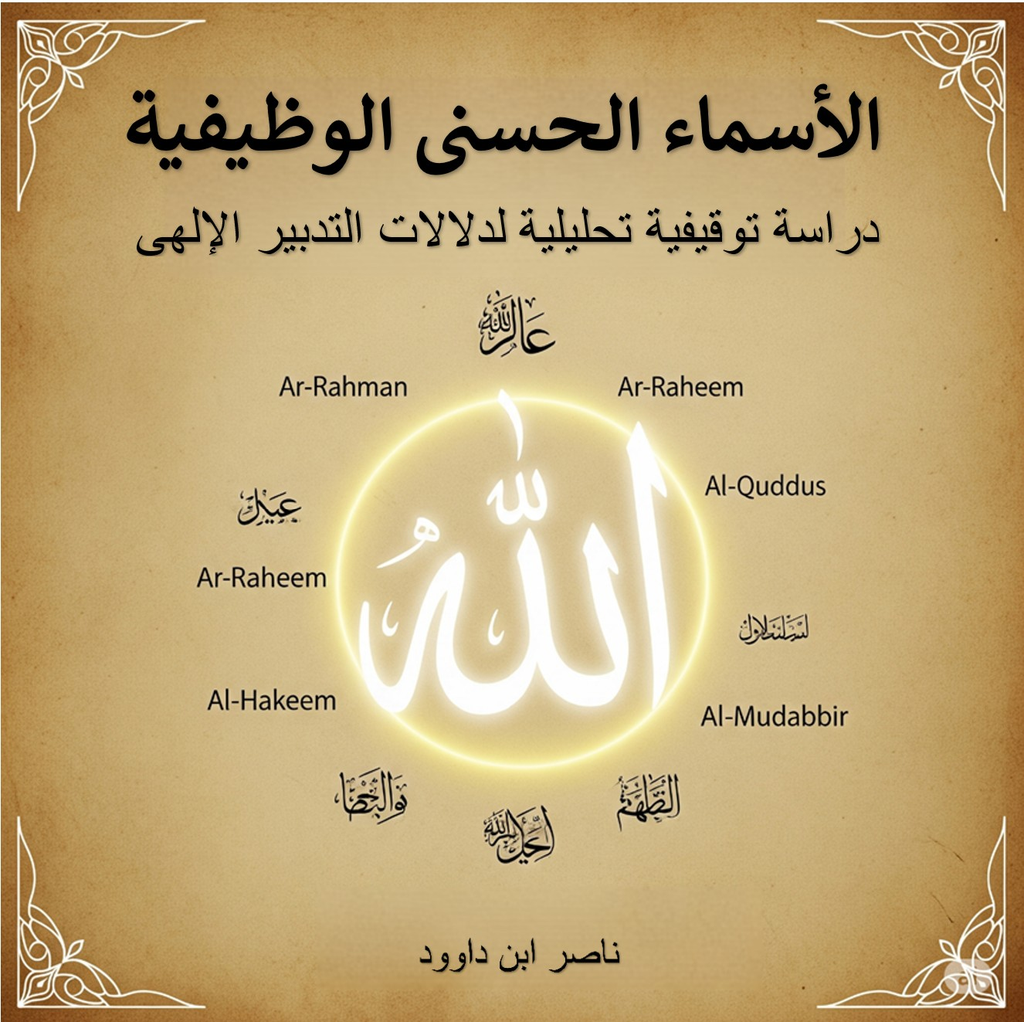

# مقدمة الكتاب : "الأسماء الحسنى الوظيفية في القرآن الكريم- دراسة توقيفية تحليلية لدلالات التدبير الإلهي"

بسم الله الرحمن الرحيم

الحمد لله الواحد الأحد، الفرد الصمد، الذي تنزهت ذاته عن كل نقص، وتعالت صفاته عن كل حد، وجلت أسماؤه عن كل شبيه، القائل في كتابه المبين: ﴿وَلِلَّهِ الْأَسْمَاءُ الْحُسْنَىٰ فَادْعُوهُ بِهَا﴾ [الأعراف: ١٨٠]. والصلاة والسلام على خير خلق الله، نبينا محمد صلى الله عليه وسلم، الذي أوصانا بمعرفة ربنا، فقال: "إن لله تسعة وتسعين اسمًا، من أحصاها دخل الجنة".

وبعد،

إن معرفة الله سبحانه وتعالى بأسمائه وصفاته هي باب واسع لفهم سنن الكون، ووسيلة للتأمل في سر التدبير الإلهي في الخلق والتشريع. فالإيمان الحق لا يقتصر على التصديق المجرد، بل هو معرفة تعمّق الفؤاد وتضيء العقل، كما قال سبحانه: ﴿فَاعْلَمْ أَنَّهُ لَا إِلَٰهَ إِلَّا اللَّهُ﴾ [محمد: ١٩]، فالعلم بالله هو الركيزة الأولى لكل علم، والأساس الذي تبنى عليه العقيدة الصحيحة.

الغرض من تأليف الكتاب:

لقد دفعني لتأليف هذا الكتاب مقصد أسمى، وهو تبيان شيء مما يتعلق بجملة الأسماء الحسنى، معتمداً على ما يسره الله لي من الوسع والتيسير، وطبقاً لما انتهى إليه عملي القاصر والقصير. إنما أعتمد على الله سبحانه وتعالى في تحقيق هذا المقصد وتكميله، وإليه أستند في نفعه وتحصيله، ومنه أسأل أن يجعله نوراً ساطعاً وروضاً يانعاً، يكون رحمة لعباده، وبركة في أرضه وبلاده، وهو حسبي ونعم الوكيل.

إن هذا الكتاب يسعى إلى تقديم فهم متجدد لدلالات أسماء الله الحسنى، ليس فقط من زاوية العقيدة التقليدية، ولكن من خلال استنباط المعاني من الواقع المشهود، حيث تتجلى آثار أسماء الله وصفاته في كل ما يحيط بنا. فنحن نرى كيف جعل الله سبحانه من أسمائه ما للجمال، وما للجلال، وما للكمال بالقدرة، وما للتجلي والتحلي والتملي، فيتأتى لذوي الخبرة أن ينالوا منها ما هو لطلب المناصب العالية، ومنها ما هو لتعمير القلوب الخالية، ومنها ما من أسراره فك الكروب، ومنها ما هو لجمع المحب مع المحبوب، ومنها ما هو لتكميل الناقص من الناس، ومنها ما هو للطهارة من سائر الأدناس. فسبحان من أودع سره في كلماته، وجعل فضائل بره في بديع آياته.

وتيسيراً لنشر هذا العلم ونفعه، فإن هذا الكتاب مُرخَّص للنشر والتوزيع المجاني، مع وجوب ذكر المؤلف: ناصر ابن داوود

مقدمة منهجية:

لابد قبل الخوض في الغرض المقصود من هذا الكتاب، من تقديم مقدمة منهجية تكون توطئة وتكميلاً، يرجع إليها القارئ تعريفاً وتأصيلاً. ويحضرني من ذلك مسائل أساسية:

المسألة الأولى: مناحي دراسة الأسماء الحسنى:

إن الكلام في الأسماء الحسنى قد دار على خمسة أنحاء رئيسة وهي جملة ما يحتاج إليه في مبانيها اللفظية، ومناحيها المعنوية، ومقتضياتها الوجودية، ووجوهها العرفانية، وخواصها الوجدانية. ولقد سلك كل فريق من العلماء طريقاً في تناولها. وهذا الكتاب، وإن كان يستفيد من هذه المناحي، فإنه يركز بشكل خاص على الدلالات "الوظيفية" للأسماء الحسنى وكيفية تجلياتها في "التدبير الإلهي" للكون والحياة، مستخلصاً ذلك مباشرة من النص القرآني.

المسألة الثانية: التوقيفية في الأسماء الحسنى:

إن الأسماء الحسنى توقيفية، فلا تثبت إلا بنص أو إجماع على الصحيح. وهذا هو المنهج الذي نتبناه في هذا الكتاب بما أسميناه "التوقيفية المطلقة"، التي تعتمد على النص القرآني المجيد كمرجع وحيد وأساسي لاستخلاص الأسماء الحسنى ودلالاتها الوظيفية. وعلى الرغم من أن بعض العلماء قد أثبت أسماء بالاشتقاق من الأفعال والصفات وما جاء من الصيغ في الدعوات وغيرها، إلا أن هذا الرأي يبقى مرجوحاً عند المحققين من العلماء، وملحوظاً عند بعض المتصوفة. لقد عمد بعضهم، مثل الشيخ أبي العباس البوني، إلى تقسيمها حتى انتهى بها إلى مائة ونيف وخمسين اسماً، والله تعالى أعلم. لكن منهجنا ينأى عن ذلك، ويحصر البحث في الأسماء التي وردت نصاً في كتاب الله.

المسألة الثالثة: الأسماء عين المسمى:

لقد أثير جدل حول مسألة "الأسماء عين المسمى" أو "غيره". وقد أبى قوم ذلك، وفصّل آخرون، وتوقف آخرون امتناعاً عن الخوض. ولكن السلف الصالح لم يتكلموا في الاسم ولا في المسمى، ولا في الصفة والموصوف، ولا في التلاوة والمتلو؛ طلباً للسلامة، وحذراً على الغير، وهذا منتهى الورع. وهذا الكتاب يتجنب الخوض في هذه المسائل الكلامية الدقيقة، ويركز على الدلالات الوظيفية والتطبيقية للأسماء.

المسألة الرابعة: أقسام الأسماء الحسنى:

تُقسم الأسماء الحسنى إلى أربعة أقسام رئيسة:

1. أسماء الذات: وهي التي يقال فيها "هي هو"، وتعبر عن ذات الله المطلقة.
2. أسماء الصفات: وهي التي لا يقال فيها "هي هو" ولا "هي غيره"، وتعبر عن صفات الله التي لا تنفك عن ذاته.
3. أسماء التنـزيه: وهي مبنية على التقديس المطلق لذات الله تعالى عن كل نقص، مثل اسم "القدوس".
4. أسماء الأفعال: قال إمام الحرمين: "وهي كل ما دلت التسمية به على فعل في الخلق والرزق". وقد نظر في ذلك بعض المشايخ بأن المغايرة تكون فيما منه الاشتقاق لا في الاسم، وهو الصحيح. وسيكون التركيز في هذا الكتاب على كيفية تجلي هذه الأقسام، وبخاصة أسماء الأفعال، في تدبير الله لشؤون خلقه.

المسألة الخامسة: إحصاء الأسماء ودخول الجنة:

لقد صح الحديث الشريف: "إن لله تبارك وتعالى تسع وتسعين اسماً من أحصاها دخل الجنة". وهذا الحديث يحصر الثواب لمن أحصى هذه التسعة والتسعين اسماً، ولكنه لم يحصر الأسماء في هذا العدد. فمن الجائز أن تكون هناك أسماء أخرى لم يرد علمنا بها، أو علمناها ولكن ليس لها هذا الثواب الخاص. وقد ذكر بعض العلماء أن هذه التسعة والتسعين قد وُضعت خصيصاً للتعبد والسلوك بها بخلاف غيرها، ونبه عليه القاضي أبو بكر العربي في "المد الأقصى". وهذا يؤكد على أن المنهج التوقيفي الذي نتبعه هو المنهج الأسلم في التعامل مع الأسماء.

المسألة السادسة: عد الأسماء في الروايات:

لقد ورد عد هذه التسعة والتسعين في الترمذي وغيره من كتب الحديث، لكن باختلاف وتقديم وتأخير. ولقد رجح الحافظ ابن حجر أن سردها إنما هو من فعل الرّاوي وليس من كلام النبي صلى الله عليه وسلم. وقد سامح قوم في حملها على الرفع، وقالوا: يقبل فيها خبر الواحد؛ لأنها عبادة وعمل. وهذا ما يزيد من قوة منهجنا في الاعتماد على النص القرآني الثابت لتجنب الخلافات حول صحة الأحاديث وسرد الأسماء.

المسألة السابعة: مفهوم الاشتقاق في الأسماء:

حيث ذكر الاشتقاق في الأسماء، فالمراد به أن المعنى المذكور ملحوظ في الاسم المذكور. وإلا فإن الشرط الحقيقي للمشتق أن يكون مسبوقاً بالمشتق منه، وأسماء الله تعالى قديمة لأنها من كلامه، وهي ليست حادثة حتى تشتق. وقد أنكر قوم إطلاق لفظ "الاشتقاق" للإيهام، وقالوا: إنما يقال بمثل اسمه "السلام": فيه معنى من السلامة، وفي مثل اسمه "الرحمن": فيه معنى من الرحمة. بل قالوا: إن الأشياء هي المشتقة من الأسماء لحديث: "هي الرحم وأنا الرحمن اشتققت لها اسماً من اسمي"، ولما أنشده حسان رضي الله عنه للنبي صلى الله عليه وسلم حيث قال:

واشتق له من اسمه لِيُجِلَّهُ

فذو العرش محمود وهذا محمد

وهذا يؤكد أن الأسماء هي الأصل والمعاني منها تستقى، لا العكس.

المسألة الثامنة: الإحصاء ومراتبه:

الإحصاء المذكور في الحديث الشريف يأتي على خمسة أوجه رئيسة: الحفظ، والذكر، والعلم، والتعلق، والتخلق. وكل هذه الأوجه أقوال متكاملة. ثم إن الذكر إما أن يكون للتعبد، أو للتوسل، أو لطلب الخاصية. ولكل من هذه الوجوه شروطه ومادته. وتتنوع هذه الأوجه إلى خمسة أنواع تقضي بموادها ووجوهها:

1. النكتة: وهي التي تنصبغ بها الحقيقة فيخرق الظاهر والباطن بلا تعمد (وهي للعارفين).
2. النقطة: وهي التي يثلج لها القلب فينفسح في عوالمه فيقع التصرف على وفقه (وهي للواجدين).
3. الهيئة: وهي التي تشغل الظاهر بمبانيها، وتوجه الباطن لمعانيها فيقع التأثير على إثره (وهي للمريدين).
4. الرسم: وهو الذي يعمر الوقت ويحصل التعبد (وهو للمبتدئين).
5. العادة: وهي التي لا تفيد ولا تجدي، وهو الذي يجري على ألسنة العوام من غير قصد، أو بقصد غير جازم، أو بجازم لا يستشعر معه الذكر ولا المعنى ولا المذكور (وهذا لا عبرة به إذ ليس بذكر حقيقة). وسيكون هذا الكتاب عوناً للقارئ على الارتقاء بفهمه للأسماء من مجرد العادة إلى مراتب العلم والتعلق والتخلق.

أهمية أسماء الله الحسنى:

أسماء الله الحسنى أو أسماء الله العظمى هي أسماء لله تفيد مدحه وحمده وثناءه وتمجيده وتعظيمه وصفات كماله ونعوت جلاله، وأفعال حكمة ورحمة ومصلحة وعدل من الله. يُدعى الله بها، وتقتضي المدح والثناء بنفسها. وقد سمى الله بها نفسه في كتبه، أو على لسان أحد من رسله، أو استأثر الله بها في علم الغيب عنده، لا يشبهه ولا يماثله فيها أحد. وهي "حسنى" يراد منها قصر كمال الحسن في أسماء الله، ولا يعلمها كاملة وافية إلا الله.

وهي أصل من أصول التوحيد في العقيدة الإسلامية، لذلك فهي روح الإيمان وأصله وغايته. فكلما ازداد العبد معرفة بأسماء الله وصفاته، ازداد إيمانه وقوي يقينه. والعلم بالله، وأسمائه، وصفاته أشرف العلوم عند المسلمين، وأجلها على الإطلاق؛ لأن شرف العلم بشرف المعلوم، والمعلوم في هذا العلم هو الله سبحانه وتعالى.

لقد امتدح الله بها نفسه في القرآن الكريم فقال: ﴿اللَّهُ لَا إِلَهَ إِلَّا هُوَ لَهُ الْأَسْمَاءُ الْحُسْنَى ٨﴾ [سورة طه، الآية 8]. وحث عليها الرسول محمد صلى الله عليه وسلم فقال: "إن لله تسعة وتسعين اسمًا، مائة إلا واحدًا، من أحصاها دخل الجنة".

يهدف هذا الكتاب إلى التعمق في فهم هذه الأسماء من منظور "الوظيفية"، أي تتبع دلالاتها العملية والتطبيقية في سياقاتها القرآنية، وكيف تتجلى من خلالها سنن الله في تدبير الكون وشؤون الخلق، وكيف يمكن استحضار هذه الأسماء وتفعيلها في الدعاء، والتوكل، وحل المشكلات، والتعامل مع تحديات الحياة، لتعزيز اليقين، وإزالة القلق، وتحقيق السعادة والطمأنينة. ويسعى الكتاب للإجابة على سؤال جوهري: "كيف نطبق فهمنا للأسماء في حياتنا اليومية؟".

يُختتم الكتاب بالتأكيد على أن فهم الأسماء الحسنى ودلالاتها، والوصول إلى أسرارها النورانية، يحتاج إلى مزيد من التأمل والتدبر والتطبيق العملي، جاعلاً من هذا الكتاب دليلاً للمسلم المعاصر لتعميق علاقته بربه من خلال أسمائه الحسنى.

ناصر ابن داوود

مهندس وباحث إسلامي

# شكر خاص وتقدير

أحمد الله تعالى أولاً وآخراً، وأشكره على توفيقه وإعانته في إنجاز هذا العمل المتواضع، الذي أسأل الله أن يجعله خالصاً لوجهه الكريم، نافعاً للمسلمين.

وأخص بالشكر والتقدير لكل من كان له أثرٌ بالغٌ في تشكيل الرؤية وتعميق الفهم لهذا الموضوع الجليل، سواء بتأصيل علمي، أو بإضاءة فكرية، أو بتوجيه منهجي:

- **العلامة الشيخ أحمد زرّوق (رحمه الله):** لقد كان لكلماته ورؤاه العميقة في كتابه "شرح أسماء الله الحسنى" أثراً عظيماً في ترسيخ فهمي للأسماء الحسنى كمدارك جمال وجلال وكمال، وفي استلهام البعد الوظيفي والتطبيقي لها في تعمير القلوب وفك الكروب، وكيف أنها ليست مجرد ألفاظ بل أسرار أودعها الله في كلماته. لقد كانت أقواله نبراساً يهتدي به السالك في هذا الدرب.
- **فضيلة الإمام الشيخ محمد متولي الشعراوي (رحمه الله):** أتقدم له بخالص الشكر والامتنان. لقد كان لكتابه القيم "أسماء الله الحسنى" مرجعاً أساسياً لي في استلهام معاني الأسماء الحسنى وتعميق دلالاتها، وقد استفدتُ منه استفادة عظيمة في فهم الجوانب العقدية والتربوية لهذه الأسماء المباركة، وأسلوبه الميسر وعمقه التفسيري كانا مصدراً للإلهام في عرض المعاني.
- **السيد الفاضل أمين صبري:** جزاه الله عنا خير الجزاء، فقد كان لفيديوهاته أثرٌ كبيرٌ في توجيهي نحو فهم الأسماء الحسنى الوظيفية، وفي استيعاب تصنيفات المجموعات، وترتيب الأسماء، وتحديد الأسماء القرآنية الأصيلة منها. لقد أضاءت هذه الفيديوهات لي دروباً جديدة في التدبر والتحليل، وكان لها فضلٌ عظيمٌ في بلورة المنهجية التي اتبعها هذا الكتاب.
- **السيد أنس الكمشكي:** أتقدم له بخالص الشكر والتقدير لمساهمته القيمة في إثراء المحتوى الذي تناول كيفية "استعمال الأنبياء للأسماء الحسنى"، والذي قدم رؤى عملية وعميقة حول تفعيل هذه الأسماء في المواقف الحياتية المختلفة، مما ألهم جانبًا كبيرًا من هذا الكتاب في ربط الفهم النظري بالجانب التطبيقي الحي في حياة الأنبياء والمؤمنين.
- **فضيلة الدكتور محمد راتب النابلسي:** أتقدم له بخالص الشكر والامتنان. لقد كان لكتابه "أسماء الله الحسنى" مرجعاً أساسياً لي في استلهام معاني الأسماء الحسنى وتعميق دلالاتها، وقد استفدتُ منه استفادة عظيمة في فهم الجوانب العقدية والتربوية لهذه الأسماء المباركة.
- **فضيلة الدكتور أحمد كريمة أستاذ الفقه المقارن بجامعة الأزهر الشريف:** أقدم له خالص التقدير، فقد كانت لتصريحاته وآرائه حول عدد الأسماء الحسنى ومصادرها، وتأكيده على أن الحصر في تسعة وتسعين لا يعني نفي وجود أسماء أخرى، تأثيراً في تعزيز المنهج التوقيفي الذي سلكته في هذا البحث، ودعماً للرؤية القائمة على البحث في الأسماء من القرآن الكريم مباشرة.

وأسأل الله أن يتقبل من الجميع صالح الأعمال، وأن يجعل هذا الجهد في موازين حسناتهم.

© 2025 ناصر ابن داوود. جميع الحقوق محفوظة.

مُرخَّص للنشر والاقتباس والتوزيع المجاني بشرط ذكر المؤلف: ناصر ابن داوود.

**حول هذه النسخة (الطبعة الثانية):**

يسعدني أن أقدم للقارئ الكريم هذه الطبعة الثانية من كتاب "الأسماء الحسنى الوظيفية في القرآن الكريم". لقد جاءت هذه النسخة ثمرة لمزيد من التأمل والبحث، واستجابة لملاحظات بناءة، حيث تم تحديثها وتوسيعها لتشمل معالجة الأخطاء الشائعة في فهم الأسماء الحسنى، وتفصيل الجانب العملي لتفعيلها في حياة المؤمن اليومية من خلال الدعاء والذكر والسلوك، بالإضافة إلى استعراض نماذج نبوية في تفعيل هذه الأسماء. أسأل الله تعالى أن يزيد هذا الجهد نفعاً، وأن يجعله أكثر إسهاماً في تعميق العلاقة بالله سبحانه وتعالى.

# الفهرس

مقدمة الكتاب : "الأسماء الحسنى الوظيفية في القرآن الكريم- دراسة توقيفية تحليلية لدلالات التدبير الإلهي" 2

شكر خاص وتقدير 6

الفهرس 8

1 الجزء الأول: المفهوم والأسس 12

1.1 الأسماء الحسنى في المنظور التقليدي – استعراض وتحليل 16

1.2 الأسماء "الخاطئة والمزورة" – تحليل وتفنيد 18

1.3 التحديات المعاصرة في فهم الأسماء الحسنى: أخطاء شائعة ومنهج التصحيح 20

1.4 الأسماء الحسنى "الأصلية" في القرآن الكريم – قائمة وتصنيف 22

1.5 مقارنة بين الفهم التقليدي والفهم الوظيفي لأسماء الله الحسنى 25

1.6 ملخص الفهم الشائع لمعاني الأسماء الله الحسنى 26

1.7 ملخص معاني وثمرات وأبعاد أسماء الله الحسنى الوظيفية 30

1.8 تصنيف الأسماء الأصلية في مجموعات دلالية: 35

1.9 الجسر إلى الأسماء الوظيفية – الأساس لعملية التفعيل 35

1.10 الأسماء الحسنى الأصلية (الجامع) وخاتمة الجزء الاول 37

2 الجزء الثاني: الأسماء الحسنى الوظيفية: فئات، مجموعات، واقتراناتها 44

2.1 مقدمة في الأسماء الحسنى الوظيفية وأهمية اقتراناتها في فهم التدبير الإلهي 44

2.2 منهجية الاستخراج والتصنيف الوظيفي للأسماء الحسنى في القرآن الكريم 45

2.3 الأسماء الحسنى الوظيفية – التطبيق والتفعيل 46

2.4 الفئات الوظيفية الكبرى للأسماء الحسنى 47

2.5 المجموعات الوظيفية التفصيلية والاقترانات 51

2.5.1 مجموعة الأسماء المرتبطة بـ "كل شيء" و"بكل شيء": إحاطة علم الله وقدرته 51

2.5.2 وظائف ودلالات اقترانات اسم "العليم": العلم الذي يبني ويُدبّر وسعة الإحاطة 52

2.5.3 مجموعة اسم "الغني": كمال الاستغناء المطلق وتجلياته الوظيفية 55

2.5.4 مجموعة اسم "العزيز": القوة، المنعة، الهيمنة، والعزة المقترنة بالمغفرة والرحمة والعطاء 57

2.5.5 مجموعة اسم "الغفور": سعة المغفرة وعظيم التجاوز 60

2.5.6 مجموعة اسم "الرحيم": بناء الروابط وسعة الفضل 61

2.5.7 مجموعة اسم "الحكيم" والأسماء الفردية: كمال التدبير والتفرد المطلق 62

2.5.8 الأسماء الفردية الدالة على التفرد المطلق: (مثل الأحد، الصمد، الواحد) تُشير إلى كمال الله في ذاته وتفرده المطلق، وأنه مقصد كل المخلوقات في حوائجها. 63

2.5.9 الأسماء الفائقة وخواص الاقترانات: مفاتيح التدبير الكوني والتعامل الإلهي 64

2.6 تطبيقات عملية في فهم الأسماء الحسنى الوظيفية: أمثلة مختارة 66

2.6.1 تطبيقات الأسماء الحسنى في عبادة التوكل: خمسة مفاتيح 66

2.6.2 تفعيل الأسماء الحسنى في حياة المؤمن: دعاء، ذكر، وسلوك 68

2.7 خاتمة الجزء الثاني: إدراك عظمة الله وكمال تدبيره 70

3 الجزء الثالث: معاني وثمرات وابعاد أسماء الله الحسنى 71

1.1 اسم الله الرحمن الرحيم: 71

1.2 اسم الله "الرحمن": تجلي النظام والقانون في عالم الخلق 73

1.3 اسم الله الأعظم: "الله" 74

3.1 اسم الله "الملك" (السيّد/المالك) 77

3.2 اسم الله القدوس 78

3.3 اسم الله: السلام 80

3.4 اسم الله "المؤمن" 83

3.5 اسم الله "المهيمن" 84

3.6 اسم الله "العزيز" 86

3.7 اسم الله "الجبار" 88

3.8 اسم الله "المتكبر" 89

3.9 اسم الله "الغفار" 90

3.10 اسم الله "القهار" 91

3.11 اسم الله الوهاب 93

3.12 اسم الله الرزاق 94

3.13 اسم الله الفتاح 96

3.14 اسم الله "العليم" 97

3.15 اسم الله القابض الباسط 99

3.16 اسم الله المعز والمذل 101

3.17 اسم الله الخالق 102

3.18 اسم الله البارئ والمصور 104

3.19 اسم الله الحليم 106

3.20 اسم الله الشكور 108

3.21 اسم الله الكريم 109

3.22 اسم الله الحكيم 112

3.23 اسم الله الودود 114

3.24 اسم الله التواب 115

3.25 اسم الله الهادي 116

3.26 اسم الله الكبير 118

3.27 اسم الله "البديع" 119

3.28 اسم الله "الصبور" 121

3.29 اسم الله الأعظم: "الله" 123

3.30 اسم الله "النور" 126

3.31 اسم الله الحفيظ 128

3.32 اسم الله الولي 130

3.33 اسم الله "الخبير" 132

3.34 اسم الله "مالك الملك" 133

3.35 اسم الله "ذو الجلال والإكرام": 135

3.36 اسم الله "الرقيب" 137

3.37 اسم الله الحسيب 138

3.38 اسم الله المقيت 140

3.39 اسم الله الجليل 141

3.40 اسم الله المجيب 143

3.41 اسم الله الوكيل 145

3.42 اسم الله الواسع: سعة مطلقة لا حدود لها 146

**3.1** **اسم الله الحي** 148

3.43 اسم الله القيوم 150

3.44 اسم الله الأول والآخر 151

3.45 اسم الله السميع 153

3.46 اسم الله البصير 154

3.47 اسم الله الرؤوف 155

3.48 اسم الله الغفور 157

3.49 اسم الله العلي 158

3.50 اسم الله الصمد 159

3.51 اسم الله الحكم 161

3.52 اسم الله الشهيد 162

3.53 اسم الله الغني: الاستغناء المطلق 163

3.54 اسم الله "العفو": مغفرة تمحو الذنوب وتُبدل السيئات حسنات 164

3.55 معاني اسم الله "الجامع" 166

3.56 اسم الله "الحميد" 167

3.57 اسم الله "البرّ" 168

3.58 اسمي الله "القادر" و"المقتدر" 170

3.59 المحيي المميت 171

3.60 اسم الله المقسط 173

3.61 اسم الله "الوالي" 174

3.62 اسم الله الوارث 176

3.63 اسم الله "القوي 177

3.64 اسم الله المتين: 179

3.65 اسم الله "الرب" 181

3.66 اسم الله الاكرم 183

3.67 "اسم الله عالم الغيب والشهادة" 184

3.68 اسم الله "المبين" 186

4 الجزء الرابع: خلاصة وتطبيقات عملية (الخاتمة النهائية للسلسلة) 188

4.1 أسماء الله الحسنى: رحلة إيمانية عبر قصص الأنبياء 188

4.2 الخاتمة: من معرفة الأسماء إلى العيش بها.. بداية رحلة لا تنتهي 190

5 ملخص الكتاب 192

6 المراجع 193

# الجزء الأول: المفهوم والأسس

1. **تمهيد ومنهجية – لماذا هذه السلسلة؟**

تُمثل أسماء الله الحسنى جوهر المعرفة بالله، ومفتاح فهم تدبيره الكوني، وأساس التعامل الإلهي مع الوجود والبشر. إن هذه الموسوعة، المعنونة بـ "الأسماء الحسنى الوظيفية في القرآن الكريم: دراسة توقيفية تحليلية لدلالات التدبير الإلهي"، تسعى إلى تقديم مقاربة فريدة تُركز على الجانب الوظيفي والتحليلي لهذه الأسماء، مُستندة إلى منهج توقيفي صارم في استخلاصها ودلالاتها. يهدف هذا التمهيد إلى إرساء عدد من المفاهيم المحورية التي ستُشكل إطاراً لفهم المنهجية التي اتبعناها ومضمون هذه الدراسة، والتي نأمل أن تُسهم في تعميق معرفة القارئ بالله سبحانه وتعالى.

**مقدمة: معرفة الله بالأسماء الحسنى هي الغاية والمنهج**

إن معرفة الله سبحانه وتعالى هي الغاية الأسمى لوجود الإنسان، وهي النور الذي يُضيء دروب الحياة ويمنحها المعنى والهدف. وفي قلب هذه المعرفة يكمن فهمنا لأسمائه الحسنى، التي ليست مجرد كلمات تُحفظ أو ألقاب تُعدّ، بل هي مفاتيحٌ عظيمةٌ لمدارك لا حصر لها، تُفتح على عبايةِ الجلال الإلهي، وسعةِ رحمته، وكمالِ حكمته، وبديعِ تدبيره في الكون وفي حياة البشر.

لقد توارثت الأمة الإسلامية عبر قرون طويلة اهتمامًا بالغًا بأسماء الله الحسنى، تلاوةً وحفظًا وتدبرًا، إيمانًا بفضلها العظيم المذكور في قوله تعالى: ﴿وَلِلَّهِ الْأَسْمَاءُ الْحُسْنَى فَادْعُوهُ بِهَا﴾ [الأعراف: 180]، وقوله صلى الله عليه وسلم: 'إن لله تسعة وتسعين اسماً، مائة إلا واحدًا، من أحصاها دخل الجنة' (رواه البخاري ومسلم). وقد أثمر هذا الاهتمام مكتبات زاخرة بالشروح والتأويلات والتصنيفات عكست جهدًا معرفيًا روحيًا هائلًا.

**أصل التسمية وأهمية الاسم في المنظور القرآني: ليست مجرد ألقاب**

لقد أشار القرآن الكريم إلى جوهرية "الاسم" في عملية المعرفة والتكوين منذ فجر الخليقة. ففي قوله تعالى: ﴿وَعَلَّمَ آدَمَ الْأَسْمَاءَ كُلَّهَا ثُمَّ عَرَضَهُمْ عَلَى الْمَلَائِكَةِ فَقَالَ أَنبِئُونِي بِأَسْمَاءِ هَٰؤُلَاءِ إِن كُنتُمْ صَادِقِينَ﴾ [البقرة: 31]، نجد إشارة لطيفة إلى أن الأسماء التي علمها الله لأبينا آدم لم تكن مجرد ألفاظ، بل هي جوهر المعرفة بالمسميات وحقائقها، ومفتاح الوعي والتمييز. فإذا كانت الأسماء هي أساس البيان والتعبير عن الحقائق، فإن أسماء الله الحسنى هي المرجعية العليا لفهم المعاني الكونية والصفات العليا، باعتبارها تجليات لتلك الأسماء والصفات في عالم الوجود والبيان. هذه الأسماء الحسنى كمرجعية للمعاني الجوهرية تُشكل أساس فهمنا للحياة والكون.

تؤكد المصادر الشرعية أن أسماء الله الحسنى ليست مجرد ألقاب تُعرف بها الذات الإلهية فحسب، بل هي صفات كمال، وأفعالٌ عظيمةٌ تُعبّر عن كمال الله وتنزيهه، وتُعرّف به إلينا، وتُعرّف به علينا. هذه الأسماء تعكس صفات الله الكاملة وأفعاله العظيمة، وهي الأساس الذي تُبنى عليه العلاقة بين الخالق والمخلوق.

على سبيل المثال، اسم "الوارث" لا يعني مجرد لقب يُطلق على الله، بل هو دالٌ على صفة البقاء المطلق وفعله تعالى في أنه الباقي بعد فناء خلقه، ويرث السماوات والأرض ومن عليها. كذلك، في آية الكرسي، يرد اسمان عظيمان وهما "الحي القيوم". "الحي" تدل على الحياة الكاملة له سبحانه، و"القيوم" تدل على أنه قائم بذاته ومقيم لغيره، لا يحتاج إلى شيء، وكل شيء محتاج إليه؛ وهذه بوضوح صفات ذاتية وأفعال تدبيرية وليست مجرد ألقاب تعريفية. وينطبق هذا على أسماء مثل "الخالق" الذي يخلق، و"الرازق" الذي يرزق، و"المحيي" الذي يحيي، و"المميت" الذي يميت. هذه الأسماء تصف أفعالًا إلهية محددة تتعلق بخلقه ورزقه وإحيائه وإماتته، وتؤكد المصادر أنه ليس خالق ولا رازق ولا محيي ولا مميت إلا الله. هذا الربط الوثيق بين الاسم والفعل والصفة يُبرز الجانب الوظيفي والحيوي لأسماء الله الحسنى. حتى اسم "النور"، هو صفة لله تعني أنه نور السماوات والأرض، يهدي إلى نوره من يشاء.

خلاصة القول أن أسماء الله الحسنى هي التي سمّى بها الله نفسه، أو أنزلها في كتابه، أو أخبر بها نبيه. هذه الأسماء تصف ذاته وأفعاله بما يليق بكماله وعظمته، وهي دالة على صفاته الكاملة. الدعاء والعبادة يتعلقان بصفات المدعو والمعبود وأفعاله، مما يؤكد أن الأسماء تحمل معاني صفات وأفعال إلهية وليست مجرد علامات تعريفية (ألقاب). إن هذا الفهم هو ما يُشكل الأساس لهذه السلسلة، ويوجهنا نحو تدبر الأسماء الحسنى من منظورها الوظيفي الذي يُمكن من تفعيلها في حياتنا اليومية.

**الهدف من هذه السلسلة ومنهجيتها:**

تأتي هذه السلسلة لتقدم طرحًا منهجيًا جديدًا في فهم الأسماء الحسنى، ينطلق من أساس راسخ: القرآن الكريم وحده كمرجع أصيل وكافٍ. إننا نسعى من خلال هذه المقالات إلى الغوص في كتاب الله لاستخلاص أسمائه الحسنى، ليس فقط بمعانيها اللغوية، بل بوظائفها وتجلياتها العملية في سياقاتها القرآنية، خاصة تلك التي ترد مقترنة بأسماء أخرى لِتُشكّل "مفاتيح" لفهم أعمق لدور الألوهية في تدبير الكون وحياة الإنسان.

إن ما يميز هذا الطرح هو التركيز على "الأسماء الحسنى الوظيفية"، وهي تلك الأسماء التي لا تصف الله فحسب، بل تُظهر وظيفةً معينةً له سبحانه في سياق آيةٍ أو مجموعة آيات محددة. هذه الوظائف، عندما تُفهم ضمن اقتراناتها القرآنية، تفتح آفاقًا جديدة لاستيعاب كيفية عمل هذه الأسماء معًا في خدمة حكمة الله وتدبيره الشامل، وكيف يمكن للإنسان أن يتفاعل معها أو يستعين بها في حياته، في الدعاء والتزكية والتعامل مع تحديات الحياة.

مفهوم 'الإحصاء' ودلالته الوظيفية:

يُوضح الحديث الشريف: 'إن لله تسعة وتسعين اسماً، مائة إلا واحدًا، من أحصاها دخل الجنة' (رواه البخاري ومسلم)، أن الإحصاء ليس مجرد العد أو الحفظ الظاهري، بل هو معنى أعمق وأشمل. فكما جاء في قوله تعالى: ﴿وَلَقَدْ أَحْصَاهُمْ وَعَدَّهُمْ عَدًّا﴾ [مريم: 94]، فإن الإحصاء يختلف عن مجرد العد.

مراتب الإحصاء ودلالاتها الوظيفية:

- الاستيفاء والشمول: أن يدعو العبد الله بكل أسمائه، ويُثني عليه بجميعها، لا يقتصر على بعضها.
- فهم المعاني والعمل بمقتضاها: أن يعقل معاني هذه الأسماء ويُلزم نفسه بواجباتها. فمثلاً، عند استحضار اسم 'الحكيم'، يجب التسليم لله في جميع أوامره وأفعاله؛ وعند 'القدوس'، استحضار كونه منزهاً عن كل ما لا يليق بجلاله. وهذا يُشكل طريقاً للعمل بمقتضى هذه الأسماء.
- التفصيل والمعرفة اليقينية: أن يعرفها على وجه التفصيل، فالعارف بها لا يكون إلا مؤمناً، والمؤمن يدخل الجنة.
- التعظيم والإخلاص: أن يُحصيها العبد إرادةً لوجه الله وإعظامه، وأن ينعكس ذلك على العمل الظاهر والباطن.
- التخلق والاعتراف: ما يختص بالله تعالى، كـ 'الجبار' و'العظيم'، يجب على العبد الإقرار بها والخضوع لها، وعدم التحلي بصفة منها. وما كان فيه معنى الوعد، يتوجه العبد منه بالطمع والرغبة، وما كان فيه الوعيد، يتوجه منه بالخشية والرهبة.

إن الإحصاء الحقيقي لا يُحقق ثمرته ما لم يُقرن بالعمل؛ فالحفظ وحده دون تدبر أو تطبيق يُشبه حفظ القرآن دون العمل بمضمونه. لذا، فإن دعوة الله بأسمائه الحسنى، كما أُمرنا في القرآن، ينبغي أن تتناسب مع مضمون الاسم، فـ 'يا رحيم ارحمني، يا حكيم احكم لي، يا رزاق ارزقني، يا هادي اهدني'.

القرآن الكريم: خريطة ثلاثية الأبعاد للفهم والتدبر:

لتبسيط فهم القرآن وتطبيقاته في الحياة، تتبنى هذه السلسلة منهجًا يستلهم فكرة "الخريطة ثلاثية الأبعاد" التي تربط بين عناصر أساسية في النص القرآني، والتي تتفاعل فيما بينها لتشكل فهمًا شاملاً ودليلاً عمليًا للمؤمن:

- المعادلات القرآنية "قوانين الحياة": هي العلاقات الثابتة بين الأفعال والنتائج، بين المقدمات والخواتيم، بين الأسباب والمسببات. إنها "قوانين إلهية" محكمة تحكم الكون والحياة والإنسان، ليست مجرد معادلات رياضية، بل هي معادلات وجودية، قيمية، أخلاقية، واجتماعية.
  - أمثلة: ﴿مَنْ عَمِلَ صَالِحًا مِّن ذَكَرٍ أَوْ أُنثَىٰ وَهُوَ مُؤْمِنٌ فَلَنُحْيِيَنَّهُ حَيَاةً طَيِّبَةً﴾ [النحل: 97]، ﴿ادْعُونِي أَسْتَجِبْ لَكُمْ﴾ [غافر: 60]، ﴿لَئِن شَكَرْتُمْ لَأَزِيدَنَّكُمْ﴾ [إبراهيم: 7].
- الفئات القرآنية "أنواع الناس": هي التصنيفات التي يذكرها القرآن للناس، بناءً على إيمانهم وأعمالهم وسلوكياتهم. ليست مجرد تصنيفات اجتماعية، بل هي تصنيفات قيمية وأخلاقية وروحية تعين الإنسان على معرفة موقعه وتحديد أهدافه.
  - أمثلة: المؤمنون، الكافرون، المنافقون، المتقون، الفاسقون، الظالمون، المحسنون، المفسدون، الصابرون، الشاكرون.
- الأسماء الحسنى الوظيفية "صفات الله في الفعل": هي أسماء الله الحسنى التي تظهر في سياقات قرآنية، وغالبًا ما تختم الآيات لتُبرز المعنى وتُحدد دلالته. إنها ليست مجرد أسماء، بل هي صفات لله تعالى تتجلى في أفعاله في الكون والحياة. هي "وظائف إلهية" تؤثر في المعادلات والفئات، وتُبين الحكمة من وراء الأحداث والأقدار.
  - أمثلة: ﴿عَزِيزٌ حَكِيمٌ﴾، ﴿سَمِيعٌ بَصِيرٌ﴾، ﴿عَلَىٰ كُلِّ شَيْءٍ قَدِيرٌ﴾، ﴿غَفُورٌ رَّحِيمٌ﴾.

العلاقة بين هذه العناصر الثلاثة:

هذه العناصر مترابطة بشكل وثيق وتُشكّل نسيجًا واحدًا لفهم الرسالة القرآنية:

- الأسماء الحسنى هي الأساس: فالله تعالى، بصفاته وأسمائه الحسنى، هو الذي وضع المعادلات والسنن التي تحكم الكون والحياة.
- المعادلات تحكم الفئات: الفئات المختلفة من الناس تتحدد بناءً على استجابتها لهذه المعادلات والسنن الإلهية.
- الفئات تسعى إلى الله: كل فئة من الناس تسعى إلى الله تعالى بطريقتها الخاصة، وتُحاول أن تتصف بصفاته (بقدر الإمكان) من خلال فهمها وتطبيقها لهذه المعادلات.

القصص القرآني يُوضح هذه العلاقة بشكل عملي، من خلال عرض نماذج حية للمعادلات والفئات والأسماء الحسنى في حياة الأنبياء والأمم السابقة، مقدمًا أمثلة تطبيقية لفهم هذه الخريطة ثلاثية الأبعاد.

**الأسماء الحسنى: محفز للعزة والتحرر والتوبة:**

تُثمر معرفة الأسماء الحسنى والصفات الإلهية الفضلى ثماراً جليلة في حياة المؤمن:

1. تعظيم الله والخضوع المطلق: حين يعلم المسلم أن الله حليم كريم، غفور رحيم، شديد العقاب، بطشه شديد، وكيده متين، ولا يُعجزه شيء، وأنه سميع بصير، فإنه يزداد تعظيماً له سبحانه وخضوعاً، فيسعد بقربه.
2. التحرر من قهر المخلوقين: إن إدراك أن 'نواصي العباد بيد الله' يُحرر المؤمن من التوجه إلى المخلوقين بالرجاء أو الخوف، ويمنحه عزةً نفسيةً لا تُضاهى، كما تجلى في موقف هود عليه السلام.
3. التوبة النصوح والاستقامة: العلم بسعة رحمة الله، وبسط يده لقبول التوبة في كل وقت، يُشجع العبد على الإقبال عليه والتوبة الصادقة، ويُثبت قدمه على طريق الاستقامة.
4. العزة الحقيقية: 'ولله العزة ولرسوله وللمؤمنين' [المنافقون: 8]، هذه الآية تُشير إلى أن العزة ليست ملكاً لأحد إلا لله، وهي تُمنح للمؤمنين بطاعتهم له واستغنائهم عما في أيدي الناس. فالمؤمن الصادق لا يُذل نفسه بطمع أو ركون لغير الله. العزة هنا مفهوم وظيفي يُمكن تحقيقه بالاستقامة والخضوع لله وحده، فكلما عظّمت أمر الله، عظّمك الله.
5. السعادة الشاملة: إن معرفة الله الحقيقية والالتزام بأمره ونهيه، هما أساس السعادة في الدارين، فمن **استقام على أمر الله، وتوكل عليه، عامله الله معاملة خاصة، حفظه، دافع عنه، رزقه، وأعزه.**

لضمان الدقة والالتزام بالمنهجية القرآنية الصرفة في استخلاص أسماء الله الحسنى، نتبع الضوابط التالية التي ستكون أساسًا لكل ما يرد في هذه السلسلة:

هيكل السلسلة:

ستُقسّم هذه السلسلة إلى أجزاء مترابطة، حيث يتناول الجزء الأول (الذي نحن بصدده الآن) المفهوم النظري والأسس، ويتضمن استعراضًا وتحليلاً للمنظور التقليدي للأسماء الحسنى ونقده، وصولًا إلى تقديم قائمة بالأسماء الحسنى "الأصلية" المعتمدة في هذه السلسلة. أما الجزء الثاني، فسيتعمق في الأسماء الوظيفية وتطبيقاتها العملية وكيفية تفعيلها في حياة المسلم.

خاتمة المقالة الأولى:

إن السعي لمعرفة أسماء الله الحسنى هو رحلة إيمانية عميقة، تهدف إلى إقامة صلة أقوى بالله تعالى، وفهم أعمق لحكمته في تدبير شؤون الخلق. بهذه المنهجية المتكاملة، ندعوكم لمرافقتنا في هذه الرحلة التدبرية، سائلين الله أن يفتح علينا من فتوح معرفته.

أرجو الله جل وعلا أن يوفق قراء هذه الموسوعة لمزيد من معرفة الله تعالى فهي أصل الدين، ولمزيد من الالتزام بأمره ونهيه، فهو أصل العمل الصالح وهما أصل سعادة الدارين."

## الأسماء الحسنى في المنظور التقليدي – استعراض وتحليل

مقدمة:

لقد شكلت أسماء الله الحسنى على مر العصور ركنًا أساسيًا في العقيدة الإسلامية، ومحورًا لتدبر العلماء والعارفين. إن الرغبة في معرفة الله بأسمائه وصفاته هي فطرة إنسانية، وقد تجلت هذه الرغبة في إرث معرفي ضخم تناقلته الأجيال، من خلال التفاسير والشروحات والكتب التي خصصت لأسماء الله الحسنى. في هذه المقالة، سنستعرض المنظور التقليدي الشائع لفهم الأسماء الحسنى، ونحلل أبرز ملامحه، ثم نبين مواطن الاختلاف بينه وبين المنهجية القرآنية الصارمة التي تتبناها هذه السلسلة.

مفهوم الأسماء الحسنى في المنظور التقليدي:

يُعرف جمهور العلماء والباحثين في التراث الإسلامي أسماء الله الحسنى بأنها كل اسم دال على كمال الله المطلق، ووحدانيته، وقدرته، وعلمه، ورحمته، وسائر صفاته العليا التي لا يُشبه فيها المخلوقين. ويُستمد هذا المفهوم بشكل أساسي من نصوص القرآن الكريم والسنة النبوية المطهرة.

يُعد حديث أبي هريرة رضي الله عنه الذي رواه البخاري ومسلم: "إن لله تسعة وتسعين اسمًا، مائة إلا واحدًا، من أحصاها دخل الجنة" هو المرجع الأبرز في تحديد عدد الأسماء الحسنى في المنظور التقليدي. وقد أدى هذا الحديث إلى اجتهادات واسعة بين العلماء لاستخراج هذه الأسماء وتعدادها من القرآن الكريم والسنة النبوية. نتيجة لذلك، ظهرت قوائم متعددة للأسماء الحسنى الـ 99، أشهرها تلك التي أوردها الإمام الترمذي في سننه، أو ما شاع في موسوعات مثل "موسوعة أسماء الله الحسنى" للدكتور محمد راتب النابلسي، والتي هي مثال بارز على هذا المنظور الشامل.

الأسماء الحسنى الـ 99 المشهورة:

تضم القوائم المشهورة للأسماء الحسنى الـ 99 العديد من الأسماء التي يُجمع عليها، مثل: الله، الرحمن، الرحيم، الملك، القدوس، السلام، المؤمن، المهيمن، العزيز، الجبار، المتكبر، الخالق، البارئ، المصور، الغفار، القهار، الوهاب، الرزاق، الفتاح، العليم، القابض، الباسط، الخافض، الرافع، المعز، المذل، السميع، البصير، الحكم، العدل، اللطيف، الخبير، الحليم، العظيم، الغفور، الشكور، العلي، الكبير، الحفيظ، المقيت، الحسيب، الجليل، الكريم، الرقيب، المجيب، الواسع، الحكيم، الودود، المجيد، الباعث، الشهيد، الحق، الوكيل، القوي، المتين، الولي، الحميد، المحصي، المبدي، المعيد، المحيي، المميت، الحي، القيوم، الواجد، الماجد، الواحد، الصمد، القادر، المقتدر، المقدم، المؤخر، الأول، الآخر، الظاهر، الباطن، الوالي، المتعالي، البر، التواب، المنتقم، العفو، الرؤوف، مالك الملك، ذو الجلال والإكرام، المقسط، الجامع، الغني، المغني، المانع، الضار، النافع، النور، الهادي، البديع، الباقي، الوارث، الرشيد، الصبور.<sup>1</sup>

مزايا المنظور التقليدي:

لقد قدم المنظور التقليدي للأسماء الحسنى إسهامات عظيمة للأمة الإسلامية، من أبرزها:

1. ترسيخ العقيدة والإيمان: ساهم في تعميق معرفة المسلمين بربهم، وترسيخ العقائد الأساسية المتعلقة بذات الله وصفاته وأفعاله.
2. إثراء الفقه والأخلاق والتزكية: استُخدمت أسماء الله الحسنى كمنبع للأحكام الشرعية والأخلاق الفاضلة، وكوسيلة عظيمة للتزكية وتهذيب النفس.
3. توجيه الدعاء والعبادة: علّمت المسلمين كيف يدعون الله بأسمائه الحسنى التي تتناسب مع حاجاتهم ومقاماتهم، وكيف يتعبدون له من خلال فهم هذه الأسماء.
4. الشمولية والجمع بين النصوص: سعى إلى الجمع بين ما ورد في القرآن الكريم والسنة النبوية لتقديم صورة متكاملة عن أسماء الله الحسنى.
5. التأثير الروحي والتربوي: أثمر في تشكيل وجدان الأمة وروحانيتها، وساهم في بناء جيل من العارفين والزهاد.

مساوئ المنظور التقليدي وأخطائه (وفقًا لمنهجية هذه السلسلة):

على الرغم من المزايا الجليلة، إلا أن هذه السلسلة، بمنهجيتها القائمة على التوقيفية القرآنية الصارمة، ترى بعض النقاط التي تختلف فيها مع المنظور التقليدي، وهي التي أدت إلى الحاجة لهذا الطرح الجديد:

1. التوسع في الأسماء دون دليل قرآني صريح:
   - يرى هذا المنظور أن بعض الأسماء التي شاعت ضمن قوائم الأسماء الحسنى الـ 99 لم ترد في القرآن الكريم كاسم علم لله تعالى، بل قد تكون وردت كصفات أو أفعال.
   - مثال: أسماء مثل "القابض"، "الباسط"، "المعز"، "المذل"، "المقدم"، "المؤخر" هي أفعال لله تعالى (يقبض، يبسط، يعز، يذل، يقدم، يؤخر)، ولم ترد في القرآن الكريم بصيغة الاسم العلم الذي يُدعى به الله. هذا يختلف مع منهجيتنا التي تشترط ورود الاسم بصريح اللفظ كاسم لله.
2. الخلط بين الأسماء والصفات والأفعال:
   - في بعض الأحيان، لم يفرق المنظور التقليدي بوضوح بين الاسم (وهو ما دل على الذات مع صفة ملازمة)، والصفة (وهي معنى قائم بالذات)، والفعل (وهو ما صدر من الذات).
   - مثال: اسم "الشافي" لم يرد في القرآن الكريم كاسم لله، بل الشفاء فعل من أفعاله، في قوله تعالى: ﴿وَإِذَا مَرِضْتُ فَهُوَ يَشْفِينِ﴾ [الشعراء: 80]. والمقصود هنا "البارئ" الذي يُبرئ، وهو اسم قرآني. كذلك "العدل" في المنظور التقليدي هو "الحق" في المنهجية القرآنية.
3. إدراج أسماء قد لا تليق بالجلال الإلهي (وفقًا لبعض الرؤى القرآنية):
   - يرى هذا الطرح أن بعض الأسماء الشائعة قد لا تتوافق مع كمال التنزيه الواجب لله تعالى، خاصة إذا أخذت بمعناها المنفرد دون اقتران يُوضح كمالها.
   - مثال: اسم "الضار" و "المنتقم". فالله تعالى هو من يُنزل الضرر بقدرته وحكمته، وهو المنتقم من المجرمين، ولكن الاسم بحد ذاته يُفهم في سياق تنزيه الله عن فعل الشر المحض، فالله سبحانه لا يفعل إلا الخير والحكمة. فالتسبيح يُفيد تنزيه الله عن كل نقص وعيب وشريك، وعن أي وصف لا يليق بذاته العلية وأفعاله الكاملة وصفاته المثلى. إن الاكتفاء بالتسبيح وحده لا يكفي، بل يجب أن يُضاف إليه الحمد الذي يصف الله بصفات الكمال المطلق، وهذا التكامل ضروري لمعرفة الله حق المعرفة. فالأسماء التي تُفهم منفردة بأنها تصف الله بالضرر أو الانتقام، قد لا تتوافق مع كمال الحمد والتنزيه، ولذلك فمنهجنا ينزع عنها صفة "الاسم التوقيفي".

خلاصة:

إن المنظور التقليدي قدّم إسهامًا جليلاً في خدمة العقيدة الإسلامية، ونحن نُثمن جهود علمائنا الأجلاء. ولكن، مع التطور المعرفي والتدقيق المنهجي، ظهرت الحاجة إلى إعادة النظر في تحديد الأسماء الحسنى، بالعودة الصارمة إلى المصدر الأصلي والوحيد: القرآن الكريم. هذا ما ستُقدمه هذه السلسلة، حيث سنسعى في المقالة التالية إلى تفنيد الأسماء التي صُنّفت على أنها "خاطئة ومزورة وشائعة" بناءً على منهجيتنا القرآنية، لنمهد الطريق لتقديم القائمة المعتمدة لدينا من الأسماء الحسنى "الأصلية" والوظيفية.

## الأسماء "الخاطئة والمزورة" – تحليل وتفنيد

مقدمة:

بعد أن استعرضنا في المقالة السابقة المنظور التقليدي للأسماء الحسنى، وميزنا بين جوانب قوته ومواطن الاختلاف معه، ننتقل الآن إلى نقطة جوهرية في منهجيتنا: تفنيد الأسماء التي شاعت في التراث الإسلامي على أنها من أسماء الله الحسنى، بينما لا تتوافق مع الضوابط الصارمة للتوقيفية القرآنية التي نعتمدها في هذه السلسلة. إن هذا التفنيد ليس إنكارًا لقيمة التراث أو جهد العلماء الأجلاء، بل هو تمحيص وتدقيق يهدف إلى العودة بالنص التعبدي إلى نقائه القرآني الأصيل، والتأكيد على أن كل اسم يُنسب إلى الله تعالى يجب أن يكون قد ورد نصًا صريحًا في كتابه الكريم.

قائمة الأسماء "الخاطئة والمزورة والشائعة" (40 اسمًا):

تُحدد هذه السلسلة، استنادًا إلى منهجية التحقيق والتدقيق القرآني (كما ورد في وثيقة "الاسماء للطبع.pdf" وبعض الملاحظات الأخرى)، قائمة من الأسماء التي لا تُعد من الأسماء الحسنى التوقيفية، على الرغم من شيوعها في بعض التعدادات أو استخدامها في الدعاء:

2. الستار
3. الستير
4. الصبور
5. الرشيد
6. المعز
7. المذل
8. النافع
9. الضار
10. القابض
11. الباسط
12. المحصي
13. الخافض
14. الرافع
15. المغني
16. المقسط
17. المانع
18. الباقي
19. الواجد
20. الماجد
21. المبدي
22. المعيد
23. المميت
24. المقدم
25. المؤخر
26. المنتقم
27. الباعث
28. الجليل
29. العدل
30. الشافي
31. المسعر
32. المنان
33. الديان
34. المحسن
35. الرفيق
36. المعطي
37. السيد
38. الطيب
39. الجواد
40. السبوح
41. الجميل

التفنيد والتحليل: لماذا لا تُعد هذه الأسماء توقيفية؟

خلاصة:

إن عملية تفنيد هذه الأسماء لا تهدف إلى انتقاص من شأن أي منها في سياق استخداماتها اللغوية أو الروحية العامة، بل هي ضرورة منهجية لضمان التزامنا بالتوقيفية القرآنية الصارمة. إن الله تعالى سمى نفسه في القرآن الكريم بأسمائه الحسنى التي هي كافية لدلالة على كماله وجلاله، وهي الأسماء التي يجب أن نتعبد بها وندعوه بها. هذا التمييز الدقيق بين الاسم الصريح والصفة أو الفعل، وبين ما ورد في القرآن وما شاع في غيره، هو أساس بناء فهم سليم لوظائف أسماء الله الحسنى، وهو ما سنستعرضه في المقالة القادمة بتقديم القائمة المعتمدة لدينا من الأسماء الحسنى "الأصلية" المنفردة، تمهيدًا للغوص في "الأسماء الوظيفية" في الجزء الثاني من السلسلة.

## التحديات المعاصرة في فهم الأسماء الحسنى: أخطاء شائعة ومنهج التصحيح

مقدمة:

إن معرفة الله سبحانه وتعالى بأسمائه الحسنى هي من أجلّ العلوم وأعظم القربات، فبها يزداد العبد معرفة بربه، وتتجلى له دلالات تدبيره في الكون والحياة. ومع ذلك، وعلى مر العصور، وفي عصرنا الحديث على وجه الخصوص، شابت هذه المعرفة بعض الالتباسات والأخطاء الشائعة التي حالت دون إدراك المسلم للعمق الحقيقي لهذه الأسماء، وعرقلت تحويلها من مجرد معلومات نظرية إلى طاقة إيمانية دافعة ومنهج حياة عملي. إن الهدف من هذا القسم هو تسليط الضوء على أبرز هذه التحديات والأخطاء، مع تأكيد المنهج الصحيح الذي ينبغي اتباعه في فهم الأسماء الحسنى وإحصائها، وهو المنهج التوقيفي القرآني الذي يقوم عليه هذا الكتاب.

**1. أخطاء شائعة في إحصاء وفهم الأسماء الحسنى:**

لطالما تردد على الألسنة الحديث الشريف عن التسعة والتسعين اسمًا، وهو حديث صحيح لا شك فيه. إلا أن هذا الإحصاء قد أدى إلى جدل واسع حول تحديد هذه الأسماء، مما فتح الباب أمام اجتهادات بشرية أضافت أسماء لم يرد بها نص توقيفي صحيح من القرآن الكريم. هذا الخلط أفرز عدة تحديات وأخطاء جوهرية يجب تصحيحها، لعل أبرزها:

- الخطأ الأول: وجود "أسماء وصفات" غير توقيفية أو أسماء مزورة:

يقع الكثيرون في خطأ إدراج أسماء أو صفات لله تعالى لم ترد صراحة في القرآن الكريم أو ثبتت بسنة صحيحة، أو إدراج ما هو في حقيقته صفة أو فعل على أنه اسم. هذه الأسماء "الخاطئة والمزورة" تتسرب إلى قوائم الأسماء الحسنى المتداولة، مما يؤثر على دقة الفهم والتوحيد. إن المنهج الصحيح يقتضي العودة بالأسماء إلى المصدر الأوحد وهو القرآن الكريم، فلا يُثبت اسم لله إلا ما جاء به نص قرآني صريح أو ما استُنبِط منه بشكل توقيفي لا يزيغ، وهو ما يفصله هذا الكتاب في بابه الأول.

- الخطأ الثاني: عدم إحصاء الأسماء الحقيقية وعدم فهمها:

بالإضافة إلى إدراج أسماء غير صحيحة، هناك قصور في إحصاء الأسماء الحسنى الحقيقية الموجودة في القرآن، وفهم دلالاتها العميقة. فالسؤال المحوري: "هل نحن عندنا إحصاء حقيقي لهذه الأسماء الحسنى؟ وهل نحن فاهمينها؟ وهل نحن حاسين الأسماء الحسنى؟" يكشف عن هذا الخلل. فالفهم يقتصر على المعنى اللغوي السطحي دون الغوص في دلالاتها الوظيفية والتدبيرية، مما يحرم المسلم من الاستشعار الحقيقي لمعانيها وتأثيرها في حياته.

- الخطأ الثالث: تحويل الأسماء المركبة إلى أسماء فردية:

من الأخطاء الشائعة تفكيك الأسماء المركبة التي وردت في القرآن الكريم على هيئة واحدة، والتعامل مع كل جزء كاسم منفصل. فبعض الأسماء قد تكون جاءت بصيغة مزدوجة للدلالة على معنى متكامل أو وظيفة محددة، مثل "السميع العليم" أو "الأول والآخر والظاهر والباطن". فصلها عن بعضها يغير من دلالتها الشاملة وقد يُحدث قصورًا في الفهم. يجب التعامل مع هذه الأسماء كما وردت في سياقها القرآني لتُدرك دلالاتها المركبة.

- الخطأ الرابع: تحويل الأسماء الفردية إلى مركبة:

وعلى النقيض من الخطأ السابق، هناك من يحاول تركيب أسماء فردية واردة في القرآن الكريم لتكوين اسم جديد، مما قد يؤدي إلى معنى لم يقصده الشارع أو لم يرد به نص توقيفي. فالأسماء الحسنى توقيفية، أي أنها تتلقى من الوحي، ولا مجال للاجتهاد البشري في تركيبها أو تفكيكها إلا بضابط شرعي واضح.

- الخطأ الخامس: الترادفية الخاطئة بين الأسماء الحسنى (عدم فهم الفروق الدقيقة):

يُعد هذا من أخطر الأخطاء وأكثرها شيوعًا، ويُنتج عنه فهم سطحي لمعاني الأسماء، مما يُفقدها وظيفتها الحقيقية. يظن كثير من المسلمين أن هناك ترادفًا تامًا بين بعض الأسماء التي تبدو متشابهة، فلا يدركون الفروق الدقيقة في معانيها ووظائفها. ومن أبرز الأمثلة التي تبرز هذا الخطأ:

- **الرحمن والرحيم:** كثيرون لا يفرقون بينهما، وقد يصفون الرحمن بصفات لا تليق بسياقات وروده في القرآن (مثل كونه "حنين" أو "لطيف" فقط)، بينما القرآن يبين أن "الرحمن" له جلال يقتضي العذاب أحيانًا، كما في قوله تعالى على لسان إبراهيم: ﴿يَا أَبَتِ إِنِّي أَخَافُ أَن يَمَسَّكَ عَذَابٌ مِّنَ الرَّحْمَنِ فَتَكُونَ لِلشَّيْطَانِ وَلِيًّا﴾ [مريم: 45]. هذا يوضح أن الرحمن ليس مجرد لطف وحنان، بل هو رحمة واسعة تتجلى فيها كل صفات الله، بما فيها القوة والجبروت.
- **الكريم والمعطاء/الوهاب:** يُخلط كثيرًا بين اسم "الكريم" ومعنى العطاء أو الوهب. فمعظم المسلمين يفهمون "الكريم" على أنه "المعطاء" أو "الوهاب" (الذي يُغنى بها في أغانيهم). لكن الدلالة القرآنية لكلمة "الكريم" تتجاوز ذلك بكثير. ففي قوله تعالى: ﴿إِنَّهُ لَقُرْآنٌ كَرِيمٌ﴾ [الواقعة: 77]، لا يعني "معطاء" بل يعني "رسمي" أو "شرعي" أو "ذو شأن عظيم ومُقدَّس". وكما في قوله تعالى: ﴿وَمَن يُهِنِ اللَّهَ فَمَا لَهُ مِن مُّكْرِمٍ﴾ [الحج: 18]، يوضح أن عكس الكرامة هي الإهانة، مما يدل على أن "الكريم" تتعلق بالعزة والمكانة والشرف والقداسة، لا مجرد العطاء المادي، وأن الإكرام من الله هو منح العزة والمكانة.
- **العزيز والكريم (في السياقات المركبة):** يبرز الخطأ في فهم الترادف عند ورود الأسماء في سراكيب معينة، مثل قوله تعالى مخاطبًا أحد الكفار في النار: ﴿ذُقْ إِنَّكَ أَنتَ الْعَزِيزُ الْكَرِيمُ﴾ [الدخان: 49]. هذا التعبير لا يمكن فهمه إلا بإدراك الفارق الدقيق بين "العزيز" (الذي لا يُغلب) و"الكريم" (الذي يتمتع بالمكانة والعزة والشرف). فالخطاب يسخر من حال هذا الكافر الذي كان يتمتع بعزة وكرامة من غير الله في الدنيا (بالمال أو السلطة)، ليذوق الآن جزاء ذلك. هذا يدل على أن الكريم ليس مجرد العطاء، بل هو حصانة ومكانة واعتبار يمنحها الله.

**2. التعامل مع الأسماء الحسنى كـ "معلومات ثقافية" بدلًا من منهج حياة:**

إن هذه الأخطاء في الفهم والتمييز تؤدي إلى تحول مفهوم الأسماء الحسنى في أذهان الكثيرين من كونها أساسًا للعقيدة ومنهجًا للحياة إلى مجرد معلومات ثقافية تُحفظ وتُكرر، أو تُروى في مجالس العلم دون أن تُترجم إلى سلوك عملي أو تفعيل في الواقع اليومي. هذا الفهم المغلوط يؤدي إلى:

- **فقدان الجدية في التعاطي معها:** كما أشار بعض المهتمين بهذا الجانب، فإن الكثيرين قد يتعاملون مع الأسماء الحسنى كـ "معلومات حلوة" أو "معلومات ثقافية" لا تتطلب أخذ الموضوع بجدية، أو بعبارة أخرى، لا تتطلب أن يتحول العلم بها إلى عمل بمقتضاها. وهذا يتنافى مع الغرض القرآني الذي جعل الله أسمائه وسيلة لدعائه: ﴿وَلِلَّهِ الْأَسْمَاءُ الْحُسْنَىٰ فَادْعُوهُ بِهَا﴾ [الأعراف: ١٨٠].
- **غياب التفعيل في حل المشكلات:** يعيش المسلم تحديات ومواقف حياتية معقدة، لكنه غالبًا ما يفصل بين هذه المشكلات وبين القدرة الإلهية على حلها من خلال الأسماء الحسنى. هذا الانفصال ينبع من عدم إدراك أن "تفاصيل كثيرة في حياتنا يمكن أن تنحل بالأسماء الحسنى" عندما تُفهم وتُفعل وظيفيًا. فالأسماء الحسنى ليست مجرد صفات لله، بل هي مفاتيح للتدبير الإلهي، ومعرفة هذه المفاتيح تفتح آفاقًا جديدة للتوكل والدعاء وحل المشكلات.

**3. قصور الفهم عن دلالات التدبير الإلهي:**

في كثير من الأحيان، يُنظر إلى الأسماء الحسنى على أنها مجرد تعريفات لذات الله تعالى، دون الغوص في كونها كاشفة لسننه في الكون وفي حياة الإنسان، ودلالات تدبيره لأمور خلقه. فالآية الكريمة: ﴿اللَّهُ لَا إِلَٰهَ إِلَّا هُوَ ۖ لَهُ الْأَسْمَاءُ الْحُسْنَىٰ﴾ [طه: 8] ليست فقط تعريفًا لله، بل هي إشارة إلى أن كمال ذاته يتجلى في أسمائه، وأن هذه الأسماء هي التي تضبط كل شؤون الوجود. عندما يقتصر الفهم على مجرد التعريف، يفقد المسلم القدرة على استنتاج كيفية تدبير الله للأمور، وكيفية التوافق مع هذه السنن الإلهية.

**منهج التصحيح المقترح:**

لتجاوز هذه التحديات والأخطاء، يرتكز هذا الكتاب على منهج واضح ومحدد:

1. **المنهج التوقيفي القرآني الصارم:** وهو حجر الزاوية في هذه الدراسة، حيث لا يُثبت اسمًا لله إلا ما ورد صراحة في القرآن الكريم أو استُنبِط منه استنباطًا توقيفيًا دقيقًا، بعيدًا عن الاجتهادات غير الموثقة التي أدت إلى شيوع الأسماء "الخاطئة والمزورة".
2. **الفهم الوظيفي والدلالات التدبيرية:** لا يكتفي الكتاب بتحديد الأسماء ومعانيها اللغوية، بل يغوص في دلالاتها الوظيفية، موضحًا كيف تتجلى هذه الأسماء في تدبير الله للكون والحياة، وكيف يمكن للمؤمن أن يوظفها عمليًا في دعائه، توكله، سعيه، وحل مشكلاته اليومية، تحقيقًا للسعادة والطمأنينة واليقين.
3. **الربط بالجانب العملي والتطبيقي:** يهدف الكتاب إلى تحويل المعرفة النظرية إلى ممارسة يومية حقيقية، مجيبًا عن السؤال المحوري: "كيف نطبق فهمنا للأسماء في حياتنا اليومية؟" وذلك بتقديم نماذج تطبيقية تضيء الطريق للمسلم المعاصر.

إن التغلب على هذه التحديات يتطلب جهدًا واعيًا من المسلم ليتدبر القرآن، ويستشعر معاني الأسماء الحسنى، ويحولها إلى قوة دافعة في حياته، تحقيقًا للغاية من خلق الإنسان وهي عبادة الله على بصيرة ومعرفة.

## الأسماء الحسنى "الأصلية" في القرآن الكريم – قائمة وتصنيف

**مقدمة:**

بعد أن قدمنا في المقالات السابقة الإطار المنهجي لهذه السلسلة، واستعرضنا المنظور التقليدي للأسماء الحسنى مُبينين مزاياه ومواطن الاختلاف معه، وفنّدنا الأسماء التي لا تُعد توقيفية بحسب منهجيتنا؛ نصل الآن إلى جوهر هذا الجزء الأول: تقديم قائمة بالأسماء الحسنى "الأصلية" المعتمدة في هذه السلسلة. هذه الأسماء هي التي وردت نصًا صريحًا في القرآن الكريم كاسم علم لله تعالى، وهي الأساس الذي سنبني عليه فهمنا للأسماء الحسنى "الوظيفية" في الجزء الثاني.

إن اعتماد هذه القائمة ينبع من إيماننا بالتوقيفية المطلقة لأسماء الله الحسنى، وأن الوحي القرآني هو المصدر الوحيد والكامل لتسمية الله بما سمى به نفسه. وبالتالي، فإن كل اسم في هذه القائمة قد تم تدقيقه بعناية لضمان وروده الصريح في القرآن الكريم كاسم من أسماء الله تعالى، دون الاعتماد على الاشتقاق أو الأفعال أو الأوصاف التي لم تتحول إلى اسم علم

**لائحة الأسماء الحسنى الأصلية المنفردة من القرآن الكريم (الفئة الأولى):**

تُقدم هذه القائمة الأسماء التي وردت في القرآن الكريم كاسم علم لله تعالى، وهي الأسماء التي نعتمدها في هذه السلسلة كأسماء حسنى توقيفية. وقد قمنا بتصنيفها لِتُسهل فهم دلالاتها الأساسية وتجلياتها الوظيفية:

2. **الله**
3. **الرحمن**
4. **الرحيم**
5. **القوي**
6. **العزيز**
7. **السميع**
8. **البصير**
9. **الملك**
10. **القدوس**
11. **السلام**
12. **المؤمن**
13. **المهيمن**
14. **الجبار**
15. **المتكبر**
16. **الخالق**
17. **البارئ**
18. **المصور**
19. **الحي**
20. **القيوم**
21. **اللطيف**
22. **الخبير**
23. **الصمد**
24. **الحق**
25. **الواحد**
26. **القهار**
27. **الودود**
28. **الرؤوف**
29. **المجيد**
30. **الواسع**
31. **الأول**
32. **الآخر**
33. **الظاهر**
34. **الغفار**
35. **الغفور**
36. **المتين**
37. **الرزاق**
38. **العليم**
39. **الشكور**
40. **الشاكر**
41. **الباطن**
42. **التواب**
43. **الغني**
44. **الحميد**
45. **الحليم**
46. **الحكيم**
47. **الهادي**
48. **النصير**
49. **الولي**
50. **القدير**
51. **العفو**
52. **المبين**
53. **الأحد**
54. **الأعلى**
55. **العلي**
56. **المتعال**
57. **المولى**
58. **الكبير**
59. **الشهيد**
60. **الخلاق**
61. **الوهاب**
62. **العظيم**
63. **المليك**
64. **المقتدر**
65. **القريب**
66. **المجيب**
67. **الرقيب**
68. **الفتاح**
69. **الوكيل**
70. **الحسيب**
71. **الكريم**
72. **الأكرم**

**تصنيف الأسماء الأصلية في مجموعات دلالية:**

**خاتمة:**

تُشكل هذه القائمة للأسماء الحسنى "الأصلية" المنفردة الأساس المتين الذي ننطلق منه في رحلتنا لتدبر الأسماء الحسنى الوظيفية. إنها المفاتيح الأساسية التي فتحت لنا خزائن القرآن الكريم، وتُمكننا من فهم أعمق لوظائف الله تعالى وتدبيره في الكون.

إن ما يزيد هذا الفهم عمقًا وثراءً هو الاقترانات والعبارات الوصفية التي وردت في القرآن الكريم، والتي تُظهر كيف تتجلى هذه الأسماء في أفعال الله الكونية والتشريعية. تلك العبارات، التي تُشكل "الفئة الثانية" و"الفئة الثالثة" و"الفئة الرابعة" التي تفضلتم بها، هي في حقيقتها "أسماء وظيفية" بمعناها الأوسع.

في المقالة الختامية من هذا الجزء (التي أعدناها سابقًا)، سنربط بين هذه الأسماء الأصلية ومفهوم الأسماء الوظيفية، لِنُمهد الطريق نحو الجزء الثاني والثالث من السلسلة الذي سيتناول تفصيلاً لتلك الأسماء الوظيفية وكيفية تفعيلها عمليًا في حياتنا من خلال تتبع ورودها واقتراناتها في آيات القرآن الكريم.

## مقارنة بين الفهم التقليدي والفهم الوظيفي لأسماء الله الحسنى

إن دراسة أسماء الله الحسنى قد اتخذت عبر التاريخ الإسلامي مسارات متعددة، مما أثر في طريقة فهم هذه الأسماء واستيعاب دلالاتها. يمكننا التمييز بين فهمين رئيسين: الفهم التقليدي الذي غالبًا ما يرى الأسماء كـ"ألقاب" أو أعلام على الذات الإلهية، والفهم الوظيفي الذي يسعى هذا الكتاب لإبرازه، والذي يرى الأسماء كـ"صفات" حية ذات دلالات عميقة ترتبط بسنن التدبير الإلهي في الكون والحياة.

في الفهم التقليدي للأسماء الحسنى، ينصب التركيز الأساسي على الجانب التعبدي المتمثل في عد هذه الأسماء وحفظها وتلاوتها، والتبرك بها، وتفسير "الإحصاء" الوارد في الحديث الشريف بكونه مجرد حفظ للأسماء عن ظهر قلب أو تكرارها. تُنظر إلى الأسماء في هذا السياق كأعلام أو ألقاب للذات الإلهية، أو صفات تُنسب للذات، وتكون الغاية من معرفتها غالباً هي نيل الثواب بدخول الجنة والتوسل بها في الدعاء. أما علاقة هذه الأسماء بالكون والحياة، فقد تكون عامة أو غير مفصلة بما يكفي لإبراز الجوانب التطبيقية والعملية لها. في هذا الفهم، قد يُستدل على مصدر إثبات الأسماء من القرآن والسنة، مع وقوع اجتهادات في عددها أو في طرق سردها.

أما الفهم الوظيفي الذي يقدمه هذا الكتاب، فينتقل بالنظر إلى الأسماء الحسنى إلى مستوى أعمق وأشمل. يركز هذا الفهم على التدبر والفهم العميق للدلالات العملية والتطبيقية لكل اسم، وكيفية تجلي هذه الأسماء في سنن الكون وقوانينه، وفي تدبير الله لشؤون خلقه في كل لحظة من لحظات الوجود. فالاسم الإلهي هنا لا يُنظر إليه كمجرد لقب، بل كصفة فعلية أو اسم يحمل دلالة وظيفية محددة ترتبط بسنة إلهية أو بعد من أبعاد التدبير الإلهي.

الغاية من معرفة الأسماء في هذا الفهم تتجاوز مجرد نيل الثواب إلى الارتقاء باليقين، وتعزيز العلاقة بالله، وتعميق الفهم لسنن الكون والتدبير الإلهي، بل وتطبيق هذه المعرفة في حل المشكلات والتعامل مع تحديات الحياة، مما يؤدي إلى إزالة القلق وتحقيق السعادة والطمأنينة. وعليه، فإن مفهوم "الإحصاء" للأسماء يتسع ليشمل الحفظ والذكر، والعلم بمعانيها العميقة، والتعلق القلبي بها، والتخلق بمقتضاها في حدود ما يليق بالعبد.

إن العلاقة بين الأسماء الحسنى والكون والحياة تُصبح مركزية في هذا الفهم؛ فالأسماء تُعتبر مفاتيح لفهم سنن الله في الخلق والتشريع، وكل اسم يكشف عن بعد فريد من أبعاد تدبيره سبحانه في الواقع المشهود. ولضمان دقة هذا الاستنباط، يعتمد هذا المنهج على "التوقيفية المطلقة" من النص القرآني حصراً كمصدر لإثبات الأسماء، مع التحفظ على الاجتهادات في العدد أو الاشتقاق من الأفعال غير الواردة نصاً كاسم صريح. يستند هذا الفهم إلى استنباط المعاني العميقة من السياقات القرآنية، ودراسة اقترانات الأسماء ببعضها في الآيات، وكيفية تجليها في الواقع المعاش، مما يؤدي إلى توجيه سلوك المسلم وتعزيز توكله على الله، وفهم أسباب الظواهر الكونية والاجتماعية.

باختصار، بينما يميل الفهم التقليدي إلى الجانب الشكلي والعددي والبركاتي للأسماء، يعمق الفهم الوظيفي النظر إلى الأسماء لتكون أدوات معرفية وتطبيقية تعكس تدبير الله الشامل والمتقن، وتعين المسلم على تعميق علاقته بربه والعيش بمعاني أسمائه في كل تفاصيل حياته.

## ملخص الفهم الشائع لمعاني الأسماء الله الحسنى

| الاسم | المعنى الأساسي والدلالة |
| --- | --- |
| الله | الاسم الأعظم الذي لا يشاركه فيه أحد، وهو الجامع لجميع صفات الكمال. |
| الرحمن | ذو الرحمة الواسعة الشاملة لجميع خلقه في الدنيا، والمختصة بالمؤمنين في الآخرة. |
| الرحيم | ذو الرحمة الدائمة التي يصل بها النفع إلى المؤمنين في الآخرة. |
| الملك | المتصرف في الكون والخلق بأمره، صاحب الملك والسلطان المطلق. |
| القدوس | المنزه عن كل نقص، والمقدس عن كل عيب، وعن كل ما لا يليق بجلاله. |
| السلام | الذي سلم من كل عيب ونقص، والذي يُسلم خلقه من الشرور، ويهبهم السلامة. |
| المؤمن | المصدّق لرسله، والمُؤمّن لعباده من العذاب، والذي يُصدق العقول. |
| المهيمن | الرقيب على كل شيء، والحافظ له، والشاهد عليه. |
| العزيز | الغالب الذي لا يُغلب، والمنيع الذي لا يُرام. |
| الجبار | الذي يُجبر النقص والضعف، والقهار فوق عباده، والذي يفرض مشيئته. |
| المتكبر | ذو الكبرياء والعظمة، المتفرد بها، والذي يتعالى عن النقائص. |
| الخالق | الموجد للشيء من العدم، والمقدر له، والمبدع لأشكاله. |
| البارئ | الموجد للكائنات على غير مثال سابق، والمُنشئ للنفوس. |
| المصور | الذي يُعطي كل مخلوق صورته وهيئته وشكله الخاص. |
| الحي | ذو الحياة الأبدية الكاملة التي لا يعتريها موت ولا فناء. |
| القيوم | القائم بذاته، والمُقيم لكل ما سواه، لا يحتاج إلى غيره. |
| اللطيف | الذي يعلم دقائق الأمور وخفاياها، والذي يصل لطفه إلى عباده بخفاء. |
| الخبير | العليم بكل شيء ظاهر وباطن، وبكل دقائق الوجود. |
| الصمد | الذي تُقصد إليه الحوائج، والذي لا يأكل ولا يشرب، ولا يجوف. |
| الحق | الثابت الذي لا يتغير ولا يزول، والذي قوله الحق وفعله الحق. |
| الواحد | المتفرد في ذاته وصفاته وأفعاله، لا نظير له ولا شريك. |
| القهار | الذي يقهر كل شيء، ويُذلل كل جبار، ويُخضع كل عظيم. |
| الودود | المحب لعباده، والمحبوب في قلوب أوليائه. |
| الرؤوف | شديد الرحمة، كثير الرأفة بعباده. |
| المجيد | ذو المجد والعظمة والشرف، والواسع في صفاته وكرمه. |
| الواسع | واسع الفضل والجود والعلم والرحمة، يسع كل شيء. |
| الأول | الذي ليس قبله شيء، الأزلي بلا بداية. |
| الآخر | الذي ليس بعده شيء، الباقي بعد فناء كل شيء. |
| الظاهر | الذي ظهرت قدرته وآياته ودلائله في كل موجود. |
| الغفار | الذي يستر الذنوب ويُغطيها، ويُجاوز عنها مرارًا وتكرارًا. |
| الغفور | الذي يغفر الذنوب والخطايا، ويُصفح عنها. |
| المتين | شديد القوة والصلابة، لا يضعف ولا يُعجزه شيء. |
| الرزاق | الذي يُوصل الأرزاق إلى خلقه، والمتكفل بها. |
| العليم | ذو العلم المطلق الذي يشمل كل شيء، ظاهر وباطن. |
| الشكور | الذي يُجازي على القليل بالكثير، ويُضاعف الحسنات. |
| الشاكر | الذي يُثيب على الشكر، ويُكثر العطاء للشاكرين. |
| الباطن | الذي لا يُدرك بالعقول والأبصار، والعالم بالخفايا. |
| التواب | الذي يقبل التوبة من عباده، ويوفقهم إليها. |
| الغني | الذي لا يحتاج إلى أحد، والخلق كلهم مفتقرون إليه. |
| الحميد | المستحق للحمد والثناء، والذي كل فعله محمود. |
| الحليم | الذي لا يُعاجل بالعقوبة على ذنوب العباد، ويُمهلهم. |
| الحكيم | ذو الحكمة البالغة في خلقه وأمره وشرعه. |
| الهادي | الذي يهدي خلقه إلى الحق والصراط المستقيم. |
| النصير | المعين والداعم والمُنجي لمن يشاء من عباده. |
| الولي | الناصر والمُعين، والذي يتولى أمور عباده الصالحين. |
| القدير | صاحب القدرة المطلقة على كل شيء، لا يُعجزه أمر. |
| العفو | الذي يمحو الذنوب ويتجاوز عنها، ويمحو آثارها. |
| المبين | الذي يُظهر الحق ويوضحه لعباده، ويوضح له كل شيء. |
| الأعلى | ذو العلو المطلق في ذاته وقدره وقهره. |
| العلي | الرفيع القدر، المتعالي عن كل نقص، والعالي فوق كل شيء. |
| المتعال | الذي تعالى عن كل نقص وعيب، وعن كل ما يُدركه المخلوق. |
| المولى | السيد الناصر، والمالك المتصرف، والمتولي لأمور العباد. |
| الكبير | ذو الكبرياء والعظمة، الذي كل شيء دونه صغير. |
| الشهيد | الحاضر لكل شيء، العالم بكل شيء، الشاهد على كل عمل. |
| الخلاق | كثير الخلق، دائم الخلق، المبدع في خلقه. |
| الوهاب | كثير العطاء بلا عوض، والذي يُعطي من غير سؤال. |
| العظيم | ذو العظمة المطلقة التي لا يُحيط بها وصف ولا تدركها عقول. |
| المليك | المالك المطلق، صاحب الملك الواسع، الذي يتصرف كيف يشاء. |
| المقتدر | التام القدرة، الذي يفعل ما يشاء ويقدر عليه. |
| القريب | القريب من عباده بعلمه وقدرته، وقريب من الداعين بالإجابة. |
| المجيب | الذي يجيب دعاء السائلين، ويُحقق رجاء الراجين. |
| الرقيب | المراقب لكل شيء، الحافظ له، الذي لا يغيب عنه شيء. |
| الفتاح | الذي يفتح أبواب الرحمة والرزق، والذي يحكم بين عباده. |
| الوكيل | الذي يُتوكل عليه، والمُفوض إليه الأمر، والقيّم على كل شيء. |
| الحسيب | الذي يُحاسب عباده على أعمالهم، والكافي والمُجزي. |
| الكريم | كثير العطاء، واسع الجود، الذي لا ينفد خيره. |
| الأكرم | الأكثر كرمًا وجودًا وعطاءً. |
| البر | كثير الإحسان واللطف، والذي يُحسن إلى خلقه. |

## ملخص معاني وثمرات وأبعاد أسماء الله الحسنى الوظيفية

تفصيل لمعاني وأبعاد أسماء الله الحسنى الوظيفية تجدها في الجزء الثالث.

- الله: هو الاسم الأعظم، يرتبط بشكل خاص بعالم الأمر والغيب والتشريع والإرادة المباشرة المتعالية، وهو علم على ذاته سبحانه، وتضاف إليه جميع الأسماء الحسنى لتعبر عن كماله المطلق.
- الرَّحْمن: لا يشير فقط إلى صفة الرحمة الواسعة والشاملة، بل يرتبط بشكل جوهري بعالم الخلق وبنظام الكون وقوانينه. إذا كان اسم "الله" يرتبط بشكل أخص بعالم الأمر، الغيب، التشريع، والإرادة المباشرة المتعالية، فإن اسم "الرحمن" يبرز ويتجلى بشكل لافت في عالم الخلق، أي الكون المادي المحسوس وغير المحسوس الذي نعيش فيه ونتفاعل معه.
- الرَّحِيم: هو المنعم أبداً، المتفضل دوماً، ورحمته لا تنتهي، وتدل على الرحمة التي تصل إلى من يستحقها من العباد بفضله وكرمه، وهي رحمة دائمة مستمرة، وتتجلى في تدبير الله لشؤون عباده بما يحقق لهم الخير والصلاح.
- المَلِك: يتجلى هذا الاسم في تدبير الكون بملكية مطلقة لا يشاركه فيها أحد. تعبر دلالته الوظيفية عن السيادة والتحكم الكامل في كل ذرة في الوجود، فهو ملك الملوك الذي لا يغيب عنه شيء من ملكه، ولا يعزب عنه تدبير أمر من أموره.
- الْقُدُّوس: يشير إلى تنزهه المطلق عن كل نقص أو عيب، وهو اسم دال على كماله وكماله التام في ذاته وصفاته وأفعاله، وتتجلى وظيفته في تطهير الكون مما يشوبه، وفي دعوة العباد إلى التسامي والتطهر من النقائص.
- السَّلَام: دلالته الوظيفية تتجلى في نشر الأمن والطمأنينة والسلام في الكون، وهو الذي سلمت ذاته من كل نقص أو فناء. هذا الاسم يبرز أن الله هو مصدر السلام والأمان لخلقه، وبيده تحقيق الأمن في النفوس والمجتمعات.
- المُؤْمِن: وظيفته تكمن في كونه يؤمن عباده من الخوف، ويصدق وعده لعباده، ويمنح الأمن والطمأنينة في القلوب، ويشهد لذاته بوحدانيته، ويصدق رسله وأنبياءه بالمعجزات.
- الْمُهَيْمِن: دلالته الوظيفية تبرز رقابته وحفظه التام لكل شيء في الكون، فهو القائم على كل نفس بما كسبت، المطلع على الخفايا والظواهر، مما يدل على دقة التدبير الإلهي وشمولية علم الله وقدرته.
- الْعَزِيز: وظيفته تتجلى في كونه المنفرد بالعزة، القادر على كل شيء، الذي لا يغلبه شيء ولا يُقهر. هذا الاسم يبرز جانب القوة المطلقة في تدبير الله، وأن أمره نافذ لا راد له، ويُشعر العبد بقوة الله التي يستند إليها.
- الْجَبَّار: دلالته الوظيفية تظهر في قدرته على جبر القلوب المنكسرة، وقهر الجبابرة والطغاة، وتنفيذ مشيئته على الخلق جبراً. هذا الاسم يعكس قوة الله في إصلاح ما فسد، وفرض إرادته القاهرة على من عاند.
- الْمُتَكَبِّر: يشير إلى المتعالي عن صفات الخلق، المنفرد بالعظمة والكبرياء، وهو صاحب العظمة المطلقة في ذاته وصفاته وأفعاله، ووظيفته تبرز في إظهار كبريائه وعظمته في كل ما يخلق ويدبر.
- الْخَالِق: وظيفته تتجلى في كونه الموجد للأشياء من العدم، والمقدر لها والمبدع في صنعها، فهو الذي أتقن صنع كل شيء وخلقه على غير مثال سابق، وهذا يدل على دقة التدبير الإلهي في أصل الخلق.
- الْبَارِئ: دلالته الوظيفية تتجلى في إخراج الخلق إلى الوجود بقدرته، لا عن مثال سابق، أي إيجاد الصورة الكاملة للكائنات بعد تقديرها، وهذا يبرز كمال قدرته الإلهية في الإبداع.
- الْمُصَوِّر: وظيفته تبرز في إعطاء كل موجود صورته وهيئته الخاصة الفريدة، مما يدل على كمال الإتقان في تدبير الله وتنوع خلقه، وتميز كل كائن بصورة وشكل خاص به.
- اَلْغَفَّار: دلالته الوظيفية تكمن في مغفرة الذنوب الكثيرة والمتكررة، وستر العيوب في الدنيا والآخرة، مما يشجع العباد على الرجوع والتوبة المتكررة إليه، فهو يغفر الذنوب مهما عظمت ولا ييأس صاحبه من المغفرة، وتدل على مغفرة الله المستمرة للذنوب.
- الْقَهَّار: وظيفته تتجلى في قهر خلقه بسلطانه وقدرته، وإخضاع الرقاب له، وإمضاء مشيئته طوعاً وكرهاً. هذا الاسم يبرز جانب الجلال والقوة التي يخضع لها كل شيء في الكون.
- الْوَهَّاب: دلالته الوظيفية تبرز في كونه المنعم على العباد بغير عوض، والمعطي للحاجات بغير سؤال، فهو كثير النعم ودائم العطاء، يَهَبُ من فضله لمن يشاء بغير حساب.
- الرَّزَّاق: وظيفته تكمن في خلقه للأرزاق وتكفله بإيصالها لجميع الخلائق، ويمد كل كائن بما يحتاجه لبقائه وصلاحه، مما يدل على شمول تدبيره لأرزاق جميع الكائنات.
- الْفَتَّاح: دلالته الوظيفية تبرز في قدرته على فتح مغلق الأمور، وتيسير العسير، وبيده مفاتيح السماوات والأرض، فهو يفتح أبواب الرحمة والرزق والنصر.
- الْعَلِيم: وظيفته تتجلى في إحاطة علمه بكل شيء، تفاصيل الأمور ودقائقها وخفايا الضمائر والنفوس، لا يعزب عنه مثقال ذرة، مما يؤكد على شمول علمه في تدبيره لكل شيء.
- الْقَابِضُ الْبَاسِطُ: وظيفتان متقابلتان تدلان على كمال تدبير الله في الأرزاق والأرواح: يقبض الأرزاق عمن يشاء بحكمته، ويبسطها لمن يشاء برحمته وجوده، مما يدل على توازنه في التدبير.
- *الخافض الرَّافِعُ:** أيضاً وظيفتان متقابلتان: يخفض المتكبرين ويذلهم، ويرفع المؤمنين بالطاعات وينصرهم على أعدائهم. هذا يعكس عدله في تدبيره لشؤون الناس في الدنيا والآخرة.
- *المعز المذل*:** يظهر في كونه يهب العزة لمن يشاء وينزعها عمن يشاء، فيعز من يشاء ويذل من يشاء، مما يدل على قدرته المطلقة في التصرف في ملكه وفي شؤون عباده.
- السَّمِيعُ: وظيفته تكمن في سمعه وإحاطته بجميع الأصوات، الظاهرة والباطنة، الخفية والجلية، وكذلك سمعه للإجابة دعاء السائلين، مما يشعر العبد بقرب الله واطلاعه التام.
- الْبَصِير: وظيفته تبرز في رؤيته لكل شيء، ظاهرها وباطنها، فهو المحيط بكل شيء علماً ورؤية، وهذا يعمق فهم تدبير الله الذي لا يغيب عنه شيء.
- الْحَكَم: يتجلى في كونه الفاصل بين مخلوقاته بالحق والعدل، لا راد لقضائه ولا معقب لحكمه، وهذا يؤكد على عدله المطلق في تدبير شؤون خلقه.
- العدل: وظيفته تتجلى في حرمانه الظلم على نفسه، وجعله محرماً على عباده، فهو المنزه عن الظلم والجور، الذي يعطي كل ذي حق حقه، مما يرسخ مفهوم العدالة الإلهية في الكون.
- اللَّطِيفُ: دلالته الوظيفية تكمن في بره ورفقه بعباده، ورزقه لهم وتيسير أمورهم، وتفضله عليهم بلطفه الخفي، مما يدل على عناية الله الدقيقة بعباده في أدق التفاصيل.
- الْخَبِيرُ: وظيفته تتجلى في علمه بدقائق الأمور، فلا تخفى عليه خافية ولا يغيب عن علمه شيء، فهو العالم بما كان ويكون، وهذا يعكس شمول علمه في تدبيره.
- الْحَلِيمُ: دلالته الوظيفية تبرز في صبره على العصاة، وإمهاله لهم وعدم إهمالهم، وستره للذنوب وتأخير العقوبة، مما يدل على سعة حلمه في تدبير شؤون عباده.
- الْعَظِيمُ: وظيفته تتجلى في عظمته المطلقة في كل شيء: ذاته وأسمائه وصفاته، رحمته وقدرته، حكمته وجبروته، هبته وعطائه، عزته وعدله وحمده، فلا أحد يساويه ولا عظيم يدانيه.
- الْغَفُورُ: دلالته الوظيفية تكمن في ستره لذنوب عباده وتجاوزه عن خطاياهم، مما يعطي الأمل للمذنبين. هو يغفر الذنب مهما عظم ويأس صاحبه من المغفرة، بينما "الغفار" يدل على مغفرة الله المستمرة لذنوب الإنسان الخطاء.
- الشَّكُورُ: وظيفته تبرز في قبوله للقليل من أعمال العباد ومضاعفة أجرها، وشكره لهم على طاعتهم، مما يشجع على العمل الصالح وإن قل.
- الْعَلِيُّ: دلالته الوظيفية تتجلى في رفعة قدره وعلوه المطلق، فلا يحيط به وصف الواصفين، وهو المتعالي عن الأنداد والأضداد، فكل معاني العلو ثابتة له ذاتاً وقهراً وشأناً.
- الْكَبِيرُ: وظيفته تكمن في كونه العظيم الجليل ذو الكبرياء في صفاته وأفعاله، فلا يحتاج إلى شيء ولا يعجزه شيء، مما يدل على كماله المطلق واستغنائه عن كل شيء.
- الْحَفِيظُ: دلالته الوظيفية تبرز في حفظه لكل شيء في الكون، فلا يغرب عن حفظه مثقال ذرة، وحفظه لا يتبدل ولا يزول، وهذا يؤكد على شمولية حفظ الله وتدبيره.
- المُقِيت: وظيفته تتجلى في كونه المتكفل بإيصال أقوات الخلق إليهم، فهو الحفيظ والمقتدر والقدير والمقدر والممدد، مما يدل على كمال تدبيره لأرزاق الخلائق.
- الْحَسِيبُ: دلالته الوظيفية تبرز في كونه الكافي الذي منه كفاية العباد، وهو الذي عليه الاعتماد، ويكفي العباد بفضله، مما يشعر العبد بالاستغناء بالله عن غيره.
- الجليل: وظيفته تكمن في كونه العظيم المطلق، المتصف بجميع صفات الكمال، المنزه عن كل نقص، مما يوجب الإجلال والتعظيم له في القلوب.
- الْكَرِيمُ: دلالته الوظيفية تتجلى في كثرة خيره وجوده وعطائه الذي لا ينفد، فهو الكريم المطلق الجامع لأنواع الخير والشرف والفضائل، المحمود بفعاله.
- الرَّقِيبُ: وظيفته تبرز في كونه يراقب أحوال العباد ويعلم أقوالهم ويحصي أعمالهم، وهو الحافظ الذي لا يغيب عنه شيء، مما يربي في العبد مراقبة الله في السر والعلن.
- الْمُجِيبُ: دلالته الوظيفية تتجلى في إجابته دعاء من دعاه، وسؤال من سأله، ومقابلته ذلك بالعطاء والقبول، مما يدعو العباد إلى التضرع إليه وحده.
- الْوَاسِعُ: وظيفته تبرز في سعة رزقه لجميع خلقه، وسعة رحمته التي وسعت كل شيء، وإحاطته بكل شيء، مما يدل على كمال كرمه وشمول فضله.
- اَلْحَكِيمُ: دلالته الوظيفية تكمن في كونه المحق في تدبيره، اللطيف في تقديره، الخبير بحقائق الأمور، العليم بحكمه المقدور، فجميع خلقه وقضاه خير وحكمة وعدل.
- الْوَدُودُ: وظيفته تبرز في محبته لعباده، ومحبوبيته في قلوب أوليائه، مما يعمق العلاقة الإيمانية بالمحبة بين العبد وربه.
- الْمَجِيدُ: وظيفته تتجلى في تمجده بفعاله وعظمة خلقه، وكونه واسع الكرم، متضمناً كثرة صفات كماله وسعتها، وسعة أفعاله وكثرة خيره ودوامه، والبالغ النهاية في المجد وكثرة الإحسان.
- الباعث*: دلالته الوظيفية تكمن في كونه باعث الخلق يوم القيامة للحساب، وباعث رسله لهداية العباد، وباعث المعونة لعباده، مما يدل على كمال قدرته في الإحياء بعد الموت وفي إرسال الهداية.
- الشَّهِيدُ: وظيفته تبرز في كونه الحاضر الذي لا يغيب عنه شيء، المطلع على كل شيء، مشاهد له عليم بتفاصيله، مما يوجب على العبد مراقبة أفعاله.
- الْحَقُّ: دلالته الوظيفية تتجلى في كونه الذي يحق الحق بكلماته، ويؤيد أولياءه، وهو المستحق وحده للعبادة، مما يرسخ مفهوم الحق المطلق في الوجود.
- الْوَكِيلُ: وظيفته تكمن في كونه الكفيل بالخلق، القائم بأمورهم، فمن توكل عليه تولاه وكفاه، ومن استغنى به أغناه وأرضاه، مما يدعو العبد إلى التوكل عليه في جميع شؤونه.
- الْقَوِيّ: دلالته الوظيفية تبرز في كونه صاحب القدرة التامة البالغة الكمال، غالب لا يُغلب، فقوته فوق كل قوة، ينفذ أمره ويمضي قضاؤه، مما يشعر العبد بقوة الله المطلقة.
- الْمَتِينُ: وظيفته تكمن في كونه الشديد الذي لا يحتاج في إمضاء حكمه إلى جند أو مدد، المتناهي في القوة، مما يؤكد على كمال استغنائه وقدرته.
- الْوَلِيُّ: دلالته الوظيفية تبرز في كونه المحب الناصر لمن أطاعه، ينصر أولياءه ويقهر أعداءه، والمتولي أمور الخلائق ويحفظهم، مما يبعث على المحبة والولاء له.
- الْحَمِيدُ: وظيفته تكمن في كونه المستحق للحمد والثناء، وله منتهى الحمد وأطيبه على ذاته وصفاته وعلى نعمه التي لا تحصى، مما يوجب على العباد حمده وشكره.
- الْـمُحصِي*: دلالته الوظيفية تبرز في كونه الذي أحصى كل شيء بعلمه، فلا يفوته منها دقيق ولا جليل، مما يدل على كمال علمه ودقة تدبيره.
- المبدئ*: وظيفته تكمن في كونه الذي أنشأ الأشياء واخترعها ابتداء من غير سابق مثال، مما يدل على كمال قدرته في الإبداع.
- المعيد*: دلالته الوظيفية تبرز في كونه الذي يعيد الخلق بعد الحياة إلى الممات في الدنيا، وبعد الممات إلى الحياة يوم القيامة، مما يؤكد على قدرته على الإحياء والإماتة.
- المُحيي: وظيفته تكمن في كونه خالق الحياة ومعطيها لمن شاء، يحيي الخلق من العدم ثم يحييهم بعد الموت، مما يدل على كمال قدرته على الإحياء.
- المميت*: دلالته الوظيفية تبرز في كونه مقدر الموت على كل من أماته، قهر عباده بالموت متى شاء وكيف شاء، ولا مميت سواه، مما يدل على كمال قدرته على الإماتة.
- الْحَيُّ: وظيفته تتجلى في كونه المتصف بالحياة الأبدية التي لا بداية لها ولا نهاية، فهو الباقي أزلاً وأبداً، الحي الذي لا يموت، مما يؤكد على كمال وجوده.
- الْقَيُّومُ: دلالته الوظيفية تكمن في كونه القائم بنفسه، الغني عن غيره، وهو القائم بتدبير أمر خلقه في إنشائهم ورزقهم وحفظهم، مما يدل على كمال استغنائه وقيامه بكل شيء.
- الواجد*: وظيفته تبرز في كونه الذي لا يعوزه شيء ولا يعجزه شيء، يجد كل ما يطلبه، ويدرك كل ما يريده، مما يدل على كمال قدرته وغناه المطلق.
- الماجد*: دلالته الوظيفية تكمن في كونه الذي له الكمال المتناهي والعز الباهي، يعامل العباد بالجود والرحمة، مما يدل على كمال مجده وكرمه.
- الْوَاحِدُ: وظيفته تتجلى في كونه الفرد المتفرد في ذاته وصفائه وأفعاله، واحد في ملكه لا ينازعه أحد، لا شريك له سبحانه، مما يرسخ مفهوم التوحيد الخالص.
- الصَّمَدُ: دلالته الوظيفية تكمن في كونه المطاع الذي لا يقضى دونه أمر، الذي يقصد إليه في الحوائج، فهو مقصد عباده في مهمات دينهم ودنياهم، مما يوجب التوجه إليه بالدعاء والطلب.
- الْقَادِرُ: وظيفته تبرز في كونه الذي يقدر على إيجاد المعدوم وإعدام الموجود على قدر ما تقتضي الحكمة، لا زائداً عليه ولا ناقصاً عنه، مما يدل على كمال قدرته وتدبيره الحكيم.
- الْمُقْتَدِرُ: دلالته الوظيفية تكمن في كونه الذي يقدر على إصلاح الخلائق على وجه لا يقدر عليه غيره، مما يؤكد على كمال قدرته الشاملة.
- الْمُقَدِّمُ: وظيفته تبرز في كونه الذي يقدم الأشياء ويضعها في مواضعها، فمن استحق التقديم قدمه، مما يدل على كمال حكمته في ترتيب الأمور.
- الْمُؤَخِّرُ: دلالته الوظيفية تكمن في كونه الذي يؤخر الأشياء فيضعها في مواضعها، المؤخر لمن يستحق التأخير، مما يدل على كمال حكمته في ترتيب الأمور.
- الْأَوَّلُ: وظيفته تتجلى في كونه الذي لم يسبقه في الوجود شيء، فهو أول قبل الوجود، مما يؤكد على أزليته.
- الْآخِرُ: دلالته الوظيفية تبرز في كونه الباقي بعد فناء خلقه، البقاء الأبدي، يفنى الكل وله البقاء وحده، فليس بعده شيء، مما يؤكد على أبديته.
- الظَّاهِرُ: وظيفته تكمن في كونه الذي ظهر فوق كل شيء وعلا عليه، الظاهر وجوده لكثرة دلائله، مما يدل على كمال ظهوره في الكون.
- الْبَاطِنُ: دلالته الوظيفية تبرز في كونه العالم ببواطن الأمور وخفاياها، وهو أقرب إلينا من حبل الوريد، مما يدل على كمال علمه وإحاطته بالسرائر.
- الوالي*: وظيفته تتجلى في كونه المالك للأشياء، المتصرف فيها بمشيئته وحكمته، ينفذ فيها أمره، ويجري عليها حكمه، مما يدل على كمال تدبيره وسيطرته.
- الْمُتَعَالِ: دلالته الوظيفية تكمن في كونه الذي جل عن إفك المفترين، وتنزه عن وساوس المتحيرين، مما يؤكد على كمال تنزهه عن النقائص.
- الْبَرُّ: وظيفته تبرز في كونه العطوف على عباده ببره ولطفه، ومن على السائلين بحسن عطائه، وهو الصدق فيما وعد، مما يدل على كمال إحسانه.
- التَّوَّابُ: دلالته الوظيفية تكمن في كونه الذي يوفق عباده للتوبة حتى يتوب عليهم، ويقبل توبتهم فيقابل الدعاء بالعطاء، والتوبة بغفران الذنوب، مما يدعو العباد إلى الإنابة إليه.
- الْمُنْتَقِمُ: وظيفته تبرز في كونه الذي يقصم ظهور الطغاة، ويشدد العقوبة على العصاة، وذلك بعد الإعذار والإنذار، مما يدل على كمال عدله وانتقامه من الظالمين.
- العَفُو: دلالته الوظيفية تكمن في كونه الذي يترك المؤاخذة على الذنوب ولا يذكر العبد بالعيوب، فهو يمحو السيئات ويتجاوز عن المعاصي، مما يبعث على الطمع في عفوه.
- الرَّؤُوفُ: وظيفته تبرز في كونه المتعطف على المذنبين بالتوبة، الذي جاد بلطفه ومنَّ بتعطفه، يستر العيوب ثم يعفو عنها، مما يدل على كمال رأفته ورحمته.
- مَالِكُ الْمُلْكِ: دلالته الوظيفية تكمن في كونه المتصرف في ملكه كيف يشاء، لا راد لحكمه، ولا معقب لأمره، مما يدل على كمال ملكه وسيطرته.
- ذُو الْجَلَالِ والْإكْرَامِ: وظيفته تبرز في كونه المنفرد بصفات الجلال والكمال والعظمة، المختص بالإكرام والكرامة، وهو أهل لأن يجل ويكرم، مما يوجب له التعظيم والتبجيل.
- المقسط*: دلالته الوظيفية تكمن في كونه العادل في حكمه، الذي ينتصف للمظلوم من الظالم، ثم يكمل عدله فيرضي الظالم بعد إرضاء المظلوم، مما يدل على كمال عدله.
- الْجَامِعُ: وظيفته تبرز في كونه الذي جمع الكمالات كلها، ذاتاً ووصفاً وفعلاً، والذي يجمع بين الخلائق المتماثلة والمتباينة، والذي يجمع الأولين والآخرين للحساب يوم القيامة، مما يدل على كمال قدرته على الجمع.
- الْغَنِيُّ: دلالته الوظيفية تكمن في كونه الذي لا يحتاج إلى شيء، وهو المستغني عن كل ما سواه، المفتقر إليه كل من عاداه، مما يؤكد على كمال غناه واستغنائه.
- المغني*: وظيفته تبرز في كونه معطي الغنى لعباده، يغني من يشاء غناه، وهو الكافي لمن شاء من عباده، مما يدل على كمال كرمه في إغناء خلقه.
- الْمُعْطِي المانع*: دلالتان وظيفيتان متقابلتان: يعطي كل شيء لمن يشاء، ويمنع العطاء عمن يشاء ابتلاء أو حماية، كل ذلك بحكمة، مما يدل على كمال تدبيره في العطاء والمنع.
- *الضار النافع*:** دلالتان وظيفيتان متقابلتان: هو المقدر للضر على من أراد كيف أراد، والمقدر النفع والخير لمن أراد كيف أراد، كل ذلك على مقتضى حكمته سبحانه، مما يدل على كمال تدبيره في الخير والشر.
- النُّورُ: وظيفته تكمن في كونه الهادي الرشيد الذي يرشد بهدايته من يشاء فيبين له الحق، ويلهمه اتباعه، وهو الظاهر في ذاته، المظهر لغيره، مما يدل على كمال هدايته وبيانه.
- الْهَادِي: دلالته الوظيفية تبرز في كونه المبين للخلق طريق الحق بكلامه، يهدي القلوب إلى معرفته، والنفوس إلى طاعته، مما يدل على كمال هدايته ورحمته.
- الْبَدِيعُ: وظيفته تتجلى في كونه الذي لا يماثله أحد في صفاته ولا في حكم من أحكامه، أو أمر من أموره، فهو المحدث الموجد على غير مثال، مما يدل على كمال إبداعه.
- الباقي*: دلالته الوظيفية تكمن في كونه وحده له البقاء، الدائم الوجود الموصوف بالبقاء الأزلي، غير قابل للفناء، فهو الباقي بلا انتهاء، مما يؤكد على كمال بقائه.
- الْوَارِثُ: وظيفته تبرز في كونه الأبقى الدائم الذي يرث الخلائق بعد فناء الخلق، وهو يرث الأرض ومن عليها، مما يدل على كمال بقائه وملك يده.
- الرشيد*: دلالته الوظيفية تكمن في كونه الذي أسعد من شاء بإرشاده، وأشقى من شاء بإبعاده، عظيم الحكمة بالغ الرشاد، مما يدل على كمال حكمته وتدبيره.
- الصبور*: وظيفته تبرز في كونه الحليم الذي لا يعاجل العصاة بالنقمة، بل يعفو ويؤخر، ولا يسرع بالفعل قبل أوانه، مما يدل على كمال صبره وحلمه.

## تصنيف الأسماء الأصلية في مجموعات دلالية:

خاتمة المقالة الرابعة:

تُشكل هذه القائمة للأسماء الحسنى "الأصلية" المنفردة الأساس المتين الذي ننطلق منه في رحلتنا لتدبر الأسماء الحسنى الوظيفية. إنها المفاتيح الأساسية التي فتحت لنا خزائن القرآن الكريم، وتُمكننا من فهم أعمق لوظائف الله تعالى وتدبيره في الكون. في المقالة الأخيرة من هذا الجزء، سنربط بين هذه الأسماء الأصلية ومفهوم الأسماء الوظيفية، لِنُمهد الطريق نحو الجزء الثاني من السلسلة الذي سيتناول تفصيلاً لتلك الأسماء الوظيفية وتطبيقاتها العملية.

## الجسر إلى الأسماء الوظيفية – الأساس لعملية التفعيل

مقدمة:

لقد قطعنا شوطًا مهمًا في هذا الجزء الأول من سلسلة "الأسماء الحسنى الوظيفية في القرآن الكريم". بدأنا بوضع الإطار المنهجي الصارم الذي يرتكز على التوقيفية القرآنية المطلقة، ووضحنا مفهوم "الخريطة ثلاثية الأبعاد" التي تربط المعادلات القرآنية والفئات البشرية بالأسماء الحسنى الوظيفية. ثم استعرضنا المنظور التقليدي للأسماء الحسنى، مُبينين مزاياه ومواطن الاختلاف معه. وأخيرًا، قمنا بتفنيد الأسماء التي لا تُعد توقيفية بحسب منهجيتنا، وقدّمنا قائمة دقيقة ومُصنّفة للأسماء الحسنى "الأصلية" من الفئة الأولى التي وردت نصًا صريحًا في القرآن الكريم.

الآن، وبعد أن أرسَينا هذه الأسس المتينة وحدّدنا الأدوات والمفاهيم، أصبحنا على أعتاب الجزء الأهم من هذه السلسلة: الغوص في عالم "الأسماء الحسنى الوظيفية" وكيفية تفعيلها في حياتنا. هذه المقالة الختامية للجزء الأول ستكون بمثابة الجسر الذي يربط بين الفهم النظري للأسماء "الأصلية" وبين التطبيق العملي للأسماء "الوظيفية".

من الاسم الأصيل إلى الوظيفة الفاعلة:

إن الأسماء الحسنى "الأصلية" التي استعرضناها في المقالة السابقة ضمن الفئة الأولى – مثل "الله، الرحمن، الرحيم، الملك، القدوس، السلام، المؤمن، المهيمن، العزيز، الحكيم، العليم" وغيرها – ليست مجرد أسماء تُطلق على الذات الإلهية، بل هي أسماء تحمل في طياتها معاني عظيمة، وتُشير إلى صفات كمال وجلال، وتُعبّر عن وظائف إلهية دائمة ومستمرة في الكون والخلق.

الأسماء الوظيفية: هي أسماء الله الحسنى التي لا تصف الله فحسب، بل تُظهر وظيفةً معينةً له سبحانه في سياق آيةٍ أو مجموعة آيات محددة. وهي غالبًا ما ترد مقترنة بأسماء أخرى، أو تأتي في ختام آيات لِتُحدد المعنى وتُبرز حكمة التشريع أو التدبير. هذه الاقترانات ليست عشوائية، بل هي "كلمات مرور" (كما ذكر في مصادركم) تفتح آفاقًا جديدة للفهم والتطبيق، وتُكشف عن جوانب عميقة من كمال الله تعالى في ذاته وصفاته وأفعاله.

الأساس لعملية التفعيل:

إن فهم الأسماء الحسنى "الأصلية" بهذه الدقة المنهجية التي اتبعناها، هو الأساس المتين لعملية تفعيلها. عندما نُدرك أن اسمًا مثل "العليم" يدل على علم الله المطلق المحيط بكل شيء، وأن اسم "الحكيم" يدل على وضع الأمور في نصابها الصحيح بحكمة بالغة؛ فإن اقترانهما في آية مثل: ﴿وَاللَّهُ بِكُلِّ شَيْءٍ عَلِيمٌ حَكِيمٌ﴾ [النور: 41]، يُعطينا مفتاحًا لفهم أن علم الله مقرون بحكمته، وأن تدبيره للعالم لا يخلو من حكمة بالغة حتى وإن لم نُدركها.

هذه الأسماء، في وظائفها القرآنية، تُقدم لنا نماذج حية لكيفية عمل القوانين الإلهية (المعادلات القرآنية) وتأثيرها على البشر (الفئات القرآنية). فعندما نرى أن الله هو "الغفور الرحيم"، نفهم أن مغفرته مقترنة برحمته الواسعة، وأن هذه الوظيفة الإلهية هي التي تُشجع التائبين (فئة من الناس) على العودة إليه، وهو ما يُحقق معادلة "التوبة تُفضي إلى المغفرة والرحمة".

الخلاصة والتمهيد للجزء الثاني:

لقد أثبتت المصادر مرارًا أن فهم ترتيب الأسماء واقتراناتها بمنزلة "كلمات المرور" التي تفتح آفاقًا جديدة للفهم والتطبيق. كما أن الاسم الذي تُختم به الآية يحمل في طياته مفتاح فهم دلالتها الشرعية ومغزاها العميق وحكمها النهائي. هذا هو جوهر ما سنغوص فيه في الجزء الثاني من هذه السلسلة.

في الجزء القادم، سننتقل من التأسيس النظري إلى التطبيق العملي. سنبدأ بدراسة تفصيلية لما نسميه "الأسماء الوظيفية"، والتي تشمل:

- الفئة الثانية: العبارات الوصفية الدالة على كمال الله وتجلياته (مثل: "بديع السماوات والأرض"، "رب السماوات والأرض").
- الفئة الثالثة: العبارات التي تُظهر ملكية الله وسلطانه المطلق (مثل: "ذو العرش"، "له ملك السماوات والأرض").
- الفئة الرابعة: العبارات التي تُبرز تفضيل الله وكماله المطلق مقارنة بغيره (مثل: "أرحم الراحمين"، "خيرٌ ثواباً").

سنستعرض هذه الفئات واقتراناتها في القرآن الكريم، ونحلل دلالاتها العميقة، وكيف تتجلى هذه الوظائف الإلهية في واقع حياتنا. سنُقدم أمثلة تطبيقية لكيفية الاستفادة من فهم هذه الأسماء في الدعاء، وفي التزكية، وفي التعامل مع التحديات اليومية.

إن الغوص الحقيقي في هذه الأسماء ودلالاتها، والوصول إلى أسرارها النورانية، يحتاج إلى مزيد من التأمل العميق، والدراسة المتأنية لكتاب الله، والتدبر في آياته الكونية والشرعية، والأهم من ذلك: تطبيق ما يتم فهمه في واقع الحياة اليومية والدعاء.

ندعوكم للاستعداد لهذه الرحلة المباركة، لِنتشارك تدبر آيات الله ونتعلم كيف نُفعّل أسماءه الحسنى الوظيفية في بناء حياة طيبة مباركة.

بهذا نكون قد أتممنا الجزء الأول: المفهوم والأسس.

## الأسماء الحسنى الأصلية (الجامع) وخاتمة الجزء الاول

ملاحظة أخيرة: مفاتيح التعامل مع الأسماء الحسنى

الأسماء الحسنى ليست مجرد ألفاظ تُحفظ، بل هي مفاتيح للتعامل مع الله عز وجل. كل اسم من هذه الأسماء يُفتح به باب من أبواب الرحمة والمدد الإلهي، ولكن هذا الفتح مرهون بتحقق شروط أساسية لا بد منها:

1. المعرفة: فهم معنى الاسم ودلالته القرآنية العميقة. لا يكفي مجرد ترديد اللفظ، بل يجب الغوص في معانيه وتأمل آثاره في الكون والنفس.
2. الشرعية: ضبط المنهج القرآني في التلقي والتطبيق. أي الالتزام بما ورد في القرآن الكريم والسنة النبوية الصحيحة من أسماء، وتجنب الزيادة أو النقصان أو التأويلات التي لا تستند إلى دليل شرعي.
3. التطبيق: استحضار الاسم في موضعه الصحيح وفي سياقه القرآني المناسب. هذا يعني تفعيل الاسم في الدعاء، وفي التوكل على الله، وفي فهم تدبيره، وفي سلوك الإنسان اليومي. فمثلاً، عند طلب الرزق يُستحضر اسم "الرزاق"، وعند طلب العفو يُستحضر "الغفور الرحيم"، وهكذا.

أن فهم ترتيب الأسماء واقتراناتها بمنزلة "كلمات المرور" التي تفتح آفاقًا جديدة للفهم والتطبيق. كما أن الاسم الذي تُختتم به الآية يحمل في طياته مفتاح فهم دلالتها الشرعية ومغزاها العميق وحكمها النهائي.

إن الغوص الحقيقي في هذه الأسماء ودلالاتها، والوصول إلى أسرارها النورانية، يحتاج إلى مزيد من التأمل الع1ميق، والدراسة المتأنية لكتاب الله، والتدبر في آياته الكونية والشرعية، والأهم من ذلك: تطبيق ما يتم فهمه في واقع الحياة اليومية والدعاء. هذه السلسلة، وإن كانت غنية بالمعلومات المستقاة، هي مجرد استعراض لبعض هذه الجوانب.

الأسماء الحسنى الأصلية (الجامع)

[output not shown]

[output cut: 76 more lines]

# الجزء الثاني: الأسماء الحسنى الوظيفية: فئات، مجموعات، واقتراناتها

## مقدمة في الأسماء الحسنى الوظيفية وأهمية اقتراناتها في فهم التدبير الإلهي

تُعد الأسماء الحسنى ركيزة أساسية في فهمنا لصفات الله تعالى وعظمته، ودليلاً على كماله المطلق. ولكن الفهم الأعمق لها يكمن في إدراك وظائفها ودلالاتها العملية في تدبير الكون وشؤون الخلق. إن الأسماء الحسنى ليست مجرد ألفاظ تُحفظ، بل هي مفاتيحٌ لفهم نظام الكون، وقوانين الحياة، وكيفية تعامل الله سبحانه وتعالى مع عباده في مختلف المواقف والتجارب.

تأتي الأسماء الحسنى في القرآن الكريم غالبًا في سياقات اقترانية، حيث يقترن اسمٌ بآخر ليشكل دلالةً وظيفيةً أعمق وأشمل من دلالة كل اسم منفرد. هذه الاقترانات ليست مجرد مصادفات لغوية، بل هي تعبير عن ترابط صفات الله تعالى في الفعل الإلهي، وتكشف عن أبعاد متعددة لحكمته، وقدرته، ورحمته، وعلمه المحيط بكل شيء. فمثلاً، اقتران اسم "السميع" بـ"العليم" في قوله تعالى: ﴿وَاللَّهُ سَمِيعٌ عَلِيمٌ﴾ [البقرة: 227] لا يعني مجرد كونه يسمع ويعلم، بل يشير إلى إحاطة علمه وسمعه بكل ما يجري في الكون، وبمدى أهمية الأمر للسائل قبل أن يتفوه به، مما يُولّد في نفس العبد اطمئناناً عميقاً واستحضاراً لكمال الإحاطة الإلهية.

إن فهم هذه الاقترانات بمنزلة "كلمات المرور" التي تفتح آفاقًا جديدة للفهم والتطبيق. كما أن الاسم الذي تُختتم به الآية يحمل في طياته مفتاح فهم دلالتها الشرعية ومغزاها العميقة وحكمها النهائي. إن الغوص الحقيقي في هذه الأسماء ودلالاتها، والوصول إلى أسرارها النورانية، يحتاج إلى مزيد من التأمل الع1ميق، والدراسة المتأنية لكتاب الله، والتدبر في آياته الكونية والشرعية، والأهم من ذلك: تطبيق ما يتم فهمه في واقع الحياة اليومية والدعاء.

هذا الجزء من السلسلة سيُركز على استكشاف الأسماء الحسنى من منظورها الوظيفي، وبيان كيف تكشف اقتراناتها عن تدبير الله المحكم، وستُصنف هذه الأسماء ضمن فئات ومجموعات وظيفية لتقديم فهم أعمق وأكثر تكاملاً.

## منهجية الاستخراج والتصنيف الوظيفي للأسماء الحسنى في القرآن الكريم

لضمان الدقة والالتزام بالمنهجية القرآنية الصرفة في استخلاص أسماء الله الحسنى وتصنيفها وظيفياً، نتبع ضوابط صارمة تُركز على النص القرآني كمصدر وحيد وموثوق. إن فهم أسماء الله الحسنى هو جوهر معرفة الله سبحانه وتعالى وكيفية التفاعل معه في شؤون الحياة المختلفة.

أولاً: ضوابط الأسماء الحسنى القرآنية المعتمدة في الاستخراج:

1. التوقيفية المطلقة: لا يثبت اسم لله تعالى إلا بنص قرآني صريح وواضح. هذا يعني أن الأسماء الحسنى هي توقيفية، أي أنها تتوقف على ورودها في الوحي المنزل من القرآن الكريم كاسم علم لله تعالى.
   - مثال: قوله تعالى: ﴿هُوَ اللَّهُ الَّذِي لَا إِلَهَ إِلَّا هُوَ الْمَلِكُ الْقُدُّوسُ السَّلَامُ الْمُؤْمِنُ الْمُهَيْمِنُ الْعَزِيزُ الْجَبَّارُ الْمُتَكَبِّرُ سُبْحَانَ اللَّهِ عَمَّا يُشْرِكُونَ﴾ [الحشر: 23].
   - مثال<sup>1</sup> آخر: قوله تعالى: ﴿الرَّحْمَنِ الرَّحِيمِ﴾ [الفاتحة: 3].
   - مثال آخر: قوله تعالى: ﴿قُلِ ادْعُوا اللَّهَ أَوِ ادْعُوا الرَّحْمَنَ أَيًّا مَا تَدْعُوا فَلَهُ الْأَسْمَاءُ الْحُسْنَى﴾ [الإسراء: 110].
2. الرفض التام للأسماء غير القرآنية: يتم رفض الأسماء التي شاعت في التراث الإسلامي أو غيره ولكنها لم ترد كاسم لله تعالى في القرآن الكريم. هذا المنهج ينطلق من قناعة راسخة بأن القرآن الكريم كافٍ كمصدر تام للأسماء التعبدية، دون إنكار لجهد العلماء في مجالات أخرى، لكن مع الفصل بين ما هو توقيفي (النصوص القرآنية الصريحة) وما هو اجتهادي (التأويلات أو الاستنباطات غير المباشرة).
   - مثال: اسم "الهادي" (بمعنى الدال على الخير) ورد كفعل في قوله تعالى: ﴿إِنَّكَ لَا تَهْدِي مَنْ أَحْبَبْتَ وَلَكِنَّ اللَّهَ يَهْدِي مَنْ يَشَاءُ﴾ [القصص: 56]، ولكنه لم يرد كاسم علم لله تعالى، لذا لا يُعتمد كاسم.
   - مثال آخر: أسماء مثل "الواق" أو "العاصم" لم ترد في القرآن الكريم مطلقاً كاسم لله، فلا تُدرج ضمن الأسماء الحسنى المعتمدة في هذا البحث.
3. التمييز بين الأسماء والصفات والأفعال: يُشدد على التفريق الدقيق بين ما هو اسم لله تعالى، وما هو صفة من صفاته، وما هو فعل من أفعاله. كل اسم يحمل في طياته صفة، ولكن ليست كل صفة أو فعل اسماً. الاسم هو ما يدل على الذات العلية مع صفة من صفاتها.
   - مثال: "القدرة" صفة لله، "القادر" اسم لله، "يقدِرُ" فعل له. وللتوضيح، في قوله تعالى: ﴿قَالُوا سُبْحَانَكَ لَا عِلْمَ لَنَا إِلَّا مَا عَلَّمْتَنَا إِنَّكَ أَنتَ الْعَلِيمُ الْحَكِيمُ﴾ [البقرة: 32]، "العليم" اسم، "العلم" صفة، و"علَّمنا" فعل.

ثانياً: منهجية التصنيف الوظيفي:

بعد استخلاص الأسماء الحسنى الأصيلة من القرآن الكريم وفق الضوابط أعلاه، تُصنَّف هذه الأسماء بناءً على وظائفها ودلالاتها الأساسية في تدبير الكون وتعامل الله مع خلقه. هذه المنهجية تهدف إلى:

1. تجميع الأسماء ذات الدلالة الوظيفية الواحدة: وذلك لفهم أوسع وأشمل لجوانب معينة من التدبير الإلهي.
2. تحليل الاقترانات القرآنية: دراسة دلالة اقتران اسم باسم آخر، وكيف يُضيف هذا الاقتران بعداً جديداً للمعنى ويُبرز جوانب فريدة من حكمة الله وقدرته.
   - مثال: في قوله تعالى: ﴿وَهُوَ الْغَنِيُّ الْحَمِيدُ﴾ [فاطر: 15]، يبرز اقتران الغنى المطلق لله بكمال الحمد لذاته، لا لعطائه فقط.
3. ربط الأسماء بسياقاتها القرآنية: فهم وظيفة الاسم ودلالته في الآيات التي ورد فيها، وكيف يُلبي هذا الاسم حاجةً أو يُقدم حلاً في ذلك السياق.
   - مثال: في قوله تعالى عن دعاء زكريا: ﴿رَبِّ لَا تَذَرْنِي فَرْدًا وَأَنتَ خَيْرُ الْوَارِثِينَ﴾ [الأنبياء: 89]، يتجلى فهم وظيفة "خير الوارثين" في سياق طلب الذرية التي ترث النبوة والعلم.

هذا التصنيف سيُمكننا من استعراض الأسماء الحسنى ليس كقائمة جامدة، بل كمنظومة حيوية تُجسّد أبعاد التدبير الإلهي في جميع جوانب الوجود، وتُسهم في بناء فهم أعمق للعلاقة بين الخالق والمخلوق.

## الأسماء الحسنى الوظيفية – التطبيق والتفعيل

إن فهم الأسماء الحسنى لا يكتمل إلا بتطبيقها العملي في حياتنا اليومية، وتحويل المعرفة النظرية إلى منهج حياة وعبادة حقيقية. "تفعيل" الأسماء الوظيفية ليس مجرد عملية ميكانيكية أو "قيادة" للاسم، بل هو تعاملٌ واعٍ مع الله سبحانه وتعالى من خلال هذه الأسماء، واستحضارها في مواطن الحاجة والدعاء والتدبر. قال تعالى: ﴿وَلِلَّهِ الْأَسْمَاءُ الْحُسْنَى فَادْعُوهُ بِهَا﴾ [الأعراف: 180].

أسس تفعيل الأسماء الحسنى الوظيفية:

1. المعرفة الواعية: تتجاوز المعرفة مجرد حفظ اللفظ إلى فهم عميق لدلالات الاسم، معانيه اللغوية والشرعية، وسياقات وروده في القرآن الكريم، واقتراناته بالأسماء الأخرى. فكل اسم من هذه الأسماء يُفتح به باب من أبواب الرحمة والمدد الإلهي، ولكن هذا الفتح مرهون بهذا الفهم العميق.
2. النية الصادقة والقصد الإلهي: يجب أن يكون الهدف من تفعيل الأسماء هو التقرب إلى الله وطلب رضاه، وليس مجرد تحقيق مصلحة دنيوية بحتة بمعزل عن الغاية الإلهية. الأسماء الحسنى ليست تعاويذ تُستخدم لتحقيق الغايات، بل هي قنوات للاتصال بالله، الذي بيده مقاليد كل شيء.
3. الاستحضار في المواقف المناسبة: تفعيل الاسم يعني استحضاره في الموقف الذي يتناسب مع دلالته. فإذا كنتَ تطلب الرزق، فاستحضر اسم "الرزاق" أو "خير الرازقين" كما في قوله تعالى: ﴿قُلْ إِنَّ رَبِّي يَبْسُطُ الرِّزْقَ لِمَن يَشَاءُ مِنْ عِبَادِهِ وَيَقْدِرُ لَهُ وَمَا أَنفَقْتُم مِّن شَيْءٍ فَهُوَ يُخْلِفُهُ وَهُوَ خَيْرُ الرَّازِقِينَ﴾<sup>1</sup> [سبأ: 39]. وإذا كنتَ في شدة تحتاج فيها إلى اللطف، فاستحضر "اللطيف" كما في قوله تعالى: ﴿اللَّهُ لَطِيفٌ بِعِبَادِهِ يَرْزُقُ مَن يَشَاءُ وَهُوَ الْقَوِيُّ الْعَزِيزُ﴾ [الشورى: 19]. هذا الاستحضار يُعزز التوكل ويُقوي اليقين بأن الله تعالى سيُدبر الأمر بما يتناسب مع كمال اسمه.
4. التطبيق في السلوك والأخلاق: تفعيل الأسماء يتعدى الدعاء ليشمل التخلق ببعض معانيها على قدر طاقة الإنسان. فإذا علمتَ أن الله هو "الكريم" (بمعنى صاحب الكرامة والاعتبار)، فإن ذلك يُلهمك لطلب الكرامة من الله والاستغناء عن ذل السؤال للخلق، قال تعالى: ﴿يَا أَيُّهَا الْإِنسَانُ مَا غَرَّكَ بِرَبِّكَ الْكَرِيمِ﴾ [الانفطار: 6]. وإذا علمتَ أنه "الحليم"، فإن ذلك يدعوك إلى التحلي بالحلم في تعاملك مع الآخرين، قال تعالى: ﴿وَاللَّهُ غَفُورٌ حَلِيمٌ﴾ [البقرة: 225].
5. التدبر المستمر: الأسماء الحسنى هي دعوة دائمة للتدبر في آيات الله الكونية والشرعية. كل موقف في الحياة يمكن أن يُرى من خلال عدسة أحد الأسماء الحسنى أو اقتراناتها، مما يُعزز الإيمان ويُعمّق الفهم لطبيعة الوجود.

إن الأسماء الحسنى الوظيفية، بتركيباتها ودلالاتها العميقة، تُقدم للمؤمن منهجاً شاملاً للتعامل مع الله ومع الحياة، وتحول العبادة من مجرد طقوس إلى تفاعل مستمر وواعي مع ألوهية الخالق سبحانه وتعالى. هذا الفهم هو الذي يقود إلى "العيش" بمعاني الأسماء، وليس مجرد "معرفتها".

**من المعرفة إلى التفعيل العملي: خطوات تطبيق الأسماء الحسنى**

لتفعيل أسماء الله الحسنى وجني بركاتها في حياتنا وعلاقتنا بالله، ينبغي اتباع خطوات عملية تُحول المعرفة النظرية إلى واقع حي ملموس:

1. **التطهير الروحي والسلوكي:** يُعد هذا شرطًا أساسيًا؛ فلتنقية القلب من المشاعر السلبية كالحقد والغضب، وتطهير السلوك من الأعمال السيئة، أثرٌ بالغٌ في الاستعداد لتلقي بركات الأسماء. فالقلب النقي أوعى لتدبر معانيها.
2. **الذكر اليومي المركّز:** بعد اختيار الاسم المناسب لحاجة أو موقف، يُذكر يوميًا بعدد يناسبه، مع التركيز على معانيه واستحضار خصائصه ودلالاته. هذا الذكر ليس مجرد ترديد، بل هو تغلغلٌ لمعنى الاسم في الروح، ويُفضل الاستمرار بيقين وثبات.
3. **التطبيق العملي لصفات الاسم:** يجب أن تتجسد الصفة المرتبطة بالاسم في سلوكنا اليومي بقدر ما يليق بالعبد. فمع استحضار اسم "الرحمن"، يُتحلى بالرحمة مع الخلق؛ ومع "اللطيف"، تُعامل الناس بلطف؛ ومع "الرزاق"، يُعتمد عليه وحده في الرزق ولا يُطلب إلا منه. معرفة الله تجعل الإنسان قوياً بذكر الله، ذكياً بذكر الله، حكيماً بذكر الله، ورعاً بذكر الله، ذا حياء، وورع، وعفة، وقناعة.
4. **الاستفادة التربوية والروحية:** تُستخدم معاني الأسماء لتعزيز القيم الإيمانية والأخلاقية. فترسيخ الرحمة بـ"الرحمن الرحيم" يُرسخ المحبة في القلب، والصبر بـ"الصبور الحليم" يُقوي النفس على الشدائد، ومعرفة "الغفور" تفتح باب التوبة والأمل.
5. **تجنب الممارسات الخاطئة:** يُحذَّر من استخدام الأسماء لأغراض مادية بحتة بمعزل عن الالتزام الأخلاقي والروحي، وتجنب الاعتقادات السحرية أو الخرافية المرتبطة ببعض الممارسات. فالأسماء الحسنى هي قنوات للاتصال بالله والدعاء والعبادة، لا وسيلة للتسخير بمعزل عن التوحيد والنية الصادقة.

إن هذا "الفعل" لأسماء الله الحسنى، أو "العمل بمقتضاها"، يعني أن تُثمر معرفتنا وفهمنا لهذه الأسماء أفعالًا وسلوكيات قلبية وجوارحية تدل على إيماننا بها. فالعلم بأسماء الله هو المدخل إلى طاعته وحبه وخوفه وعبادته والتوكل عليه، وإلى التقرب إليه، والتوسل بأسمائه الحسنى وصفاته العلى، والسعي الدائم في سبيل الله، والرضا والتسليم لأمره، مع التسليم بأن الله له الكمال المطلق في هذه الصفات وأننا نقتدي بما يناسب ضعفنا بشرياً."

## الفئات الوظيفية الكبرى للأسماء الحسنى

تُصنَّف الأسماء الحسنى الوظيفية إلى فئات كبرى بناءً على الدلالات المحورية التي تُشير إليها، والتي تُقدم رؤية شاملة لجوانب التدبير الإلهي في الكون وحياة البشر. هذا التصنيف يُسهل على القارئ فهم أبعاد هذه الأسماء وكيفية عملها في سياقات مختلفة.

2.4.1 الأسماء الدالة على العلم والإحاطة والخبرة الإلهية الشاملة

تُبرز هذه الفئة كمال علم الله تعالى، الذي لا يحده زمان ولا مكان، ويشمل الماضي والحاضر والمستقبل، والظاهر والباطن، والكليات والجزئيات. هذا العلم لا يقتصر على المعرفة المجردة، بل يمتد ليشمل الإحاطة الكاملة بكل شيء، والخبرة الدقيقة بكل تفاصيل الوجود.

- أمثلة من الأسماء: العليم، الخبير، الشهيد، الرقيب، المحيط.
- أدلة من القرآن:
  - ﴿إِنَّ اللَّهَ بِكُلِّ شَيْءٍ عَلِيمٌ﴾ [البقرة: 282].
  - ﴿ذَلِكَ بِأَنَّ اللَّهَ هُوَ الْحَقُّ وَأَنَّهُ يُحْيِي الْمَوْتَى وَأَنَّهُ عَلَى كُلِّ شَيْءٍ قَدِيرٌ * وَأَنَّ السَّاعَةَ آتِيَةٌ لَا رَيْبَ فِيهَا وَأَنَّ اللَّهَ يَبْعَثُ<sup>1</sup> مَن فِي الْقُبُورِ﴾ [الحج: 6-7] (في سياق العلم بالغيب والإحياء).
  - ﴿وَيَوْمَ يَحْشُرُهُمْ جَمِيعًا ثُمَّ يَقُولُ لِلْمَلَائِكَةِ أَهَؤُلَاءِ إِيَّاكُمْ كَانُوا يَعْبُدُونَ﴾ [سبأ: 40] (في سياق علم الشهيد).
  - ﴿إِنَّ اللَّهَ كَانَ عَلَيْكُمْ رَقِيبًا﴾ [النساء: 1].
  - ﴿أَلَا إِنَّهُ بِكُلِّ شَيْءٍ مُحِيطٌ﴾ [فصلت: 54].
- دلالاتها الوظيفية: هذه الأسماء تُشعر العبد برقابة الله الدائمة، وإحاطته بكل أفعاله وأقواله ونواياه، مما يورث التقوى والخوف من الله. كما أنها تُوَرِّث الطمأنينة بأن الله مُطّلع على كل احتياجاته الخفية والظاهرة.

2.4.2 الأسماء الدالة على القدرة والعزة الإلهية المطلقة

تُشير هذه الفئة إلى كمال قدرة الله تعالى وعزته التي لا تُضاهى، فهو القادر على كل شيء، الذي لا يُعجزه أمر في السماوات ولا في الأرض. وعزته تقتضي غلبته وقوته وامتناعه عن النقص والعيب.

- أمثلة من الأسماء: القدير، القوي، العزيز، القاهر، المتين.
- أدلة من القرآن:
  - ﴿إِنَّ اللَّهَ عَلَى كُلِّ شَيْءٍ قَدِيرٌ﴾ [البقرة: 20].
  - ﴿إِنَّ اللَّهَ لَقَوِيٌّ عَزِيزٌ﴾ [الحج: 74].
  - ﴿وَهُوَ الْقَاهِرُ فَوْقَ عِبَادِهِ﴾ [الأنعام: 18].
  - ﴿إِنَّ اللَّهَ هُوَ الرَّزَّاقُ ذُو الْقُوَّةِ الْمَتِينُ﴾ [الذاريات: 58].
- دلالاتها الوظيفية: تُعين هذه الأسماء العبد على اليقين بأن الله قادر على تغيير أي حال، وتذليل أي صعوبة، وتمنح العبد شعوراً بالاعتزاز بالله والاستناد إلى قوته المطلقة، مما يُذهب الخوف من المخلوقين.

2.4.3 الأسماء الدالة على عظمة الله وجلاله وسموه

تُبرز هذه الفئة كبرياء الله تعالى وعظمته التي تفوق كل تصور، وسموه المطلق فوق كل شيء، وجلاله الذي تخضع له العوالم.

- أمثلة من الأسماء: العظيم، الكبير، المتعال، الأعلى.
- أدلة من القرآن:
  - ﴿فَسَبِّحْ بِاسْمِ رَبِّكَ الْعَظِيمِ﴾ [الواقعة: 96].
  - ﴿وَهُوَ الْعَلِيُّ الْكَبِيرُ﴾ [السبأ: 23].
  - ﴿وَهُوَ الْكَبِيرُ الْمُتَعَالِ﴾ [الرعد: 9].
  - ﴿سَبِّحِ اسْمَ رَبِّكَ الْأَعْلَى﴾ [الأعلى: 1].
- دلالاتها الوظيفية: تُورث هذه الأسماء في قلب العبد تعظيم الله وإجلاله، وشعوراً بضآلة كل شيء أمام عظمته، مما يدفعه إلى الخضوع التام له واللجوء إليه وحده.

2.4.4 الأسماء الدالة على ملكية الله وسلطانه المطلق

تُوضح هذه الفئة أن الله هو المالك الحقيقي لكل شيء، وأن له السلطان المطلق على الوجود بأسره، فهو رب كل شيء ومليكه، وله الأمر والنهي.

- أمثلة من الأسماء: الملك، المالك، رب العالمين، مالك الملك، ذو الجلال والإكرام.
- أدلة من القرآن:
  - ﴿هُوَ اللَّهُ الَّذِي لَا إِلَهَ إِلَّا هُوَ الْمَلِكُ الْقُدُّوسُ﴾ [الحشر: 23].
  - ﴿قُلِ اللَّهُمَّ مَالِكَ الْمُلْكِ تُؤْتِي الْمُلْكَ مَن تَشَاءُ وَتَنزِعُ الْمُلْكَ مِمَّن تَشَاءُ﴾ [آل عمران: 26].
  - ﴿الْحَمْدُ لِلَّهِ رَبِّ الْعَالَمِينَ﴾ [الفاتحة: 2].
  - ﴿وَيَبْقَى وَجْهُ رَبِّكَ ذُو الْجَلَالِ وَالْإِكْرَامِ﴾ [الرحمن: 27].
- دلالاتها الوظيفية: تُعزز هذه الأسماء الإيمان بأن الله بيده مقاليد الأمور كلها، وأنه المتصرف الوحيد في الملكوت، وأن كل ما سواه لا يملك لنفسه نفعاً ولا ضراً، مما يدفع العبد إلى التوكل عليه وحده في جلب المصالح ودفع المضار.

2.4.5 الأسماء الدالة على تفضيل الله وكماله المطلق

تُشير هذه الفئة إلى كمال الله تعالى في ذاته وصفاته وأفعاله، وإلى كونه هو الأفضل والأكمل في كل شيء. هذه الأسماء تُبرز جانب الإحسان والعطاء الإلهي الذي لا يُضاهيه إحسان.

- أمثلة من الأسماء: الخير، الأكرم، الواسع، المجيد، القدوس، السلام.
- أدلة من القرآن:
  - ﴿وَاللَّهُ خَيْرٌ وَأَبْقَى﴾ [طه: 73].
  - ﴿يَا أَيُّهَا الْإِنسَانُ مَا غَرَّكَ بِرَبِّكَ الْكَرِيمِ﴾ [الانفطار: 6].
  - ﴿وَلِلَّهِ الْمَشْرِقُ وَالْمَغْرِبُ فَأَيْنَمَا تُوَلُّوا فَثَمَّ وَجْهُ اللَّهِ إِنَّ اللَّهَ وَاسِعٌ عَلِيمٌ﴾ [البقرة: 115].
  - ﴿إِنَّهُ حَمِيدٌ مَّجِيدٌ﴾ [البروج: 8].
  - ﴿هُوَ اللَّهُ الَّذِي لَا إِلَهَ إِلَّا هُوَ الْمَلِكُ الْقُدُّوسُ السَّلَامُ﴾ [الحشر: 23].
- دلالاتها الوظيفية: تُورث هذه الأسماء محبة الله وتعظيمه لكماله، وتُشعر العبد بفضل الله العظيم عليه، وتُعزز لديه الرغبة في طلب الخير منه والتقرب إليه.

2.4.6 الأسماء الدالة على رحمة الله الواسعة ومغفرته الشاملة

تُجسّد هذه الفئة سعة رحمة الله تعالى التي وسعت كل شيء، ومغفرته لذنوب عباده مهما عظمت، وتوبته على من تاب إليه.

- أمثلة من الأسماء: الرحمن، الرحيم، الغفور، التواب، الودود.
- أدلة من القرآن:
  - ﴿الرَّحْمَنِ الرَّحِيمِ﴾ [الفاتحة: 3].
  - ﴿وَإِنَّ رَبَّكَ لَذُو مَغْفِرَةٍ لِلنَّاسِ عَلَىٰ ظُلْمِهِمْ وَإِنَّ رَبَّكَ لَشَدِيدُ الْعِقَابِ﴾ [الرعد: 6].
  - ﴿إِنَّهُ هُوَ التَّوَّابُ الرَّحِيمُ﴾ [البقرة: 160].
  - ﴿وَهُوَ الْغَفُورُ الْوَدُودُ﴾ [البروج: 14].
- دلالاتها الوظيفية: تُغرس هذه الأسماء الأمل في قلوب العباد، وتفتح لهم باب التوبة والإنابة، وتُشعرهم بسعة فضل الله وحلمه على العصاة، مما يدفعهم إلى الرجوع إليه والاستغفار.

2.4.7 الأسماء الدالة على حكمة الله البالغة وتدبيره المحكم

تُبرز هذه الفئة كمال حكمة الله تعالى في خلقه وتدبيره، فكل ما يقع في الكون يجري وفق حكمة بالغة ومشيئة محكمة، لا عبث فيه ولا نقص.

- أمثلة من الأسماء: الحكيم، اللطيف، المدبر.
- أدلة من القرآن:
  - ﴿وَهُوَ الْعَلِيمُ الْحَكِيمُ﴾ [يوسف: 6].
  - ﴿أَلَا يَعْلَمُ مَنْ خَلَقَ وَهُوَ اللَّطِيفُ الْخَبِيرُ﴾ [الملك: 14].
  - ﴿يُدَبِّرُ الْأَمْرَ مِنَ السَّمَاءِ إِلَى الْأَرْضِ﴾ [السجدة: 5].
- دلالاتها الوظيفية: تُعين هذه الأسماء العبد على فهم أن كل أمر يجري في الحياة هو لحكمة يعلمها الله، حتى لو خفيت على الإنسان، مما يورث الرضا والتسليم بقضاء الله وقدره.

2.4.8 الأسماء الدالة على الربوبية والوحدانية: الأحد الصمد

تُركز هذه الفئة على تفرد الله تعالى بصفة الربوبية المطلقة، ووحدانيته في ذاته وصفاته وأفعاله، وأنه الصمد الذي لا مثيل له، والذي تُقصد إليه الحاجات كلها.

- أمثلة من الأسماء: الرب، الأحد، الصمد، الواحد.
- أدلة من القرآن:
  - ﴿قُلْ هُوَ اللَّهُ أَحَدٌ * اللَّهُ الصَّمَدُ﴾ [الإخلاص: 1-2].
  - ﴿قُلْ أَغَيْرَ اللَّهِ أَبْغِي رَبًّا وَهُوَ رَبُّ كُلِّ شَيْءٍ﴾ [الأنعام: 164].
  - ﴿يَا صَاحِبَيِ السِّجْنِ أَأَرْبَابٌ مُتَفَرِّقُونَ خَيْرٌ أَمِ اللَّهُ الْوَاحِدُ الْقَهَّارُ﴾ [يوسف: 39].
- دلالاتها الوظيفية: تُعزز هذه الأسماء التوحيد الخالص لله، وتنفي الشريك أو النظير عنه، وتُوجه العبد إلى الاعتماد الكلي على الله وحده في كل أموره، فهو الملجأ والملاذ الذي تُقصد إليه الحوائج.

## المجموعات الوظيفية التفصيلية والاقترانات

تُقدم الأسماء الحسنى في القرآن الكريم دلالات عميقة عند اقترانها ببعضها البعض، أو عند ورودها ضمن مجموعات وظيفية تُبرز جانباً معيناً من تدبير الله تعالى. هذه الاقترانات ليست عشوائية، بل هي "كلمات مرور" تُفتح بها آفاق واسعة لفهم كمال الألوهية وتجلياتها في الكون والحياة.

### مجموعة الأسماء المرتبطة بـ "كل شيء" و"بكل شيء": إحاطة علم الله وقدرته

في هذا الجزء من سلسلتنا، نُسلط الضوء على مجموعةٍ من الأسماء الحسنى التي تُبرز إحاطة الله تعالى الشاملة بكل شيءٍ، وكمال قدرته وعلمه. هذه الأسماء غالبًا ما تُختتم بـ "بكل شيء" أو "على كل شيء" لتأكيد دلالة الشمول والإحاطة المطلقة.

يُختتم العديد من الآيات القرآنية بأسماء أو بتركيبات تُبرز إحاطة علم الله وقدرته بكل شيء، مما يُعزز في نفس المؤمن مفهوم الشمولية والكمال الإلهي في التدبير. هذه الصيغ تؤكد على أن لا شيء يخرج عن علم الله وإرادته وقدرته.

1. **بكل شيء بصير:** هذا الاقتران يدل على أن الله تعالى يرى كل شيءٍ ويُبصره، لا يخفى عليه شيءٌ في الكون، دقيقه وجليله، ظاهره وباطنه. بصره سبحانه ليس كبصر المخلوقين، بل هو بصيرةٌ شاملةٌ مُحيطةٌ بكل تفصيل.
   - يقول تعالى: ﴿أَوَلَمْ يَرَوْا إِلَى الطَّيْرِ فَوْقَهُمْ صَافَّاتٍ وَيَقْبِضْنَ ۚ مَا يُمْسِكُهُنَّ إِلَّا الرَّحْمَٰنُ ۚ إِنَّهُ بِكُلِّ شَيْءٍ بَصِيرٌ﴾ (الملك: 19). هذه الآية تبرز بصيرة الله الشاملة التي لا تخفى عليها حركات الطير في السماء، مما يؤكد إحاطته بكل صغيرة وكبيرة.
2. **على كل شيء شهيد:** هذا الاقتران يُبرز أن الله تعالى شاهدٌ على كل شيءٍ، لا يغيب عنه أمرٌ، وهو مطلعٌ على الأقوال والأفعال والنيات. شهادته سبحانه تتضمن علمه المطلق وإحاطته بما يجري.
   - يقول تعالى: ﴿قُلْ أَيُّ شَيْءٍ أَكْبَرُ شَهَادَةً ۖ قُلِ اللَّهُ ۖ شَهِيدٌ بَيْنِي وَبَيْنَكُمْ...﴾ (الأنعام: 19).
   - وفي سياق الفصل بين الناس يوم القيامة: ﴿إِنَّ الَّذِينَ آمَنُوا وَالَّذِينَ هَادُوا وَالصَّابِئِينَ وَالنَّصَارَىٰ وَالْمَجُوسَ وَالَّذِينَ أَشْرَكُوا إِنَّ اللَّهَ يَفْصِلُ بَيْنَهُمْ يَوْمَ الْقِيَامَةِ ۚ إِنَّ اللَّهَ عَلَىٰ كُلِّ شَيْءٍ شَهِيدٌ﴾ (الحج: 17).
   - وتأكيداً لشهادة الله على أعمال العباد: ﴿يَوْمَ يَبْعَثُهُمُ اللَّهُ جَمِيعًا فَيُنَبِّئُهُمْ بِمَا عَمِلُوا ۚ أَحْصَاهُ اللَّهُ وَنَسُوهُ ۚ وَاللَّهُ عَلَىٰ كُلِّ شَيْءٍ شَهِيدٌ﴾ (المجادلة: 6).
   - وفي تحدي المشركين بآيات الله: ﴿أَوَلَمْ يَكْفِ بِرَبِّكَ أَنَّهُ عَلَىٰ كُلِّ شَيْءٍ شَهِيدٌ﴾ (فصلت: 53).
   - ولبيان علمه باختلاف البشر: ﴿...إِنَّ اللَّهَ كَانَ عَلَىٰ كُلِّ شَيْءٍ شَهِيدًا﴾ (النساء: 33).
   - ولبيان ملكه الشامل: ﴿الَّذِي لَهُ مُلْكُ السَّمَاوَاتِ وَالْأَرْضِ ۚ وَاللَّهُ عَلَىٰ كُلِّ شَيْءٍ شَهِيدٌ﴾ (البروج: 9).
3. **على كل شيء حفيظ:** هذا الاقتران يدل على أن الله تعالى حافظٌ لكل شيءٍ في الكون، يحفظ وجوده، ويحفظ تدبيره، ويحفظ أعمال العباد ويحصيها. حِفظه سبحانه كفيلٌ بصيانة كل ما خلق.
   - يقول تعالى: ﴿وَمَا كَانَ لَهُ عَلَيْهِمْ مِنْ سُلْطَانٍ إِلَّا لِنَعْلَمَ مَنْ يُؤْمِنُ بِالْآخِرَةِ مِمَّنْ هُوَ مِنْهَا فِي شَكٍّ ۗ وَرَبُّكَ عَلَىٰ كُلِّ شَيْءٍ حَفِيظٌ﴾ (سبأ: 21).
   - وفي سياق دعوة نبي الله هود لقومه: ﴿فَإِنْ تَوَلَّوْا فَقَدْ أَبْلَغْتُكُمْ مَا أُرْسِلْتُ بِهِ إِلَيْكُمْ ۚ وَيَسْتَخْلِفُ رَبِّي قَوْمًا غَيْرَكُمْ وَلَا تَضُرُّونَهُ شَيْئًا ۚ إِنَّ رَبِّي عَلَىٰ كُلِّ شَيْءٍ حَفِيظٌ﴾ (هود: 57).
4. **على كل شيء وكيل:** هذا الاقتران يُبرز أن الله تعالى هو المتوكل عليه، القائم على شؤون خلقه، ومدبر أمورهم. إليه وحده تُفوض الأمور، وعليه وحده الاعتماد.
   - يقول تعالى: ﴿ذَٰلِكُمُ اللَّهُ رَبُّكُمْ ۖ لَا إِلَٰهَ إِلَّا هُوَ ۖ خَالِقُ كُلِّ شَيْءٍ فَاعْبُدُوهُ ۚ وَهُوَ عَلَىٰ كُلِّ شَيْءٍ وَكِيلٌ﴾ (الأنعام: 102).
   - وفي موضع آخر: ﴿اللَّهُ خَالِقُ كُلِّ شَيْءٍ ۖ وَهُوَ عَلَىٰ كُلِّ شَيْءٍ وَكِيلٌ﴾ (الزمر: 62).
5. **على كل شيء مقيت:** المقيت هو الذي يُقدر الأقوات، ويُعطي الرزق، ويُدبر المعيشة. يدل على قدرة الله على إمداد كل كائن بما يُقيمه من رزقٍ وقوةٍ.
   - يقول تعالى: ﴿مَنْ يَشْفَعْ شَفَاعَةً حَسَنَةً يَكُنْ لَهُ نَصِيبٌ مِنْهَا ۖ وَمَنْ يَشْفَعْ شَفَاعَةً سَيِّئَةً يَكُنْ لَهُ كِفْلٌ مِنْهَا ۗ وَكَانَ اللَّهُ عَلَىٰ كُلِّ شَيْءٍ مُقِيتًا﴾ (النساء: 85).
6. **بكل شيء محيط:** هذا الاقتران يدل على أن الله تعالى يحيط بكل شيءٍ علماً وقدرةً، لا يخرج شيءٌ عن إحاطته وإرادته.
   - يقول تعالى: ﴿أَلَا إِنَّهُمْ فِي مِرْيَةٍ مِنْ لِقَاءِ رَبِّهِمْ ۗ أَلَا إِنَّهُ بِكُلِّ شَيْءٍ مُحِيطٌ﴾ (فصلت: 54).
   - وفي موضع آخر: ﴿وَلِلَّهِ مَا فِي السَّمَاوَاتِ وَمَا فِي الْأَرْضِ ۚ وَكَانَ اللَّهُ بِكُلِّ شَيْءٍ مُحِيطًا﴾ (النساء: 126).
7. **على كل شيء رقيب:** الرقيب هو المطّلع الذي لا يغيب عنه شيء، الذي يراقب أفعال العباد ويُحصيها.
   - يقول تعالى: ﴿لَا يَحِلُّ لَكَ النِّسَاءُ مِنْ بَعْدُ وَلَا أَنْ تَبَدَّلَ بِهِنَّ مِنْ أَزْوَاجٍ وَلَوْ أَعْجَبَكَ حُسْنُهُنَّ إِلَّا مَا مَلَكَتْ يَمِينُكَ ۗ وَكَانَ اللَّهُ عَلَىٰ كُلِّ شَيْءٍ رَقِيبًا﴾ (الأحزاب: 52).
8. **على كل شيء حسيب:** الحسيب هو الكافي، والمحاسب الذي يحصي أعمال العباد ويُجازيهم عليها.
   - يقول تعالى: ﴿وَإِذَا حُيِّيتُمْ بِتَحِيَّةٍ فَحَيُّوا بِأَحْسَنَ مِنْهَا أَوْ رُدُّوهَا ۗ إِنَّ اللَّهَ كَانَ عَلَىٰ كُلِّ شَيْءٍ حَسِيبًا﴾ (النساء: 86).

إن فهم هذه المجموعة من الأسماء يُرسخ في قلب المؤمن عظمة الله تعالى، وإحاطته المطلقة بكل صغيرة وكبيرة، مما يدعوه إلى مراقبته في السر والعلن، والتوكل عليه في كل الأمور، والثقة التامة بتدبيره الشامل.

- دلالاتها الوظيفية: تُورث هذه الاقترانات الطمأنينة الكاملة بأن الله مُطّلع على كل صغيرة وكبيرة، ومُحيط بجميع أمور العباد، وقادر على تحقيق المستحيل. هي مفتاح للتوكل المطلق، إذ يدرك العبد أن احتياجاته معلومة لدى الله، وأن قدرته تعالى لا يُحدّها شيء.

### وظائف ودلالات اقترانات اسم "العليم": العلم الذي يبني ويُدبّر وسعة الإحاطة

اسم "العليم" من الأسماء المحورية في القرآن الكريم، وكثيراً ما يقترن بأسماء أخرى ليكشف عن أبعاد مختلفة لعلم الله وكيفية تجليه في التدبير الإلهي. هذا العلم ليس معرفة مجردة، بل هو علم فعّال يبني، يُخطط، ويُدبّر.

- أمثلة للاقترانات وأدلة من القرآن:
1. **العليم الحكيم:** يأتي هذا الاقتران ليؤكد أن علم الله تعالى ليس مجرد إحاطةٍ بالمعلومات أو معرفةٍ بالجزئيات، بل هو علمٌ مصحوبٌ بالحكمة البالغة في التدبير والتصرف، سواء في الخلق أو الأمر أو التشريع. فكل ما يصدر عن الله من قضاءٍ أو قدرٍ أو حكمٍ، مبنيٌ على علمٍ مطلقٍ وحكمةٍ متناهيةٍ لا يُدرك كمالها.
   - قال تعالى في سياق بديع خلقه للسماوات والأرض وتصريفه الليل والنهار: ﴿وَهُوَ الَّذِي خَلَقَ اللَّيْلَ وَالنَّهَارَ وَالشَّمْسَ وَالْقَمَرَ كُلٌّ فِي فَلَكٍ يَسْبَحُونَ﴾ [الأنبياء: 33] ثم يختتم الآية بقوله: ﴿وَهُوَ الْعَلِيمُ الْحَكِيمُ﴾ [الأنعام: 96]، مما يدل على أن هذا النظام الكوني المحكم نابعٌ عن علمٍ وحكمةٍ إلهيةٍ.
   - وفي سياق بيان الأسرار والغيوب التي لا يعلمها إلا الله: ﴿وَمَا تَدْرِي نَفْسٌ بِأَيِّ أَرْضٍ تَمُوتُ إِنَّ اللَّهَ عَلِيمٌ حَكِيمٌ﴾ [لقمان: 34]. هنا يدل الاقتران على أن علم الله بكل تفاصيل الآجال والأماكن لا ينفصل عن حكمته في تدبيرها.
   - كما ورد في سياق تسليم أمر يوسف عليه السلام لأبيه يعقوب: ﴿وَكَذَلِكَ يَجْتَبِيكَ رَبُّكَ وَيُعَلِّمُكَ مِنْ تَأْوِيلِ الْأَحَادِيثِ وَيُتِمُّ نِعْمَتَهُ عَلَيْكَ وَعَلَى آلِ يَعْقُوبَ كَمَا أَتَمَّهَا عَلَى أَبَوَيْكَ مِنْ قَبْلُ إِبْرَاهِيمَ وَإِسْحَاقَ إِنَّ رَبَّكَ عَلِيمٌ حَكِيمٌ﴾ [يوسف: 6].
2. **العليم الخبير:** هذا الاقتران يؤكد على أن علم الله لا يقتصر على الأمور الظاهرة للعيان أو المعلومات الكلية، بل يمتد ليشمل بواطن الأمور، وخفايا النفوس، ودقائق الأشياء، وما سيؤول إليه كل أمرٍ. فهو "خبير" بما لا يطلع عليه أحد، وما لا يخطر على بالٍ، وما تكنه الصدور.
   - يقول سبحانه وتعالى في بيان إحاطته بكل ما يحدث في الكون، حتى سقوط ورقة الشجر: ﴿وَعِندَهُ مَفَاتِحُ الْغَيْبِ لَا يَعْلَمُهَا إِلَّا هُوَ وَيَعْلَمُ مَا فِي الْبَرِّ وَالْبَحْرِ وَمَا تَسْقُطُ مِن وَرَقَةٍ إِلَّا يَعْلَمُهَا وَلَا حَبَّةٍ فِي ظُلُمَاتِ الْأَرْضِ وَلَا رَطْبٍ وَلَا يَابِسٍ إِلَّا فِي كِتَابٍ مُّبِينٍ﴾ ثم يختتم الآية بقوله: ﴿وَهُوَ الْعَلِيمُ الْخَبِيرُ﴾ [الأنعام: 59]. هذا الاقتران هنا يدل على أن علم الله ليس مجرد علمٍ عام، بل هو علمٌ دقيقٌ مفصلٌ خبيرٌ بكل جزءٍ من أجزاء الكون.
   - وفي سياق العلم بأعمال الناس ونياتهم: ﴿وَقُلِ اعْمَلُوا فَسَيَرَى اللَّهُ عَمَلَكُمْ وَرَسُولُهُ وَالْمُؤْمِنُونَ وَسَتُرَدُّونَ إِلَى عَالِمِ الْغَيْبِ وَالشَّهَادَةِ فَيُنَبِّئُكُم بِمَا كُنتُمْ تَعْمَلُونَ﴾ ثم يضيف: ﴿وَاللَّهُ بِمَا تَعْمَلُونَ خَبِيرٌ﴾ [التوبة: 105]. وهنا تبرز الخبيرة كدلالة على علمه ببواطن الأعمال.
   - وفي بيان علمه بأسرار القلوب: ﴿يَا أَيُّهَا النَّاسُ إِنَّا خَلَقْنَاكُم مِّن ذَكَرٍ وَأُنثَىٰ وَجَعَلْنَاكُمْ شُعُوبًا وَقَبَائِلَ لِتَعَارَفُوا إِنَّ أَكْرَمَكُمْ عِندَ اللَّهِ أَتْقَاكُمْ إِنَّ اللَّهَ عَلِيمٌ خَبِيرٌ﴾ [الحجرات: 13].
3. **السميع العليم:** هذا الاقتران البديع يبرز إحاطة الله تعالى بالأصوات والأقوال على اختلافها وتنوعها، مع علمه بكل ما تؤول إليه الأمور، وما في الضمائر والنيات. فهو يسمع كل ما يقال، ويعلم كل ما يفكر فيه أو يخطط له.
   - في سياق دعاء إبراهيم وإسماعيل عليهما السلام عند بناء الكعبة: ﴿رَبَّنَا تَقَبَّلْ مِنَّا إِنَّكَ أَنتَ السَّمِيعُ الْعَلِيمُ﴾ [البقرة: 127]. هنا يدل الاقتران على أن الله يسمع دعاءهما ويعلم صدق نياتهما.
   - وفي سياق التحذير من النفاق: ﴿وَاللَّهُ يَعْلَمُ مَا تُسِرُّونَ وَمَا تُعْلِنُونَ وَاللَّهُ عَلِيمٌ بِذَاتِ الصُّدُورِ﴾، ثم يقول: ﴿وَاللَّهُ سَمِيعٌ عَلِيمٌ﴾ [المائدة: 76]، لتأكيد إحاطة سمعه وعلمه بما يضمره الناس وما يظهرونه.
   - وفي مقام الثناء على الله سبحانه: ﴿أَلَمْ تَرَ أَنَّ اللَّهَ يُسَبِّحُ لَهُ مَن فِي السَّمَاوَاتِ وَالْأَرْضِ وَالطَّيْرُ صَافَّاتٍ كُلٌّ قَدْ عَلِمَ صَلَاتَهُ وَتَسْبِيحَهُ وَاللَّهُ عَلِيمٌ بِمَا يَفْعَلُونَ﴾ [النور: 41].
4. **الواسع** العليم: ﴿وَاللَّهُ وَاسِعٌ عَلِيمٌ﴾ [البقرة: 268] يُبرز سعة علم الله الذي لا حدود له، وأنه يشمل كل شيء. هذا يُورث العبد الاطمئنان بأن طلبه، مهما كان عظيماً أو متفرعاً، فإن علم الله يُحيط به.
   - دلالاتها الوظيفية: هذه الاقترانات تُقوي اليقين بأن كل أمر في الكون يتم بعلم الله المحيط وحكمته البامة، وأن كل تدبير إلهي ينبني على علم مطلق وخبرة لا تُضاهى، مما يُورث العبد الرضا والتسليم لقضاء الله وقدره، ويُعزز لديه طلب العلم النافع.
5. **المحيط العليم:** هذا الاقتران يؤكد كمال الإحاطة والعلم المطلق لله سبحانه وتعالى بكل شيء. فالله تعالى يحيط بكل مخلوقاته علماً وقدرةً وتدبيراً، فلا يغيب عنه شيءٌ في السماوات والأرض، ولا يخرج أمرٌ عن قبضته وإحاطته.
   - في سياق بيان علم الله الواسع: ﴿إِنَّ اللَّهَ بِكُلِّ شَيْءٍ مُحِيطٌ﴾ [النساء: 108]. هذه الآية وإن لم تذكر "العليم" صراحةً كاقتران مباشر، إلا أن معنى "المحيط" يتضمن العلم التام والشامل، فإحاطته لا تكون إلا بعلمٍ تامٍ. كما ورد في قوله تعالى: ﴿قُلْ أَئِنَّكُمْ لَتَكْفُرُونَ بِالَّذِي خَلَقَ الْأَرْضَ فِي يَوْمَيْنِ وَتَجْعَلُونَ لَهُ أَنْدَادًا ذَلِكَ رَبُّ الْعَالَمِينَ * وَجَعَلَ فِيهَا رَوَاسِيَ مِنْ فَوْقِهَا وَبَارَكَ فِيهَا وَقَدَّرَ فِيهَا أَقْوَاتَهَا فِي أَرْبَعَةِ أَيَّامٍ سَوَاءً لِلسَّائِلِينَ * ثُمَّ اسْتَوَى إِلَى السَّمَاءِ وَهِيَ دُخَانٌ فَقَالَ لَهَا وَلِلْأَرْضِ ائْتِيَا طَوْعًا أَوْ كَرْهًا قَالَتَا أَتَيْنَا طَائِعِينَ﴾ [فصلت: 9-11] ثم يقول: ﴿وَأَنَّ اللَّهَ بِكُلِّ شَيْءٍ مُحِيطٌ﴾ [فصلت: 54]. فالإحاطة هنا دليل على شمول علمه وقدرته على كل شيء.
6. **العزيز العليم:** يجمع هذا الاقتران بين أقصى درجات القوة والعزة التي لا تُغلب، وبين العلم الشامل المحيط بكل شيء. فالله تعالى عزيزٌ في قدرته، لا يعجزه شيء، ولا يخرج أمرٌ عن إرادته، وهو في الوقت ذاته عليمٌ بكل تفاصيل خلقه، وبما يصدر عنهم، وبما يصلح لهم. هذا الاقتران يدل على أن عزة الله وقوته ليست عزة طغيان أو جهل، بل هي عزة قائمة على علمٍ تامٍ وحكمةٍ بالغةٍ.
   - يقول تعالى في سياق تنزيل الكتاب المحكم: ﴿تَنزِيلُ الْكِتَابِ مِنَ اللَّهِ الْعَزِيزِ الْعَلِيمِ﴾ [غافر: 2]. هنا يبرز الاقتران أن إنزال القرآن وتبيين أحكامه نابعٌ من عزة وقوة إلهية، مع علمٍ شاملٍ بما يحتاجه البشر من هداية.
   - وفي بيان قدرته على الخلق من لا شيء: ﴿وَهُوَ الَّذِي خَلَقَ السَّمَاوَاتِ وَالْأَرْضَ فِي سِتَّةِ أَيَّامٍ وَكَانَ عَرْشُهُ عَلَى الْمَاءِ لِيَبْلُوَكُمْ أَيُّكُمْ أَحْسَنُ عَمَلًا﴾ [هود: 7]، ثم يقول في سياق آخر: ﴿وَاللَّهُ عَزِيزٌ عَلِيمٌ﴾ [الذاريات: 30]، في إشارة إلى قدرته على الخلق العظيم.
   - كذلك في سياق ضرب الأمثال للناس لعلهم يعقلون: ﴿وَتِلْكَ الْأَمْثَالُ نَضْرِبُهَا لِلنَّاسِ وَمَا يَعْقِلُهَا إِلَّا الْعَالِمُونَ * خَلَقَ اللَّهُ السَّمَاوَاتِ وَالْأَرْضَ بِالْحَقِّ إِنَّ فِي ذَلِكَ لَآيَةً لِّلْمُؤْمِنِينَ﴾ [العنكبوت: 43-44] ثم يقول: ﴿وَاللَّهُ عَزِيزٌ حَكِيمٌ﴾ [الزمر: 5]، وهو في سياق مشابه يشير إلى عزة الله في خلقه وحكمته في تدبيره.
   - وفي سياق إخراج الزيتون من الأرض: ﴿أَلَمْ تَرَ أَنَّ اللَّهَ يُزْجِي سَحَابًا ثُمَّ يُؤَلِّفُ بَيْنَهُ ثُمَّ يَجْعَلُهُ رُكَامًا فَتَرَى الْوَدْقَ يَخْرُجُ مِنْ خِلَالِهِ وَيُنَزِّلُ مِنَ السَّمَاءِ مِن جِبَالٍ فِيهَا مِن بَرَدٍ فَيُصِيبُ بِهِ مَن يَشَاءُ وَيَصْرِفُهُ عَن مَّن يَشَاءُ يَكَادُ سَنَا بَرْقِهِ يَذْهَبُ بِالْأَبْصَارِ﴾ [النور: 43]، ثم يقول: ﴿وَاللَّهُ عَزِيزٌ حَكِيمٌ﴾ [الحجر: 21].
7. **الخلاق العليم:** يبرز هذا الاقتران وظيفة الله تعالى كخالقٍ ومبدعٍ لكل شيءٍ في هذا الكون، وعلمه يحيط بكل تفاصيل الخلق والإبداع، من أصغر الكائنات إلى أعظم المجرات. فهو يخلق ما يشاء كيف يشاء بعلمٍ مطلقٍ وتصميمٍ لا مثيل له.
   - قال تعالى في بيان قدرته على الإحياء بعد الإماتة وإعادة الخلق: ﴿أَوَلَيْسَ الَّذِي خَلَقَ السَّمَاوَاتِ وَالْأَرْضَ بِقَادِرٍ عَلَى أَن يَخْلُقَ مِثْلَهُم بَلَى وَهُوَ الْخَلَّاقُ الْعَلِيمُ﴾ [يس: 81]. هذا الاقتران يؤكد على أن قدرة الله على الخلق العظيم مرتبطة بعلمه الشامل بكل تفاصيل ما يخلقه.
8. **العليم القدير:** يجمع هذا الاقتران بين العلم التام الشامل لكل شيء، والقدرة المطلقة التي لا تحدها حدود على فعل أي شيء. فالله يعلم كل ما كان وما سيكون، ويقدر على إيجاد ما يعلمه، وعلى إعدام ما يعلمه. هذا الاقتران يثبت أن علم الله مقترنٌ بقدرةٍ على التنفيذ، فلا يوجد علمٌ بلا قدرةٍ أو قدرةٌ بلا علم.
   - يقول تعالى في سياق قدرته على نسخ الآيات وتغيير الأحكام: ﴿مَا نَنسَخْ مِنْ آيَةٍ أَوْ نُنسِهَا نَأْتِ بِخَيْرٍ مِّنْهَا أَوْ مِثْلِهَا أَلَمْ تَعْلَمْ أَنَّ اللَّهَ عَلَىٰ كُلِّ شَيْءٍ قَدِيرٌ﴾ [البقرة: 106].
   - ويأتي هذا الاقتران بشكل معكوس أيضاً كـ **"القدير العليم"** ليدل على نفس المعنى، أي أن قدرة الله مصحوبة بعلمٍ شاملٍ، كقوله تعالى: ﴿إِنَّ اللَّهَ عَلَىٰ كُلِّ شَيْءٍ قَدِيرٌ﴾ في مواضع متعددة، ثم يعقبها غالباً بما يدل على العلم، مثل: ﴿أَلَمْ تَعْلَمْ أَنَّ اللَّهَ لَهُ مُلْكُ السَّمَاوَاتِ وَالْأَرْضِ يُعَذِّبُ مَن يَشَاءُ وَيَغْفِرُ لِمَن يَشَاءُ وَاللَّهُ عَلَىٰ كُلِّ شَيْءٍ قَدِيرٌ﴾ [المائدة: 40].
   - وفي قوله: ﴿وَلِلَّهِ مُلْكُ السَّمَاوَاتِ وَالْأَرْضِ وَاللَّهُ عَلَىٰ كُلِّ شَيْءٍ قَدِيرٌ﴾ [آل عمران: 189].

إن استيعاب هذه الاقترانات يرسخ في قلب المؤمن عظمة الله وقدرته المطلقة، ويدفعه إلى اليقين بأن لا غالب إلا الله، وأن كل أمرٍ بيده سبحانه، لا يعجزه شيءٌ في الأرض ولا في السماء. هذا اليقين يعزز التوكل، ويزيل الخوف من المخلوقين، ويفتح باب الرجاء في الله وحده.

### مجموعة اسم "الغني": كمال الاستغناء المطلق وتجلياته الوظيفية

إن اسم "الغني" من الأسماء الحسنى التي تُبرز كمال الله المطلق، ودلالته الأساسية تتمحور حول استغنائه التام عن خلقه أجمعين، وأنه لا يحتاج إلى أحدٍ في ذاته ولا في صفاته ولا في أفعاله. وفي المقابل، فإن جميع خلقه مفتقرون إليه في كل لحظةٍ وحركةٍ وسكونٍ. هذا الاستغناء الإلهي المطلق يتجلى في اقتراناتٍ وظيفيةٍ مع أسماءٍ أخرى، تبرز جوانبَ متعددةً من كمال ذاته وصفاته، وكيف أن غناه مرتبطٌ بكمالٍ آخر.

**ملاحظةٌ هامةٌ حول ترتيب اسم "الغني" في الاقترانات:** لقد ورد في المصادر أن اسم "الغني" قد يأتي ثانياً في بعض الاقترانات، كما في اقتران "الحميد الغني". هذه الملاحظة بالغة الأهمية؛ إذ تؤكد أن الاقترانات الوظيفية قد تظهر بترتيبين مختلفين، ولكل ترتيبٍ دلالته الوظيفية الخاصة. فكما أشرنا سابقاً في هذه السلسلة، فإن الاسم الأول في الاقتران غالباً ما يشير إلى "المبتدأ" أو "السبب"، بينما يشير الاسم الثاني إلى "النتيجة" أو "المستقر". وبالتالي:

- إذا جاء "الغني الحميد": فدلالته أن الغنى الإلهي هو الذي يسبغ عليه صفة الحمد الذاتي.
- أما إذا جاء "الحميد الغني": فدلالته أن الحمد (الإلهي أو من الخلق) يجلب الغنى، أو أن الحمد يوصل إلى الغنى.

**الآن نتناول أبرز اقترانات اسم "الغني" ووظائفها:**

1. **الغني الحميد:** هذا الاقتران يُعدُّ من أعمق الاقترانات التي تبرز كمال استغناء الله تعالى وحمده الذاتي. فـ "الغني" هو المستغني عن كل شيء، الذي لا يحتاج إلى شكرٍ من عباده ليزيد من غناه أو كماله. و"الحميد" هو المستحق لجميع المحامد والثناء بذاته، سواء شُكر أو لم يُشكر، وسواء أقرَّ به الخلق أم جحدوه. فحمده ليس نتيجة لمدح المخلوقين، بل هو صفةٌ ذاتيةٌ له تعالى.
   - يقول تعالى في سياق بيان أن نفع الشكر يعود على الشاكر نفسه، وغناه تعالى عن شكرهم: ﴿وَمَن يَشْكُرْ فَإِنَّمَا يَشْكُرُ لِنَفْسِهِ وَمَن كَفَرَ فَإِنَّ اللَّهَ غَنِيٌّ حَمِيدٌ﴾ [لقمان: 12]. هنا يبرز أن الله غنيٌ عن شكر عباده، وحميدٌ بذاته، فلا يضره كفر الكافرين ولا يزيده شكر الشاكرين إلا أن الشكر يعود بالنفع على صاحبه.
   - وفي موضع آخر يؤكد تعالى على ذات المعنى: ﴿وَلِلَّهِ مَا فِي السَّمَاوَاتِ وَمَا فِي الْأَرْضِ وَكَانَ اللَّهُ غَنِيًّا حَمِيدًا﴾ [النساء: 131].
   - وفي قوله تعالى: ﴿يَا أَيُّهَا النَّاسُ أَنتُمُ الْفُقَرَاءُ إِلَى اللَّهِ ۖ وَاللَّهُ هُوَ الْغَنِيُّ الْحَمِيدُ﴾ [فاطر: 15].
   - تُربط هذه الاقتران أيضاً بالحكمة (حكمة لقمان) في سورة لقمان، مما يدل على أن هذا الاستغناء المطلق والحمد الذاتي هو من مقتضيات الحكمة البالغة في تدبير الكون.
   - تجدر الإشارة إلى ورود اقتران "الغني الحميد" في سورة لقمان أيضاً في قوله تعالى: ﴿وَلِلَّهِ مَا فِي السَّمَاوَاتِ وَالْأَرْضِ إِنَّ اللَّهَ هُوَ الْغَنِيُّ الْحَمِيدُ﴾ [لقمان: 26]، مما يؤكد الارتباط الوثيق بين الغنى والحمد.
2. **الغني الكريم:** هذا الاقتران، إن ورد بهذا الترتيب في القرآن الكريم، يشير إلى أن "الغنى يجلب الكرم". فالله تعالى لكونه الغني المطلق الذي لا تنفد خزائنه، فهو الكريم الذي يعطي بلا حدود وبلا منٍّ، ويجود بفضله على خلقه دون مقابل. فكرمه نابعٌ من غناه الذي لا ينضب.
   - لم يُذكر هذا الاقتران بهذا اللفظ في الآيات التي قدمتموها في النص الأصلي، لكنه واردٌ في القرآن الكريم، مثل: ﴿وَمَن شَكَرَ فَإِنَّمَا يَشْكُرُ لِنَفْسِهِ ۖ وَمَن كَفَرَ فَإِنَّ رَبِّي غَنِيٌّ كَرِيمٌ﴾ (النمل: 40).
3. **الغني الحليم:** إذا ورد هذا الاقتران بهذا الترتيب في القرآن الكريم، فإنه يشير إلى أن "الغنى يجلب الحلم". فالله تعالى لكونه غنياً مستغنياً عن عباده، فإنه ليس بحاجةٍ إلى معاقبتهم فوراً أو الاستعجال في أمرهم. بل حلمه وسعة صدره على المخالفين والمتأخرين عن طاعته، نابعٌ من غناه وكمال ذاته واستغنائه عن كل شيء.
   - يقول تعالى: ﴿قَوْلٌ مَّعْرُوفٌ وَمَغْفِرَةٌ خَيْرٌ مِّن صَدَقَةٍ يَتْبَعُهَا أَذًى ۗ وَاللَّهُ غَنِيٌّ حَلِيمٌ﴾ (البقرة: 263).
4. **الغني الشكور:** يشير هذا الاقتران إلى أن الله تعالى، مع كمال غناه، فهو "شكور" يُجازي على القليل من العمل، ويُضاعف الأجر الكثير، ويُثيب على شكر العباد.
   - يقول تعالى: ﴿لِّيُوَفِّيَهُمْ أُجُورَهُمْ وَيَزِيدَهُم مِّن فَضْلِهِ ۚ إِنَّهُ غَفُورٌ شَكُورٌ﴾ (فاطر: 30) (هنا ورد "غفور شكور"، والمغفرة تقتضي الشكر بعد التجاوز عن الذنب).
5. **الغني ذو الرحمة:** بينما أشار المصدر إلى إمكانية استخدام هذا الاقتران في الدعاء لطلب الرحمة، فإن المصادر المتاحة لم تذكره كاقتران وظيفي محدد بلفظه "الغني ذو الرحمة". ومع ذلك، فإن مفهوم "ذو الرحمة" يدل على أن الله تعالى يملك الرحمة بذاته، أي هي صفةٌ ذاتيةٌ له. وهذا يختلف وظيفياً عن اسم "الرحيم" الذي يدل على من يباشر الرحمة ويوقعها. فالله تعالى لكونه "الغني" فهو أيضاً "ذو الرحمة"، أي مالك الرحمة ومصدرها، يرحم من يشاء كيف يشاء. (هذه الدلالة قائمة على فهم كل من الاسمين بشكل منفصل ومجتمع في سياق الصفات الإلهية، وإن لم يرد الاقتران باللفظ الدقيق في المصادر).

**الفرق بين "الغنى" و"العزة":** لقد أشارت المصادر إلى فرقٍ دقيقٍ ومهمٍ بين "الغنى" و"العزة":

- **الغنى يجلب "الكرامة" أو الاعتبار:** في سياق بشري، يُنظر إلى صاحب المال على أن له اعتباراً. ولله المثل الأعلى، فغنى الله المطلق هو أساس كرامته المطلقة وعظمته التي لا تُضاهى.
- **أما العزة فتأتي من "القوة":** فالشخص القوي هو العزيز الذي لا يُغلب. وهذا ما يفسر اقتران "العزيز" بصفات القوة والمنعة والذكاء الفائق الذي لا يُدرك، كما ورد في مجموعات أخرى من الأسماء.
- وجود اسم "العزيز" مع "الغني الحميد" في سورة لقمان يؤكد أنهما صفتان متمايزتان في الدلالة، ولكن قد تجتمعان في سياقٍ قرآنيٍ واحدٍ للدلالة على كمال الذات الإلهية من جوانب متعددة (القوة والغنى المقترن بالحمد). فالله عزيزٌ بقوته، وغنيٌ بذاته عن خلقه، حميدٌ في كل أحواله.

إن فهم مجموعة اسم "الغني" واقتراناته بهذه الطريقة، مع الانتباه للترتيب الوظيفي وتمايزها عن صفاتٍ أخرى مثل العزة، يُبرز كمال الله المطلق واستغناءه عن كل شيء، وحمده الذاتي، وكيف أن غناه مرتبط بصفات أخرى كالكرم والحلم والرحمة. هذا الفهم يزيد من يقين المؤمن بغنى الله المطلق، ويدفعه إلى الافتقار إليه وحده، وطلب الكرم منه، والتوكل عليه في كل أموره، مع الحمد والشكر له على نعمه التي لا تُعد ولا تُحصى.

### مجموعة اسم "العزيز": القوة، المنعة، الهيمنة، والعزة المقترنة بالمغفرة والرحمة والعطاء

إن اسم "العزيز" هو من الأسماء الحسنى ذات الدلالة العميقة على كمال القوة، والغلبة المطلقة، والمنعة التي لا تُقهر، والنُدرة التي لا تُنال بسهولة. فالله سبحانه وتعالى هو العزيز الذي لا يُغلب، ولا يُرام جنابه، ولا يُمانع أمره، ولا يشاركه أحدٌ في عزته. تتجلى هذه العزة الإلهية في القرآن الكريم من خلال اقتراناتٍ متعددةٍ مع أسماءٍ أخرى، تبرز جوانبَ مختلفةً من وظائف هذه العزة في تدبير الكون وشؤون الخلق. إن فهم هذه الاقترانات يُخرج اسم "العزيز" من كونه مجرد صفةٍ إلى مفهومٍ وظيفيٍ فعالٍ في التعامل مع الله سبحانه وتعالى.

1. **العزيز الحكيم:** يُعد هذا الاقتران من "الأسماء الفائقة" في دلالته وشموليته. فهو يجمع بين عزة الله وقوته التي لا تُغلب، وحكمته البالغة في كل تدبيرٍ وأمرٍ. هذا الاقتران يدل على أن حكم الله وتدبيره، سواء في الكون أو في التشريع، قائمٌ على قوةٍ وعزةٍ لا تُكسر، وحكمةٍ لا تُحيط بها عقول البشر. وحتى لو لم يفهم البشر حكمة الله في بعض الأمور أو الأقدار، فعليهم أن يعلموا أن تدبيره صادرٌ عن عزةٍ لا تُغلب وحكمةٍ لا يعتريها نقصٌ.
   - يرتبط هذا الاقتران بالأمور التي يصعب على البشر فهمها من تدبير الله، فهو يعكس "الوعي الكوني الخارق" والعلم النادر الذي لا يدركه الإنسان.
   - يقول تعالى في سياق تنزيل الكتاب وتأييد رسله: ﴿تَنزِيلُ الْكِتَابِ مِنَ اللَّهِ الْعَزِيزِ الْحَكِيمِ﴾ [الزمر: 1]. هنا يبرز أن إنزال القرآن بآياته المحكمة وتأييد الرسل نابعٌ من عزةٍ تامةٍ وحكمةٍ بالغةٍ.
   - وفي سياق بيان أن الله لا يعجزه شيء: ﴿وَهُوَ اللَّهُ الْعَزِيزُ الْحَكِيمُ﴾ [الحشر: 24].
   - كما يُربط هذا الاقتران أيضاً بـ "رب العالمين" كدلالة على كمال الربوبية المدبرة بعزة وحكمة.
   - إن التعامل بهذا الاسم (العزيز الحكيم) يُعتبر مستوى أعلى من تفعيل الأسماء المفردة أو بعض الاقترانات الأخرى، فهو ليس مجرد تفعيل بسيط، بل "تعامل مع ربنا" به، لأنه يعكس جانباً عميقاً من كمال الله في تدبيره.
   - في سياق العقوبات الشرعية، يُظهر هذا الاقتران أن الحكم (مثل قطع اليد للسارق) صادرٌ عن عزةٍ وحكمةٍ لا تُغلَب، وهذا يُغاير سياق المغفرة والرحمة المطلقة. هذا يؤكد ارتباط "العزيز الحكيم" بالقوة والغلبة في إنفاذ الأمر والحكم، وإقامة العدل.
2. **العزيز المقتدر:** هذا الاقتران يدل على الأخذ الإلهي القوي الذي لا يُفلَت منه، وهو أخذٌ نهائيٌ لا يُرى بعده أثرٌ للمأخوذ. فـ "العزيز" يدل على الغلبة والمنعة، و"المقتدر" يدل على القدرة التامة والشاملة التي لا تحدها حدود، والتي تمكن الله من إحكام الأمور وتنفيذ قدره بما لا يمكن رده أو الاعتراض عليه.
   - ورد هذا الاقتران مرة واحدة في القرآن الكريم، مما يجعله ذا دلالة خاصة: ﴿فَأَخَذْنَاهُمْ أَخْذَ عَزِيزٍ مُّقْتَدِرٍ﴾ [القمر: 42]. جاءت الآية في سياق إهلاك قوم لوط وفرعون وأمثالهم ممن كذبوا بآيات الله، ليبرز أن أخذ الله لهم كان بقوةٍ وعزةٍ لا تُقهر، وقدرةٍ تامةٍ لا يُفلت منها أحد.
   - يُستخدم هذا الاقتران في سياق أخذ الأمم الظالمة أو العقاب الذي لا يُفلت منه. ويمكن الاستعانة بهذا الاسم في الدعاء على الظالمين، فهو يعكس قدرة الله على الانتقام بحولٍ منه وقوة.
3. **العزيز العليم:** لقد ناقشنا هذا الاقتران سابقاً في المقالة الثانية، لكن لعلنا نُعيد التأكيد على دلالاته ضمن سياق "العزيز". هذا الاقتران يدل على أن العزة (القوة التي لا تُغلب والكمال الذاتي) هي التي تؤدي إلى العلم المطلق. فالله تعالى لكونه العزيز المطلق، فهو عليمٌ بكل شيءٍ، ولا يخفى عليه خافية.
   - يرتبط هذا الاقتران بشكل خاص بـ "العلم الفريد" أو "المعلومة العزيزة" التي يصعب الوصول إليها أو فهمها للبشر، مثل "الذكاء الكوني" أو "الوعي الخارق" المتعلق بكيفية خلق الأشياء وتدبيرها.
   - يُشار إليه أيضاً في سياق خلق الله، فقدرته على الخلق نابعة من عزته وعلمه: ﴿خَلَقَ اللَّهُ السَّمَاوَاتِ وَالْأَرْضَ بِالْحَقِّ إِنَّ فِي ذَلِكَ لَآيَةً لِّلْمُؤْمِنِينَ﴾ [العنكبوت: 44]، ثم يقول: ﴿وَهُوَ الْعَزِيزُ الْحَكِيمُ﴾ [الزمر: 5]، وهو في سياق مشابه يشير إلى عزة الله في خلقه وعلمه به.
   - هو اسم وظيفي يُستخدم لفهم كيفية تجلي العلم الإلهي ببعدٍ من العزة والمنعة، فهو ليس علماً متاحاً للكل، بل هو علمٌ خاصٌ بالله وحده.
4. **العزيز الغفار:** هذا الاقتران يجمع بين عزة الله وقوته التي لا تُغلب، وبين مغفرته التامة للذنوب. فـ "العزيز" يدل على المنعة والغلبة، و"الغفار" يدل على ستر الذنوب والعفو عنها ومحوها. هذا الاقتران يُبرز أن مغفرة الله ليست عن ضعفٍ أو حاجةٍ، بل هي مغفرةٌ صادرةٌ عن قوةٍ وغلبةٍ، وهي مغفرةٌ بالغةٌ في كمالها وطهارتها. إنها مغفرةٌ لا يمكن ردها أو منعها متى أرادها الله.
   - يرتبط هذا الاقتران في المصادر بمفاهيم مثل "الحاجة المُسكرة" و "نقاوة النقاء"، مما يشير إلى أن المغفرة المرتبطة بعزة الله هي مغفرة بالغة في كمالها وطهارتها.
   - يُعطى مثال وظيفي له بأنه يشبه "الوقفة الأخيرة" أو "الفرصة الأخيرة" للمغفرة قبل حدوث أمر جلل، كآخر نداء قبل إقلاع الطائرة. هذا يربط بين العزة (الغلبة وعدم الإفلات) والغفار (المغفرة)، ربما بمعنى أن مغفرته تأتي بقوة ولا يُستطاع ردها عند ورودها في هذا السياق، أو أنها الفرصة الوحيدة التي لا تتكرر بهذه الصيغة، فيجب اغتنامها.
   - يقول تعالى: ﴿قُلْ إِنَّ الْأَوَّلِينَ وَالْآخِرِينَ * لَمَجْمُوعُونَ إِلَىٰ مِيقَاتِ يَوْمٍ مَّعْلُومٍ﴾ [الواقعة: 49-50] ثم يقول في سياق آخر: ﴿وَهُوَ الْعَزِيزُ الْغَفَّارُ﴾ [ص: 66]. هنا يبرز أن قدرة الله على جمع الخلق للحساب ومغفرته لذنوب من يشاء نابعٌ من عزته وغلبته على كل شيء.
   - وفي دعاء نوح عليه السلام: ﴿فَقُلْتُ اسْتَغْفِرُوا رَبَّكُمْ إِنَّهُ كَانَ غَفَّارًا﴾ [نوح: 10]، وفي آية أخرى: ﴿رَبُّ السَّمَاوَاتِ وَالْأَرْضِ وَمَا بَيْنَهُمَا الْعَزِيزُ الْغَفَّارُ﴾ [ص: 66].
   - يقول تعالى: ﴿خَلَقَ السَّمَاوَاتِ وَالْأَرْضَ بِالْحَقِّ ۖ يُكَوِّرُ اللَّيْلَ عَلَى النَّهَارِ وَيُكَوِّرُ النَّهَارَ عَلَى اللَّيْلِ ۖ وَسَخَّرَ الشَّمْسَ وَالْقَمَرَ ۖ كُلٌّ يَجْرِي لِأَجَلٍ مُسَمًّى ۗ أَلَا هُوَ الْعَزِيزُ الْغَفَّارُ﴾ (الزمر: 5). هنا يبرز أن قدرة الله على جمع الخلق للحساب ومغفرته لذنوب من يشاء نابعٌ من عزته وغلبته على كل شيء.
   - وفي قوله تعالى: ﴿وَهُوَ الْعَزِيزُ الْغَفُورُ﴾ (الملك: 2) وهي قريبة في المعنى من "الغفار"، حيث تدل على ستر الذنوب ومحوها.
5. **العزيز الحميد:** هذا الاقتران يجمع بين عزة الله التي لا تُقهر، وحمده المستحق لذاته وصفاته وأفعاله. فـ "العزيز" يدل على أنه ذو القوة والمنعة، و"الحميد" يدل على أنه مستحقٌ لجميع المحامد والثناء. هذا الاقتران يعني أن الله تعالى بحكم عزته وقوته، هو وحده المستحق للحمد والثناء المطلق، فهو لا يفتقر إلى حمد أحدٍ، وحمده نابعٌ من كمال ذاته وعزته.
   - بناءً على قاعدة الاسم الأول سبب والثاني نتيجة، فإن "العزيز الحميد" قد يعني أن العزة (القوة التي لا تُغلَب) هي التي تؤدي إلى أن يكون الله تعالى حميداً (مستحقاً للحمد والثناء، أو متصفاً بالنقاء والاصطفاء).
   - ورد هذا الاقتران في المصادر، وذُكر أنه ورد مرتين في القرآن.
   - يقول تعالى في سياق تنزيل القرآن وما يتبعه من إحياء وإماتة: ﴿الْحَمْدُ لِلَّهِ الَّذِي لَهُ مَا فِي السَّمَاوَاتِ وَمَا فِي الْأَرْضِ وَلَهُ الْحَمْدُ فِي الْآخِرَةِ وَهُوَ الْحَكِيمُ الْخَبِيرُ﴾ [سبأ: 1] ثم يقول: ﴿وَهُوَ الْعَزِيزُ الْحَمِيدُ﴾ [الشورى: 8]. هذا يدل على أن ملكوت الله وتمام حمده نابعٌ من عزته.
   - وفي موضع آخر: ﴿تَنزِيلٌ مِّنَ الْعَزِيزِ الْحَمِيدِ﴾ [فصلت: 42] في وصف القرآن، أي أن القرآن منزل من الله الذي هو العزيز في قدرته على إنزاله، والحميد في كماله واستحقاقه للثناء على هذا التنزيل.
6. **العزيز الرحيم:** هذا الاقتران يجمع بين عزة الله المطلقة، ورحمته الواسعة بعباده. فـ "العزيز" هو القوي الذي لا يُغلب، و"الرحيم" هو ذو الرحمة الشاملة. هذا الاقتران يدل على أن رحمة الله تعالى ليست عن ضعفٍ، بل هي رحمةٌ صادرةٌ عن قوةٍ وعزةٍ، وهي رحمةٌ نافذةٌ لا يمكن لأحدٍ منعها أو حجبها عن من يشاء.
   - يقول تعالى: ﴿وَلَقَدْ أَرْسَلْنَا نُوحًا إِلَىٰ قَوْمِهِ إِنِّي لَكُمْ نَذِيرٌ مُّبِينٌ﴾ [هود: 25] ثم يقول في سياق آخر: ﴿وَهُوَ الْعَزِيزُ الرَّحِيمُ﴾ [الشعراء: 5]. هنا يبرز أن إرسال الرسل لهداية البشر هو من عزة الله وحكمته ورحمته بهم.
   - يتكرر هذا الاقتران في القرآن الكريم في نهاية قصص الأنبياء مع أقوامهم، مثل قصة إبراهيم ولوط وموسى عليهم السلام في سورة الشعراء، ليؤكد أن إهلاك الظالمين كان بقوةٍ وعزةٍ، ولكن نجاة المؤمنين كانت برحمةٍ منه سبحانه، وأن هذا كله تحت تدبير العزيز الرحيم.
   - يقول تعالى: ﴿تَنْزِيلَ الْعَزِيزِ الرَّحِيمِ﴾ (يس: 5). هنا يبرز أن إرسال الرسل لهداية البشر هو من عزة الله وحكمته ورحمته بهم.
   - يتكرر هذا الاقتران في القرآن الكريم في نهاية قصص الأنبياء مع أقوامهم، مثل قصة إبراهيم ولوط وموسى عليهم السلام في سورة الشعراء، ليؤكد أن إهلاك الظالمين كان بقوةٍ وعزةٍ، ولكن نجاة المؤمنين كانت برحمةٍ منه سبحانه، وأن هذا كله تحت تدبير العزيز الرحيم.
7. **العزيز** الوهاب**:** يجمع هذا الاقتران بين عزة الله وقوته، وكونه "الوهاب" الذي يهب العطاء بلا مقابل، ويهب الرزق والهبات لمن يشاء من غير طلب. فـ "الوهاب" هو كثير العطاء بلا عوض، وهذا العطاء صادرٌ عن عزةٍ وقوةٍ لا تضعفان ولا تنقصان بالمنح.
   - يقول تعالى في سياق الدعاء وطلب الهداية: ﴿رَبَّنَا لَا تُزِغْ قُلُوبَنَا بَعْدَ إِذْ هَدَيْتَنَا وَهَبْ لَنَا مِن لَّدُنكَ رَحْمَةً إِنَّكَ أَنتَ الْوَهَّابُ﴾ [آل عمران: 8].
   - وفي سياق دعاء زكريا عليه السلام لطلب الذرية: ﴿رَبِّ هَبْ لِي مِن لَّدُنكَ ذُرِّيَّةً طَيِّبَةً إِنَّكَ سَمِيعُ الدُّعَاءِ﴾ [آل عمران: 38].
   - وفي قوله تعالى: ﴿أَمْ عِندَهُمْ خَزَائِنُ رَحْمَةِ رَبِّكَ الْعَزِيزِ الْوَهَّابِ﴾ [ص: 9]. هنا يبرز أن خزائن رحمته وعطائه المطلق ليست إلا بيد العزيز الوهاب، الذي يهب بسلطان وقوة، لا يُسأل عما يفعل.
   - وفي قوله تعالى: ﴿أَمْ عِنْدَهُمْ خَزَائِنُ رَحْمَةِ رَبِّكَ الْعَزِيزِ الْوَهَّابِ﴾ (ص: 9). هنا يبرز أن خزائن رحمته وعطائه المطلق ليست إلا بيد العزيز الوهاب، الذي يهب بسلطان وقوة، لا يُسأل عما يفعل.

إن هذه الاقترانات في مجموعة اسم "العزيز" تُظهر مدى اتساع دلالات هذا الاسم، وكيف أنه لا يقتصر على مجرد القوة والمنعة، بل يتجلى أيضاً في جوانب المغفرة والرحمة والعطاء، مما يرسم صورة متكاملة لربٍ عزيزٍ في قوته، رحيمٍ في عطائه، غفارٍ في ستره، حميدٍ في كماله، لا يعجزه شيءٌ في تدبير ملكوته.

### مجموعة اسم "الغفور": سعة المغفرة وعظيم التجاوز

"الغفور" هو الاسم الدال على سعة مغفرة الله تعالى للذنوب وتجاوزه عن الخطايا، وستره لعيوب عباده.

1. **الغفور الرحيم:** يُعدُّ هذا الاقتران من أكثر الاقترانات وروداً في القرآن الكريم، مما يؤكد على سعة مغفرة الله وشمول رحمته. فـ "الغفور" يدل على أنه سبحانه يستر الذنوب ويتجاوز عن الخطايا ويمحوها، مهما بلغت. و"الرحيم" يدل على أنه ذو الرحمة الواسعة التي تشمل كل شيء، فيرحم عباده بإنعامه عليهم، وبإرسال الرسل، وبإنزال الكتب، وبقبول توبتهم، وبالتجاوز عنهم. فالمغفرة هنا هي من مظاهر الرحمة، والرحمة هي الدافع للمغفرة.
   - يقول تعالى في سياق بيان حكم أكل الميتة لمن اضطر: ﴿إِنَّمَا حَرَّمَ عَلَيْكُمُ الْمَيْتَةَ وَالدَّمَ وَلَحْمَ الْخِنزِيرِ وَمَا أُهِلَّ بِهِ لِغَيْرِ اللَّهِ فَمَنِ اضْطُرَّ غَيْرَ بَاغٍ وَلَا عَادٍ فَلَا إِثْمَ عَلَيْهِ إِنَّ اللَّهَ غَفُورٌ رَحِيمٌ﴾ [البقرة: 173]. هنا يبرز الاقتران وظيفة الله في التيسير على العباد عند الضرورة، ومغفرته ورحمته لمن اضطر بغير بغيٍ ولا عدوانٍ.
   - وفي سياق أمر الله بالاستغفار والتوبة: ﴿وَمَا كَانَ اللَّهُ لِيُعَذِّبَهُمْ وَأَنتَ فِيهِمْ وَمَا كَانَ اللَّهُ مُعَذِّبَهُمْ وَهُمْ يَسْتَغْفِرُونَ﴾ ثم يقول في سياق آخر: ﴿وَاللَّهُ غَفُورٌ رَّحِيمٌ﴾ [الأنفال: 33]. هذا يدل على أن الاستغفار يفتح باب الرحمة والمغفرة الإلهية.
   - ومن ذلك أيضاً قوله تعالى في شأن إرسال الرسل: ﴿وَإِنَّ رَبَّكَ لَذُو مَغْفِرَةٍ لِّلنَّاسِ عَلَىٰ ظُلْمِهِمْ وَإِنَّ رَبَّكَ لَشَدِيدُ الْعِقَابِ﴾ [الرعد: 6]. وفي آيات أخرى يختتم بقوله: ﴿وَاللَّهُ غَفُورٌ رَّحِيمٌ﴾ [آل عمران: 31 / النحل: 18 / الحجرات: 14 / الملك: 2]، مما يؤكد على أن هذه الصفات هي الغالبة في التعامل الإلهي مع العباد.
2. **الرحيم الغفور:** يأتي هذا الاقتران ليعكس ترتيباً مختلفاً، لكنه يحمل نفس المعنى من التكامل والشمولية. فبدايةً بالرحمة تؤكد أن رحمة الله سبقت غضبه، وأن مغفرته هي ثمرةٌ من ثمار رحمته الواسعة بعباده.
   - يقول تعالى: ﴿وَرَبُّكَ الْغَفُورُ ذُو الرَّحْمَةِ لَوْ يُؤَاخِذُهُمْ بِمَا كَسَبُوا لَعَجَّلَ لَهُمُ الْعَذَابَ بَل لَّهُم مَّوْعِدٌ لَّن يَجِدُوا مِن دُونِهِ مَوْئِلًا﴾ [الكهف: 58]. هنا يبرز أن الله سبحانه يغفر ذنوب عباده برحمته الواسعة، وأنه لو آخذهم بذنوبهم ما أبقى على الأرض من دابة، ولكن رحمته تقتضي الإمهال والعفو.
3. **التواب الرحيم:** هذا الاقتران يدل على أن الله تعالى هو الذي يقبل توبة عباده المذنبين، ويوفقهم إليها ابتداءً، وهو رحيمٌ بهم إذ يفتح لهم باب التوبة بعد الذنب، ويمحو سيئاتهم ويستبدلها بحسنات. فـ "التواب" هو الذي يتوب على عبده إذا تاب، و"الرحيم" هو الذي يرحمه بقبول توبته وما يترتب عليها من فضل.
   - في سياق قصة آدم عليه السلام وتوبته: ﴿فَتَلَقَّىٰ آدَمُ مِن رَّبِّهِ كَلِمَاتٍ فَتَابَ عَلَيْهِ إِنَّهُ هُوَ التَّوَّابُ الرَّحِيمُ﴾ [البقرة: 37]. هنا يظهر كيف أن الله سبحانه بتوبته ورحمته غفر لآدم بعد معصيته.
   - وفي سياق قبول توبة من تخلف عن غزوة تبوك: ﴿لَقَد تَّابَ اللَّهُ عَلَى النَّبِيِّ وَالْمُهَاجِرِينَ وَالْأَنصَارِ الَّذِينَ اتَّبَعُوهُ فِي سَاعَةِ الْعُسْرَةِ مِن بَعْدِ مَا كَادَ يَزِيغُ قُلُوبُ فَرِيقٍ مِّنْهُمْ ثُمَّ تَابَ عَلَيْهِمْ إِنَّهُ بِهِمْ رَءُوفٌ رَّحِيمٌ﴾ [التوبة: 117]. وفي مواضع أخرى: ﴿أَلَمْ يَعْلَمُوا أَنَّ اللَّهَ هُوَ يَقْبَلُ التَّوْبَةَ عَنْ عِبَادِهِ وَيَأْخُذُ الصَّدَقَاتِ وَأَنَّ اللَّهَ هُوَ التَّوَّابُ الرَّحِيمُ﴾ [التوبة: 104].
   - كما ورد في سياق أمر المؤمنين بالتوبة: ﴿وَتُوبُوا إِلَى اللَّهِ جَمِيعًا أَيُّهَ الْمُؤْمِنُونَ لَعَلَّكُمْ تُفْلِحُونَ﴾ [النور: 31]، ثم يختم في سياق آخر: ﴿إِنَّ اللَّهَ كَانَ تَوَّابًا رَّحِيمًا﴾ [النساء: 17].

إن استيعاب هذه الاقترانات يغرس في نفس المؤمن سعة رحمة الله وعظيم مغفرته، ويحثه على الإكثار من الاستغفار والتوبة، وعدم اليأس من رحمة الله مهما عظمت ذنوبه. فهو يعلم أن له رباً غفوراً رحيماً تواباً، يفرح بتوبة عبده، ويحب المحسنين، وهذا ما يدفع إلى سلوك طريق الاستقامة والخير.

### مجموعة اسم "الحكيم" والأسماء الفردية: كمال التدبير والتفرد المطلق

1. **الحكيم العليم:** يأتي هذا الاقتران ليؤكد أن كل حكم الله تعالى وقضائه، وكل تشريعٍ يصدر عنه، وكل أمرٍ يدبره في الكون، مبنيٌ على علمٍ شاملٍ دقيقٍ وحكمةٍ عميقةٍ. فـ "الحكيم" هو الذي يضع الأمور في مواضعها الصحيحة، ويصرفها على أكمل وجه وأتم تدبيرٍ، ويُحكِمُ كل ما خلقه وشرعه. و"العليم" هو الذي يحيط علمه بكل شيء، فلا يخفى عليه معلومٌ، وهذا العلم هو أساس حكمته. فكل حكمةٍ إلهيةٍ منبعثةٌ من علمٍ مطلقٍ.
   - يقول تعالى في سياق تنزيل الكتاب وتفصيل الآيات: ﴿كِتَابٌ أُحْكِمَتْ آيَاتُهُ ثُمَّ فُصِّلَتْ مِن لَّدُنْ حَكِيمٍ خَبِيرٍ﴾ [هود: 1]، وفي موضع آخر: ﴿وَهُوَ الْحَكِيمُ الْعَلِيمُ﴾ [يوسف: 6]، وذلك في سياق تعبير رؤيا يوسف عليه السلام، مما يدل على أن تأويل الرؤى والعلم بالغيب هو من مقتضيات حكمته وعلمه.
   - وفي سياق بيان ملكوت السماوات والأرض وعظمته: ﴿تَبَارَكَ الَّذِي جَعَلَ فِي السَّمَاءِ بُرُوجًا وَجَعَلَ فِيهَا سِرَاجًا وَقَمَرًا مُّنِيرًا﴾ [الفرقان: 61]، ثم يختتم الآية بقوله: ﴿وَهُوَ الْحَكِيمُ الْعَلِيمُ﴾ [الحجر: 86]، مما يؤكد أن هذا الخلق العظيم وتلك الأنظمة الكونية الدقيقة نابعةٌ عن حكمةٍ وعلمٍ بالغين.
   - ويأتي أيضاً في سياق التشريع والحدود: ﴿وَاللَّهُ عَلِيمٌ حَكِيمٌ﴾ [النور: 10]، و﴿وَإِنَّ اللَّهَ عَلِيمٌ حَكِيمٌ﴾ [الأنعام: 13].
2. **الحكيم الخبير:** يبرز هذا الاقتران أن حكمة الله تعالى لا تقتصر على الظواهر أو الأحكام الجلية، بل تمتد لتشمل خفايا الأمور، وبواطن الأشياء، ونتائجها البعيدة، وما يترتب عليها من مصالح ومفاسد. فـ "الحكيم" هو الذي يتقن كل ما خلقه وشرعه، و"الخبير" هو الذي يعلم دقائق الأمور وبواطنها. فالله تعالى يدبر الأمور بحكمةٍ قائمةٍ على علمٍ دقيقٍ بكل تفاصيلها ونتائجها.
   - يقول تعالى في سياق إرسال الرسل لتبليغ الرسالة: ﴿إِن يَتَّبِعُونَ إِلَّا الظَّنَّ وَإِنَّ الظَّنَّ لَا يُغْنِي مِنَ الْحَقِّ شَيْئًا﴾ [النجم: 28]، ثم يقول: ﴿وَأَنَّ اللَّهَ لَا يَعْجِزُهُ مِن شَيْءٍ فِي السَّمَاوَاتِ وَلَا فِي الْأَرْضِ إِنَّهُ كَانَ عَلِيمًا قَدِيرًا﴾ [فاطر: 44]، وفي سياق آخر: ﴿أَلَمْ يَعْلَمْ بِأَنَّ اللَّهَ بِمَا تَعْمَلُونَ بَصِيرٌ﴾ [النور: 30]، وفي مواضع أخرى: ﴿إِنَّهُ كَانَ حَكِيمًا خَبِيرًا﴾ [الأنعام: 18 / الأعراف: 184 / يونس: 1 / هود: 1 / سبأ: 1].
   - وفي سياق إبطال الشرك وبيان التوحيد: ﴿وَمَا خَلَقْنَا السَّمَاوَاتِ وَالْأَرْضَ وَمَا بَيْنَهُمَا إِلَّا بِالْحَقِّ وَإِنَّ السَّاعَةَ لَآتِيَةٌ فَاصْفَحِ الصَّفْحَ الْجَمِيلَ﴾ [الحجر: 85]، ثم يقول في موضع آخر: ﴿إِنَّهُ هُوَ الْحَكِيمُ الْخَبِيرُ﴾ [الزخرف: 84]. هذا يدل على أن خلق السماوات والأرض بالحق، وبيان أمر الساعة، كل ذلك يتم بحكمةٍ بالغةٍ وعلمٍ تامٍ بخفايا الأمور.

إن التدبر في هذه الأسماء واقتراناتها يورث في قلب المؤمن اليقين بأن الله تعالى لا يفعل شيئاً عبثاً، وأن كل أمرٍ في هذا الكون يسير وفق تدبيرٍ حكيمٍ وعلمٍ شاملٍ، حتى ما قد يراه الإنسان شراً، فإنه قد يحمل في طياته خيراً عظيماً لا يعلمه إلا الله. هذا الفهم يدعو إلى التسليم لأمر الله، والرضا بقضائه، والثقة بأن كل ما يصدر عنه فهو عين الحكمة والصواب، حتى وإن قصر فهمنا عن إدراكها.

### الأسماء الفردية الدالة على التفرد المطلق: (مثل الأحد، الصمد، الواحد) تُشير إلى كمال الله في ذاته وتفرده المطلق، وأنه مقصد كل المخلوقات في حوائجها.

1. **الله أحد:** هذا التركيب، الذي يمثل قلباً لتوحيد الله تعالى، ليس اقتراناً بالمعنى اللغوي لاسمين مرتبطين، بل هو تأكيدٌ قاطعٌ على وحدانية الله سبحانه وتعالى وتفرده، وهو الاسم الذي يُختتم به تعريف الذات الإلهية في سورة الإخلاص. فـ "الله" هو الاسم الأعظم الجامع لجميع صفات الكمال، و"أحد" هو الذي لا نظير له ولا شريك، لا في ذاته، ولا في أسمائه، ولا في صفاته، ولا في أفعاله، ولا في ربوبيته، ولا في ألوهيته.
   - يقول تعالى في سورة الإخلاص، التي تعدل ثلث القرآن في دلالتها على التوحيد: ﴿قُلْ هُوَ اللَّهُ أَحَدٌ﴾ [الإخلاص: 1]. هذه الآية تؤكد على وحدانية الله المطلقة التي لا تتجزأ ولا تتعدد، وتنفرد بالكمال، ولا يمكن لأحدٍ أن يشاركه في أيٍّ من جوانب ذاته وصفاته وأفعاله. إنها قاعدة الإيمان التي لا يصح إسلامٌ إلا بها.
   - هذه الدلالة على التوحيد المطلق تُميِّز الإسلام عن كل المعتقدات التي قد تُشرك مع الله آلهةً أخرى، أو تُجزئ الألوهية، أو تُنسب له الولد أو الصاحبة. فالله أحدٌ في وجوده، واحدٌ في ملكه، منفردٌ في صفاته.
2. **الأحد الصمد:** يتعمق هذا الاقتران في دلالة الوحدانية المطلقة، مُضيفاً إليها معنى "الصمدية". فـ "الأحد" هو الذي لا نظير له ولا شريك، كما سبق بيانه. أما "الصمد" فهو السيد الذي قد كمل في سؤدده، والذي تُقصد إليه الحوائج، فهو الذي يُصمد إليه في كل حاجةٍ ورغبةٍ، ولا يقضي أحدٌ غيره حاجةً إلا بإذنه. هو الذي لا جوف له، ولا يأكل ولا يشرب، ولا يحتاج إلى شيءٍ، وكل شيءٍ محتاجٌ إليه.
   - يقول تعالى بعد "الله أحد": ﴿اللَّهُ الصَّمَدُ﴾ [الإخلاص: 2]. هنا تتكامل دلالة الوحدانية مع دلالة الافتقار الكوني إليه. فلكونه الأحد، فهو الصمد الذي تقصده الخلائق في كل حوائجها وأمورها، وهو لا يحتاج إلى أحد، بل كل شيءٍ محتاجٌ إليه.
   - هذا الاقتران يغرس في قلب المؤمن اليقين بأن الله هو الملاذ الوحيد، والمعتمد الأوحد في الشدائد والرخاء، وأنه لا ينبغي للمؤمن أن يلجأ أو يعتمد إلا عليه سبحانه. فالمؤمن عندما يفهم أن الله هو الأحد الصمد، يدرك أن كل المخلوقات ضعيفة ومفتقرة، فلا يعلق رجاءه أو خوفه بغير الله.
   - يُعلي هذا الاقتران من قيمة التوكل الحقيقي على الله، ويحث المؤمن على الإلحاح في الدعاء إليه، والاعتماد عليه في جلب المنافع ودفع المضار، علماً منه بأن كل أمرٍ بيد "الأحد الصمد" الذي لا يعجزه شيءٌ، ولا يرد قضاؤه أحدٌ.

إن التدبر في "الله أحد" و"الأحد الصمد" هو أساس الإيمان الصحيح، وهو الذي يُحرر قلب المؤمن من التعلق بغير الله، ويُثبت فيه اليقين بأن العبودية الحقيقية لا تكون إلا لله الأحد الصمد، الذي لا شبيه له ولا مثيل، والذي إليه المرجع والمآب، وعليه المعوّل في كل حال.

### الأسماء الفائقة وخواص الاقترانات: مفاتيح التدبير الكوني والتعامل الإلهي

تُوجد في القرآن الكريم اقترانات لأسماء حسنى تُعتبر فائقة في دلالتها، وتُقدم مفاتيح لفهم التدبير الكوني الدقيق والتعامل الإلهي مع المواقف الكبرى التي تتجاوز المألوف، وكيفية إيجاد حلول لمشكلات تبدو مستعصية على الحل البشري.

- أمثلة وأدلة من القرآن:
  - الحي القيوم: ﴿اللَّهُ لَا إِلَهَ إِلَّا هُوَ الْحَيُّ الْقَيُّومُ﴾ [البقرة: 255]. الحياة المطلقة التي تستمد منها كل حياة، والقيومية التي تُقيم كل شيء وتُدبره. هذا الاقتران هو أساس كل وجود، ومفتاح لكل مدبر.
    - **دلالته الوظيفية:** إن قوام كل شيء في الوجود هو به سبحانه، فهو مصدر حياة كل شيء. فالله عز وجل لا نقول تشتد الحاجة إليه، بل يحتاج إليه كل شيء في كل شيء. فالشبكية في العين التي تحتوي على مائة وثلاثين مليون مستقبل للضوء في عشر طبقات، والعصب البصري بتسعمائة ألف عصب، كلها تعمل بقدرة الله وإقامته لها. هذه المواد التي تتغير ماهيتها بوجود الضوء وتولد تياراً كهربائياً ينقل الصورة إلى الدماغ، هي دليل على احتياج الإنسان لله في كل جزء من كيانه: في عينه، وأذنه، ولسانه، ودماغه، وشرايينه. فكل ما لم يبخل الله عليه بتجلياته وقوامته يصبح لا شيء. فالإنسان قائم بالله، وعظامه وعضلاته وأعصابه وأجهزته كلها تعمل بتدبير الله. فلو أن الله حجب عنها تجلياته لأصبح الإنسان جثة هامدة، وهذا يؤكد حاجة كل شيء إليه في كل شيء. هذا الاقتران هو أساس كل وجود، ومفتاح لكل تدبير، ويُورث المؤمن شعوراً عميقاً بالافتقار التام لله، والاعتماد المطلق عليه في كل شؤونه.
  - ذو الجلال والإكرام: ﴿وَيَبْقَى وَجْهُ رَبِّكَ ذُو الْجَلَالِ وَالْإِكْرَامِ﴾ [الرحمن: 27]. الجمع بين الجلال (العظمة، الكبرياء، القوة) والإكرام (المنح، العطاء، الجود). هذا الاقتران يُظهر أن الله مع كمال عظمته، هو كريم مُعطٍ، مما يُشعر العبد بالرهبة والرغبة معاً.
  - الظاهر الباطن: ﴿هُوَ الْأَوَّلُ وَالْآخِرُ وَالظَّاهِرُ وَالْبَاطِنُ وَهُوَ بِكُلِّ شَيْءٍ عَلِيمٌ﴾ [الحديد: 3]. دلالة على إحاطة الله بكل شيء، فهو ظاهر بآياته وبراهينه، وباطن في ذاته وحقيقته، لا تدركه الأبصار.
  - الأول الآخر: ﴿هُوَ الْأَوَّلُ وَالْآخِرُ وَالظَّاهِرُ وَالْبَاطِنُ وَهُوَ بِكُلِّ شَيْءٍ عَلِيمٌ﴾ [الحديد: 3]. يُشير إلى أزلية الله وأبديته، فهو لا بداية له ولا نهاية، مما يُعزز كمال وجوده وتفرده.
  - **اسم "الجبار": العلي المتعالي، وجابر القلوب والأمور**

يُعد اسم "الجبار" من الأسماء الحسنى ذات الدلالات العميقة والمتعددة، والتي تُظهر كمال الله المطلق وتفرده في صفاته وأفعاله. وقد ورد هذا الاسم في القرآن الكريم في قوله تعالى: **﴿هُوَ اللَّهُ الَّذِي لَا إِلَهَ إِلَّا هُوَ الْمَلِكُ الْقُدُّوسُ السَّلَامُ الْمُؤْمِنُ الْمُهَيْمِنُ الْعَزِيزُ الْجَبَّارُ الْمُتَكَبِّرُ سُبْحَانَ اللَّهِ عَمَّا يُشْرِكُونَ﴾** [الحشر: 23].

عند تدبر هذا الاسم، من الضروري التمييز بين دلالته عندما يُنسب إلى الخالق، ودلالته عندما يُنسب إلى المخلوق، فما يُعد صفة كمالٍ مطلق لله تعالى، قد يُعد صفة نقصٍ أو ذمٍ إذا ما نُسب إلى الإنسان. فإذا وصفنا إنساناً بأنه "جبار"، فهذه صفة ذمٍ تُشير إلى التعاظم والتكبر والقهر والظلم، وهي صفة تُنافي طبيعة الإنسان المخلوق الضعيف والمفتقر إلى خالقه في كل لحظة. فوجود الإنسان مستعار، وقوته وعقله ومشيئته تابعة لمشيئة الله، ولا يمكن للإنسان أن يضمن استمرار حياته لثانية واحدة، مهما بلغ من قوة أو علم أو جاه.

إن تأمل ضعف الإنسان يُبرز عظمة الجبار سبحانه. فكم من البشر كانت لهم آمال طويلة وتبددت بسبب خلل طفيف جداً في أجسامهم، كأن يُصاب أحدهم بنشاط زائد في الطحال يؤدي إلى تحليل كريات الدم الحمراء الحية والميتة معاً، فيُنهي حياته في ريعان الشباب. أو كأن يُصاب بفقر دم لا مصنع له، حيث تتوقف معامل كريات الدم الحمراء عن عملها ذاتياً. أو هبوط مفاجئ في وظائف الكلى، أو تشمع الكبد الذي لا يُطيق الإنسان الحياة بدونه لأكثر من ساعات قليلة، أو تجلط نقطة دم في شريان بالمخ يُسبب الصمم أو العمى أو الشلل أو فقدان الذاكرة. كل هذه الأمثلة تُبين أن الإنسان مهما بلغ من قوة أو ذكاء أو صحة، فهو ضعيف وهش، وأن ادعاءه للقوة المطلقة أو العظمة هو حمقٌ محضٌ.

**دلالات اسم "الجبار" في حق الله تعالى:**

يحمل اسم "الجبار" في حق الله سبحانه وتعالى معانٍ عظيمة تُعبر عن كماله وجلاله، يمكن إيجازها في جانبين رئيسيين:

1. **الجبار بمعنى العالي الذي لا يُنال:** هو سبحانه العلي المتعالي الذي لا يُدرك كنهه، ولا تُحيط به الأبصار، ولا يصل إلى عمق ذاته عقول العقلاء. هذا المعنى يُبرز تنزيه الله تعالى وعظمته التي تُخفي حقائق ذاته عن الإدراك البشري الكامل. فكما يُقال "نخلة جبارة" لشدة ارتفاعها، أو "ناقة جبارة" لصعوبة ركوبها، فإن الله تعالى هو الجبار لعلوه المطلق الذي لا يُطاول. ويُفهم هذا المعنى في سياق قوله تعالى عن القوم الجبارين: **﴿قَالُوا يَا مُوسَى إِنَّ فِيهَا قَوْماً جَبَّارِينَ وَإِنَّا لَن نَّدْخُلَهَا حَتَّىَ يَخْرُجُواْ مِنْهَا فَإِن يَخْرُجُواْ مِنْهَا فَإِنَّا دَاخِلُونَ﴾** [المائدة: 22]، أي عظماء أقوياء أشداء. فإذا كان المخلوق يوصف بالجبار لعلوه وقوته النسبية، فكيف بخالق الكون الذي لا يُوازيه شيء في علوه وعظمته؟ هذا المعنى يُورث في العبد الانكسار والتواضع أمام عظمة الله، ويُثبت أن الكبرياء والعظمة هي من صفات الله وحده، ولا يحق لمخلوق ضعيف أن ينازعه إياها.
2. **الجبار بمعنى المصلح للأمور وجابر القلوب:** هذا هو المعنى الذي يُعرفه الكثيرون من مفهوم "جبر الخاطر" أو "جبر العظم". فالله سبحانه وتعالى هو "الجبار" الذي يُصلح الأمور، ويُجبر كسر المكسور، ويُلم شمل المشتت، ويُغني الفقير، ويُقوي الضعيف، ويُعز الذليل، ويُؤمّن الخائف. هو الذي يرأب الصدع في النفوس وفي الأحوال. فعندما يأتي العبد إلى الله خاضعاً منكسراً متذللاً، يُجبر الله كسره، ويُصلح شأنه، ويُقوي ضعفه. والجبار هنا يُشير إلى كثرة الجبر ونوعيته، فالله تعالى كثير الجبر، أي أنه يُجبر ويُصلح بشكلٍ دائمٍ ومستمر، ويشمل جبره أنواعاً كثيرة من الإصلاحات، من إصلاح الأجساد إلى إصلاح الأرواح والظروف. ولذلك يتوجه التجار إلى الله بقولهم "يا جبار" عند كساد بضاعتهم، فهم يعلمون أن الله هو الذي يُصلح أحوالهم ويُيسر رزقهم من حيث لا يحتسبون.

**دلالته الوظيفية في حياة المؤمن:**

- **الخضوع والتواضع:** يُلهم اسم "الجبار" المؤمن الخضوع التام لله، والتواضع أمام عظمته، ورفض الكبرياء الذي لا يليق إلا بالله.
- **الرجاء والطمأنينة:** يُورث في القلب الرجاء بأن الله قادر على جبر كل كسر، وإصلاح كل أمر، حتى لو بدا مستحيلاً في نظر البشر، مما يجلب الطمأنينة والسكينة.
- **التوكل المطلق:** يُعزز التوكل على الله في الأمور الصعبة والمعقدة، واليقين بأنه سبحانه قادر على تدبيرها وإصلاحها بطرق لا تخطر على بال.
- **مراقبة النفس:** يُذكر العبد بضعفه وحاجته المستمرة إلى الله، ويُحذره من ادعاء القوة أو الكمال الذي هو لله وحده.

إن اسم "الجبار" هو دعوةٌ للتأمل في كمال الله المطلق في علوه وقوته، وفي رحمته وعطفه الذي يتجلى في جبر القلوب والأمور، مما يُقوي الإيمان ويُعمق العلاقة بالخالق العظيم.

- دلالاتها الوظيفية: تُعين هذه الأسماء على إدراك عظمة الله المطلقة في تدبير الكون، وقدرته على تغيير المقادير، وفتح الأبواب المُغلقة بطرق غير متوقعة. وهي أساس لطلب المدد الإلهي في الأمور الكبرى التي تتجاوز قدرة البشر.

## تطبيقات عملية في فهم الأسماء الحسنى الوظيفية: أمثلة مختارة

إن الغاية الأسمى من دراسة الأسماء الحسنى الوظيفية ليست مجرد المعرفة النظرية، بل هي تحويل هذه المعرفة إلى وقودٍ لليقين، ووقايةٍ في الشدائد، ومفتاحٍ لفتح أبواب التدبير الإلهي في شؤون الحياة. الأسماء الحسنى ليست تعاويذ تُستخدم لتحقيق الغايات بمعزل عن العلاقة بالله، بل هي قنوات تُعزز التوكل، وتُقوي الصلة بالخالق، وتُبين كيف أن كل احتياج أو تحدٍ في حياة الإنسان يمكن مواجهته باستحضار الاسم الإلهي المناسب. قال تعالى: ﴿وَلِلَّهِ الْأَسْمَاءُ الْحُسْنَى فَادْعُوهُ بِهَا﴾ [الأعراف: 180].

تُظهر هذه الأمثلة المختارة كيف يمكن لأسماء الله الحسنى، عند فهمها واستحضارها بوعي، أن تُسهّل على العبد عبادة التوكل العظيمة، وتُقدم له رؤى عملية للتعامل مع تحديات الحياة، وذلك من خلال الارتباط بأسماء الله وصفاته التي تُناسب كل موقف.

### تطبيقات الأسماء الحسنى في عبادة التوكل: خمسة مفاتيح

تُعد عبادة التوكل من أشق العبادات على النفس البشرية، ذلك أنها تتطلب تفويض الأمر كله لله، مع الأخذ بالأسباب. وتيسير هذه العبادة يتجلى في استحضار أسماء الله الحسنى التي تُناسب جوانب القلق والاحتياج في نفس المتوكل، وهي أسماء تُعزز اليقين بأن الأمر كله بيد الله، وأنه سبحانه كافٍ لمن توكل عليه. قال تعالى: ﴿وَمَن يَتَوَكَّلْ عَلَى اللَّهِ فَهُوَ حَسْبُهُ﴾ [الطلاق: 3].

#### التوكل على الحي الذي لا يموت: ديمومة الاعتماد وعدم الانقطاع

عندما يعتمد الإنسان على مخلوق، مهما بلغت قوته أو مكانته، فإنه يعتمد على كائن فانٍ، قد يغيب، يمرض، يضعف، أو يموت. هذا الاعتماد المؤقت يُولد شعوراً بالقلق وعدم الاستقرار، ويستلزم تجديد الوكيل أو إعادة الشرح مراراً. أما التوكل على الله الحي الذي لا يموت، فيُورث الاطمئنان المطلق والديمومة. فالله سبحانه حي لا يعتريه موت ولا فناء، ولا يُصيبه نوم ولا سِنَة، وهو حاضر دائماً ولا يغيب.

- الدليل من القرآن: ﴿وَتَوَكَّلْ عَلَى الْحَيِّ الَّذِي لَا يَمُوتُ وَسَبِّحْ بِحَمْدِهِ وَكَفَى بِهِ بِذُنُوبِ عِبَادِهِ خَبِيرًا﴾ [الفرقان: 58].
- دلالته الوظيفية في التوكل: هذا الاسم يُسهّل التوكل طويل الأمد، ويُزيل القلق من تقلبات الظروف أو غياب المعين. فالمتوكل على "الحي الذي لا يموت" يعلم أن وكيله دائم الحضور، لا يتعب ولا ينسى ولا ينقطع عنه المدد، مما يُثبت التوكل ويجعله مستمراً غير مُعرض للتغير أو النقص.

#### التوكل على السميع العليم: الاطمئنان إلى الإحاطة والعلم المطلق

كثيراً ما يجد الإنسان نفسه مضطراً لتكرار شرح أهمية حاجته لمن يعتمد عليه من البشر، خشية أن يغفلوا أو يقللوا من شأنها، وأن عدم إنجازها قد يؤدي إلى خسارة كبيرة. لكن التوكل على الله السميع العليم يُزيل هذه الحاجة. فالله سبحانه سميع لكل نداء، عليم بكل خفايا النفوس وحاجاتها، يعلم مدى أهمية الأمر للعبد قبل أن يشرحه، بل قبل أن يُدرك العبد نفسه مدى أهميته.

- الدليل من القرآن: ﴿وَاللَّهُ سَمِيعٌ عَلِيمٌ﴾ [البقرة: 227] و ﴿وَلَهُ مَا سَكَنَ فِي اللَّيْلِ وَالنَّهَارِ وَهُوَ السَّمِيعُ الْعَلِيمُ﴾ [الأنعام: 13].
- دلالته الوظيفية في التوكل: يُشعر هذا الاقتران العبد بأن الله مُحيط علماً بمدى تأثير الأمر على حياته، وأن احتياجه مُقدر ومعلوم عند الله تمام العلم. فلا داعي للقلق بشأن الإيصال أو الشرح، فالله يعلم كل شيء، مما يُسهّل عملية التوكل ويُقوي الثقة في كفاية الله تعالى.

#### التوكل على رب العرش العظيم: تجاوز الرتب وتدبير الأمور المعقدة

في كثير من الأحيان، تكون المصالح البشرية مُعقدة، تتطلب المرور عبر رتب متعددة، وخطوات بيروقراطية، وعلاقات متداخلة، مما يُشعر العبد بالضياع والعجز أمام صعوبة الوصول إلى الغاية المرجوة. أما الله سبحانه وتعالى، فهو "رب العرش العظيم"، والعرش في مفهومه الدلالي يُشير إلى شبكة التدبير الكوني، وإلى المسارات المتشابكة التي تجمع كل شؤون الوجود.

- الدليل من القرآن: ﴿فَإِن تَوَلَّوْا فَقُلْ حَسْبِيَ اللَّهُ لَا إِلَهَ إِلَّا هُوَ عَلَيْهِ تَوَكَّلْتُ وَهُوَ رَبُّ الْعَرْشِ الْعَظِيمِ﴾ [التوبة: 129].
- دلالته الوظيفية في التوكل: هذا الاسم يُسهّل التوكل على الله في الأمور التي تبدو مستحيلة التحقق عبر الطرق العادية. فالله سبحانه قادر على تجاوز كل الرتب والعقبات، وتدبير الأمور بطرق غير متوقعة، فكما يستطيع أن يوصل الشعيرات الدموية الدقيقة إلى الشريان التاجي، فإنه قادر على إيصال العبد إلى مقصوده بأسهل الطرق، دون الحاجة للمرور بكل تعقيدات الرتب البشرية، فقد يأتي التيسير من حيث لا يحتسب العبد.

#### التوكل على العزيز الرحيم: تيسير الطرق الخاصة والوصول إلى الرزق

عندما يسعى الإنسان لرزق أو مصلحة، قد يجد الطرق المعتادة مُزدحمة، مليئة بالعقبات، وتتطلب جهداً هائلاً لا يتناسب مع طبيعة الإنسان. هنا يظهر التوكل على "العزيز الرحيم". فالله "العزيز" له عزة وقوة ومنعة لا تُضاهى، وهو "الرحيم" الذي يمتلك روابط وطرقاً خاصة غير مُتاحة للجميع.

- الدليل من القرآن: ﴿وَهُوَ الْعَزِيزُ الرَّحِيمُ﴾ [الشورى: 5] و ﴿وَلَقَدْ آتَيْنَاكَ سَبْعًا مِّنَ الْمَثَانِي وَالْقُرْآنَ الْعَظِيمَ﴾ [الحجر: 87] (في سياق الرحمة الخاصة).
- دلالته الوظيفية في التوكل: يُمكن هذا الاقتران العبد من طلب طرق خاصة وميسرة لتحقيق رزقه أو مصلحته، بعيداً عن زحام الطرق العادية وتعقيداتها. هو دعاء لطلب بوابة أخرى، ومسار فريد يُيسر به الله الأمر بقدرته وعزته، ورحمته التي تُقدم طرقاً لا تخطر ببال أحد. هذا يُورث العبد اليقين بأن الله قادر على فتح مسارات جديدة وتجاوز المألوف لتلبية حاجته.

#### التوكل على العزيز الحكيم: التدبير الفريد والطرق غير المتوقعة

في بعض المواقف، يجد الإنسان نفسه أمام مشكلة معقدة لا يملك تصوراً لحلها، أو مصلحة تبدو مستعصية على كل الحلول المنطقية. هنا يتجلى التوكل على "العزيز الحكيم". فالله "العزيز" ذو القوة المطلقة والغالبة، و"الحكيم" في تدبيره الذي يضع الأمور في مواضعها الصحيحة بأدق وأكمل الطرق.

- الدليل من القرآن: ﴿وَهُوَ الْعَزِيزُ الْحَكِيمُ﴾ [الروم: 27] و ﴿وَعِندَهُ مَفَاتِحُ الْغَيْبِ لَا يَعْلَمُهَا إِلَّا هُوَ وَيَعْلَمُ مَا فِي الْبَرِّ وَالْبَحْرِ وَمَا تَسْقُطُ مِن وَرَقَةٍ إِلَّا يَعْلَمُهَا وَلَا حَبَّةٍ فِي ظُلُمَاتِ الْأَرْضِ وَلَا رَطْبٍ وَلَا يَابِسٍ إِلَّا فِي كِتَابٍ مُّبِينٍ﴾<sup>1</sup> [الأنعام: 59].
- دلالته الوظيفية في التوكل: يُعلم هذا الاقتران العبد أن الله سبحانه قادر على إنجاز الأمور بطرق حكيمة ونادرة وفريدة، لا تخطر على بال أحد، ولا يمكن لأي عقل بشري أن يُدبرها أو يُعيدها. فالطريقة التي يُنهي بها الله الأمر قد تكون معجزة في دقتها وتوقيتها، وتأتي من حيث لا يحتسب العبد. هذا يُعزز التوكل المطلق والتسليم بأن الله سيُدبر الأمر بأفضل الطرق، حتى لو كانت غير متوقعة أو غير قابلة للتكرار.